# P5_code1_generateResults copy

### 0.1.4 - For MSK talk: what info does DGTAC add about TNBCs?

GETTING CORCES FILES (Saved them as .csv so that I can open that instead of the whole excel workbook which takes a long time to load

- PEAK SUMMARY:
  - if ever need to use all cancers, use: sheet_name = 'Pan-Cancer_PeakCalls', header = [23] corces_peaks_summary = pd.read_excel('/athena/khuranalab/scratch/acp4001/P5_AOCproject/Supplement_Corces/TCGA-ATAC_DataS2_PeakSets_v2.xlsx', sheet_name = 'BRCA-Only_PeakCalls', header = [21]) corces_peaks_summary.to_csv('/athena/khuranalab/scratch/acp4001/P5_AOCproject/Supplement_Corces/raw_BRCAPeaksSummary.csv', index = None)
- PEAK read counts in patients (big file, do on cluster)
  - from here: https://xenabrowser.net/datapages/?dataset=brca%2Fbrca_peak_Log2Counts_dedup_hQlinkage&host=https%3A%2F%2Fatacseq.xenahubs.net&removeHub=https%3A%2F%2Fxena.treehouse.gi.ucsc.edu%3A443 cd /athena/khuranalab/scratch/acp4001/P5_AOCproject/Supplement_Corces wget https://tcgaatacseq.s3.us-east-1.amazonaws.com/download/brca%2Fbrca_peak_Log2Counts_dedup_hQlinkage mv brca%2Fbrca_peak_Log2Counts_dedup_hQlinkage raw_peak_Log2Counts
- ENHANCER - GENE LINK SUMMARY
  - sheet_name & header row key
  - All_Links = 32
  - All_Links_Merge = 24
  - BRCA_Links_Merge = 24 corces_p2g_summary = pd.read_excel('/athena/khuranalab/scratch/acp4001/P5_AOCproject/Supplement_Corces/TCGA-ATAC_DataS7_PeakToGeneLinks_v2.xlsx', sheet_name = 'BRCA_Links', header = [29]) corces_p2g_summary.to_csv('/athena/khuranalab/scratch/acp4001/P5_AOCproject/Supplement_Corces/raw_BRCAp2gSummary.csv', index = None)

```python
# ## Find BRCA peaks in Dux set
# temp_allDuxPeaksMatrix = pd.read_csv('/Users/annpalladino/Documents/athena/khuranalab/scratch/acp4001/P5_AOCproject/P5_0.1.1_TCGApeaks.csv', index_col = [0])
# d(temp_allDuxPeaksMatrix)

# sampleMetadata = pd.read_excel('/Users/annpalladino/Documents/athena/khuranalab/scratch/acp4001/P5_AOCproject/Supplement_Corces/TCGA-ATAC_DataS1_DonorsAndStats_v4.xlsx', sheet_name = 'Donor Characteristics', header = [23])
# d(sampleMetadata)
# tempdf = sampleMetadata[(sampleMetadata['Passed_QC?'] == 1.0) & (sampleMetadata['cohort'] == 'BRCA')]
# BRCASamplesList = (tempdf['submitter_id'].unique())
# print(len(BRCASamplesList))

# BRCADuxPeaksMatrix = temp_allDuxPeaksMatrix[BRCASamplesList]
# BRCADuxPeaksMatrix['count'] = BRCADuxPeaksMatrix.sum(axis=1)
# BRCADuxPeaksMatrix = BRCADuxPeaksMatrix[BRCADuxPeaksMatrix['count'] != 0]
# d(BRCADuxPeaksMatrix)
# duxBRCAenhancer_list = BRCADuxPeaksMatrix.index

## done on cluster
# pd.read_csv('/athena/khuranalab/scratch/acp4001/P5_AOCproject/Supplement_Corces/raw_BRCAPeaksSummary.csv')
# tempdf = corces_peaksSummary[['Chromosome','Start','End','Peak_Name']]
# tempdf.to_csv('temp_corcesPeakSummary_forOverlap.bed')

corces_BRCApeaks = pd.read_csv('/Users/annpalladino/Downloads/temp_corcesPeakSummary_forIntersect.bed')
corcesBRCAenhancer_list = corces_BRCApeaks['Peak_Name'].unique()
# print((corcesBRCAenhancer_list))
d(corces_BRCApeaks)

overlap(duxBRCAenhancer_list, corcesBRCAenhancer_list)
```

|  | Unnamed: 0 | Chromosome | Start | End | Peak_Name |
| --- | --- | --- | --- | --- | --- |
| 0 | 0 | chr1 | 778472 | 778973 | BRCA_10 |
| 1 | 1 | chr1 | 1162556 | 1163057 | BRCA_100 |

```
(215920, 5)
```

```
len list1:  552354 ; unique:  552354
len list2:  215920 ; unique:  215920
len list1 U list2 (no repeats!):  718526
len list1 ∩ list2 :  49748
```

### 0.1.5 - COMPARE DGTAC/DUX to CORCES

```python
# ## 1) Make Corces p2g matrix (for all samples)
# ## Overall plan: take our peak matrix to find out which peaks are open/closed in each patient. for the open peaks, just assumed that they are linked in Corces method, use Corces peak-gene links summary table to then created the corces p2g matrix

# peakMatrix = pd.read_csv('/Users/annpalladino/Documents/athena/khuranalab/scratch/acp4001/P5_AOCproject/P5_dux_all371_peaks_0.1.1.csv', index_col = [0])
# peakMatrix.sort_index(inplace = True)
# d(peakMatrix)

# corces_p2g_all = pd.read_excel('/Users/annpalladino/Documents/athena/khuranalab/scratch/acp4001/P5_AOCproject/Supplement_Corces/TCGA-ATAC_DataS7_PeakToGeneLinks_v2.xlsx', sheet_name = 'All_Links', header = [31])
# d(corces_p2g_all)

# corces_p2g_df = corces_p2g_all[['Peak_Name', 'Linked_Gene']]
# corces_p2g_df.sort_index(inplace = True)

# corces_p2g_matrix = pd.merge(corces_p2g_df, peakMatrix, how = 'left', left_on = 'Peak_Name', right_index = True) # checked that duplicates were accounted for correctly, ie tempdf1 = corces_p2g_matrix[corces_p2g_matrix['Peak_Name'].duplicated(keep = False)]
# d(corces_p2g_matrix)
# # corces_p2g_matrix.to_csv('/Users/annpalladino/Documents/athena/khuranalab/scratch/acp4001/P5_AOCproject/Supplement_Corces/P5_corces_all371_p2g_0.1.4.1.csv', index = None)

# ## 2) Make dux BRCA Matrix
# dux_p2gMatrix = pd.read_csv('/Users/annpalladino/Documents/athena/khuranalab/scratch/acp4001/P5_AOCproject/raw_dux_EX_0177_peak2gene_cutoff0.csv', index_col=[0])
# # d(dux_p2gMatrix)

# sampleMetadata = pd.read_excel('/Users/annpalladino/Documents/athena/khuranalab/scratch/acp4001/P5_AOCproject/Supplement_Corces/TCGA-ATAC_DataS1_DonorsAndStats_v4.xlsx', sheet_name = 'Donor Characteristics', header = [23])
# # d(sampleMetadata)
# tempdf = sampleMetadata[(sampleMetadata['Passed_QC?'] == 1.0) & (sampleMetadata['cohort'] == 'BRCA')]
# BRCASamplesList = (tempdf['submitter_id'].unique())
# # print(len(BRCASamplesList))

# BRCA_DuxP2gMatrix = dux_p2gMatrix[BRCASamplesList]
# BRCA_DuxP2gMatrix['count'] = BRCA_DuxP2gMatrix.sum(axis=1)
# BRCA_DuxP2gMatrix = BRCA_DuxP2gMatrix[BRCA_DuxP2gMatrix['count'] != 0]
# # d(BRCA_DuxP2gMatrix)

# BRCA_DuxP2gMatrix['gene'], BRCA_DuxP2gMatrix['peak'] = BRCA_DuxP2gMatrix.index.str.rsplit('-',1).str
# d(BRCA_DuxP2gMatrix)
# BRCA_DuxP2gMatrix.to_csv('/Users/annpalladino/Documents/athena/khuranalab/scratch/acp4001/P5_AOCproject/P5_0.1.4.1_BRCA_TCGApeaks.csv')
```

|  | TCGA-MP-A4TF | TCGA-MP-A4TE | TCGA-A7-A0CH | TCGA-CU-A3YL | TCGA-IC-A6RE | TCGA-BH-A0DV | TCGA-BH-A0DP | TCGA-Q2-A5QZ | TCGA-IG-A4P3 | TCGA-H4-A2HO | TCGA-85-A4QR | TCGA-VQ-A94O | TCGA-GK-A6C7 | TCGA-B2-A4SR | TCGA-EB-A24C | TCGA-M9-A5M8 | TCGA-BA-A8YP | TCGA-L9-A8F4 | TCGA-AO-A03N | TCGA-MP-A4T7 | TCGA-MP-A4T4 | TCGA-DK-A1AD | TCGA-GL-A9DC | TCGA-CD-A486 | TCGA-85-A512 | TCGA-IG-A3YA | TCGA-LN-A9FQ | TCGA-A2-A0EX | TCGA-A2-A0EY | … |
| --- | --- | --- | --- | --- | --- | --- | --- | --- | --- | --- | --- | --- | --- | --- | --- | --- | --- | --- | --- | --- | --- | --- | --- | --- | --- | --- | --- | --- | --- | --- |
| ACC_10 | 1 | 1 | 1 | 1 | 1 | 1 | 1 | 1 | 1 | 1 | 0 | 1 | 1 | 1 | 1 | 1 | 1 | 1 | 1 | 1 | 1 | 1 | 1 | 1 | 1 | 1 | 1 | 1 | 1 | … |
| ACC_10008 | 1 | 1 | 1 | 1 | 1 | 1 | 1 | 1 | 1 | 1 | 1 | 1 | 1 | 1 | 1 | 1 | 1 | 1 | 1 | 1 | 1 | 1 | 1 | 1 | 1 | 1 | 1 | 1 | 1 | … |

```
(562709, 371)
```

```python
# ## PLAN: Import dux and corces p2g matrices -> get some summary stats (#links, #peaks, #genes, overlap), then filter by BRCA and then TNBC and get stats for all of those
dux_p2g = pd.read_csv('/Users/annpalladino/Documents/athena/khuranalab/scratch/acp4001/P5_AOCproject/P5_dux_all371_p2g_raw_EX0177_peak2gene_cutoff0.csv', index_col=[0])
dux_p2g['Linked_Gene'], dux_p2g['Peak_Name'] = dux_p2g.index.str.rsplit('-',1).str
d(dux_p2g)

corces_p2g = pd.read_csv('/Users/annpalladino/Documents/athena/khuranalab/scratch/acp4001/P5_AOCproject/Supplement_Corces/P5_corces_all371_p2g_0.1.4.1.csv')
corces_p2g['link'] = corces_p2g['Linked_Gene'] + '-' + corces_p2g['Peak_Name']
corces_p2g.set_index('link', inplace = True)
d(corces_p2g)

## sampleMetadata = pd.read_excel('/Users/annpalladino/Documents/athena/khuranalab/scratch/acp4001/P5_AOCproject/Supplement_Corces/TCGA-ATAC_DataS1_DonorsAndStats_v4.xlsx', sheet_name = 'Donor Characteristics', header = [23])
sampleMetadata = pd.read_csv('/Users/annpalladino/Documents/athena/khuranalab/scratch/acp4001/P5_AOCproject/raw_dux_EX_0161_180608_TCGA_ATAC_StanfordMetadata.txt', sep = '\t')
d(sampleMetadata)

# ## 1) Get background stats on all p2g links (i.e. #links, # peaks, #genes)
# dux_p2gList = dux_p2g.index
# corces_p2gList = corces_p2g.index
# overlap(dux_p2gList, corces_p2gList)
# print(50*'*')

# dux_peakList = dux_p2g['Peak_Name']
# corces_peakList = corces_p2g['Peak_Name']
# overlap(dux_peakList, corces_peakList)
# print(50*'*')

# dux_geneList = dux_p2g['Linked_Gene']
# corces_geneList = corces_p2g['Linked_Gene']
# overlap(dux_geneList, corces_geneList)
# print(50*'*')

# ## 2) Get summary stats on BRCA p2g links
# BRCA_sampleMetadata = sampleMetadata[sampleMetadata['cohort'] == 'BRCA']
# BRCA_sampleList = BRCA_sampleMetadata['submitter_id'] # 81 samples
# BRCA_sampleList = list(set(BRCA_sampleList) & set(dux_p2g.columns)) # 74 samples
# BRCA_sampleList.extend(['Peak_Name','Linked_Gene'])

# BRCA_dux_p2g = dux_p2g[BRCA_sampleList]
# BRCA_corces_p2g = corces_p2g[BRCA_sampleList]

# BRCA_dux_p2g['count'] = BRCA_dux_p2g.sum(axis=1)
# BRCA_corces_p2g['count'] = BRCA_corces_p2g.sum(axis=1)

# BRCA_dux_p2g = BRCA_dux_p2g[BRCA_dux_p2g['count'] != 0]
# BRCA_corces_p2g = BRCA_corces_p2g[BRCA_corces_p2g['count'] != 0]

# BRCA_dux_p2gList = BRCA_dux_p2g.index
# BRCA_corces_p2gList = BRCA_corces_p2g.index
# overlap(BRCA_dux_p2gList, BRCA_corces_p2gList)
# print(50*'*')

# dux_peakList = BRCA_dux_p2g['Peak_Name']
# corces_peakList = BRCA_corces_p2g['Peak_Name']
# overlap(dux_peakList, corces_peakList)
# print(50*'*')

# dux_geneList = BRCA_dux_p2g['Linked_Gene']
# corces_geneList = BRCA_corces_p2g['Linked_Gene']
# overlap(dux_geneList, corces_geneList)
# print(50*'*')

# ## 3) Get summary stats on basal p2g links
# basal_sampleMetadata = sampleMetadata[sampleMetadata['BRCA_pam50'] == 'Basal']
# basal_sampleList = basal_sampleMetadata['submitter_id'] # 17 samples
# basal_sampleList = list(set(basal_sampleList) & set(dux_p2g.columns)) # 15 samples
# basal_sampleList.extend(['Peak_Name','Linked_Gene'])

# basal_dux_p2g = dux_p2g[basal_sampleList]
# basal_corces_p2g = corces_p2g[basal_sampleList]

# basal_dux_p2g['count'] = basal_dux_p2g.sum(axis=1)
# basal_corces_p2g['count'] = basal_corces_p2g.sum(axis=1)

# basal_dux_p2g = basal_dux_p2g[basal_dux_p2g['count'] != 0]
# basal_corces_p2g = basal_corces_p2g[basal_corces_p2g['count'] != 0]

# basal_dux_p2gList = basal_dux_p2g.index
# basal_corces_p2gList = basal_corces_p2g.index
# overlap(basal_dux_p2gList, basal_corces_p2gList)
# print(50*'*')

# dux_peakList = basal_dux_p2g['Peak_Name']
# corces_peakList = basal_corces_p2g['Peak_Name']
# overlap(dux_peakList, corces_peakList)
# print(50*'*')

# dux_geneList = basal_dux_p2g['Linked_Gene']
# corces_geneList = basal_corces_p2g['Linked_Gene']
# overlap(dux_geneList, corces_geneList)
```

|  | TCGA-MP-A4TF | TCGA-MP-A4TE | TCGA-A7-A0CH | TCGA-CU-A3YL | TCGA-IC-A6RE | TCGA-BH-A0DV | TCGA-BH-A0DP | TCGA-Q2-A5QZ | TCGA-IG-A4P3 | TCGA-H4-A2HO | TCGA-85-A4QR | TCGA-VQ-A94O | TCGA-GK-A6C7 | TCGA-B2-A4SR | TCGA-EB-A24C | TCGA-M9-A5M8 | TCGA-BA-A8YP | TCGA-L9-A8F4 | TCGA-AO-A03N | TCGA-MP-A4T7 | TCGA-MP-A4T4 | TCGA-DK-A1AD | TCGA-GL-A9DC | TCGA-CD-A486 | TCGA-85-A512 | TCGA-IG-A3YA | TCGA-LN-A9FQ | TCGA-A2-A0EX | TCGA-A2-A0EY | … |
| --- | --- | --- | --- | --- | --- | --- | --- | --- | --- | --- | --- | --- | --- | --- | --- | --- | --- | --- | --- | --- | --- | --- | --- | --- | --- | --- | --- | --- | --- | --- |
| KTN1-THCA_66795 | 0 | 0 | 0 | 0 | 0 | 0 | 0 | 0 | 0 | 0 | 0 | 0 | 0 | 0 | 0 | 0 | 0 | 0 | 0 | 0 | 0 | 0 | 0 | 0 | 0 | 0 | 0 | 0 | 0 | … |
| ZNF703-ACC_40338 | 1 | 1 | 1 | 1 | 1 | 1 | 1 | 1 | 1 | 1 | 1 | 1 | 1 | 1 | 1 | 1 | 1 | 1 | 1 | 1 | 1 | 1 | 1 | 1 | 1 | 1 | 1 | 1 | 1 | … |

```
(61502, 373)
```

| link | Peak_Name | Linked_Gene | TCGA-MP-A4TF | TCGA-MP-A4TE | TCGA-A7-A0CH | TCGA-CU-A3YL | TCGA-IC-A6RE | TCGA-BH-A0DV | TCGA-BH-A0DP | TCGA-Q2-A5QZ | TCGA-IG-A4P3 | TCGA-H4-A2HO | TCGA-85-A4QR | TCGA-VQ-A94O | TCGA-GK-A6C7 | TCGA-B2-A4SR | TCGA-EB-A24C | TCGA-M9-A5M8 | TCGA-BA-A8YP | TCGA-L9-A8F4 | TCGA-AO-A03N | TCGA-MP-A4T7 | TCGA-MP-A4T4 | TCGA-DK-A1AD | TCGA-GL-A9DC | TCGA-CD-A486 | TCGA-85-A512 | TCGA-IG-A3YA | TCGA-LN-A9FQ | … |
| --- | --- | --- | --- | --- | --- | --- | --- | --- | --- | --- | --- | --- | --- | --- | --- | --- | --- | --- | --- | --- | --- | --- | --- | --- | --- | --- | --- | --- | --- | --- |
| FAM87B-ACC_6 | ACC_6 | FAM87B | 1 | 0 | 0 | 0 | 0 | 0 | 1 | 0 | 0 | 1 | 0 | 0 | 1 | 1 | 0 | 0 | 0 | 0 | 1 | 0 | 0 | 0 | 0 | 0 | 0 | 0 | 0 | … |
| LINC01128-PRAD_18 | PRAD_18 | LINC01128 | 1 | 0 | 1 | 1 | 1 | 0 | 1 | 1 | 0 | 1 | 0 | 1 | 1 | 1 | 0 | 1 | 1 | 1 | 1 | 1 | 0 | 1 | 1 | 1 | 0 | 1 | 0 | … |

```
(104058, 373)
```

|  | stanfordUUID | case_id | submitter_id | biospecimen_barcode_side | passedQC | has_WGS | has_WXS | has_GenotypingArray | has_MethylationArray | has_Meth450K | has_Meth27K | has_miRNA-Seq | has_RNA-Seq | cohort | BRCA_scmod2 | BRCA_pam50 | BRCA_ic10 | BRCA_ic11 |
| --- | --- | --- | --- | --- | --- | --- | --- | --- | --- | --- | --- | --- | --- | --- | --- | --- | --- | --- |
| 0 | 000CFD9F-ADDF-4304-9E60-6041549E189C | 2cf68894-168b-458b-af4f-53cad72989a8 | TCGA-A7-A13F | TCGA-A7-A13F-01A-31-A615-42 | Pass | False | True | True | True | True | False | True | True | BRCA | ER+/HER2- High Prolif | LumB | 1.0 | ic1 |
| 1 | 007124EC-1F9B-4FCB-BC6E-DB8C25FD9146 | 1a1cf490-8bd4-4a99-bf3a-34f06435de86 | TCGA-RM-A68W | TCGA-RM-A68W-01A-31-A644-42 | Pass | False | True | True | True | True | False | True | True | PCPG | NaN | NaN | NaN | NaN |

```
(492, 18)
```

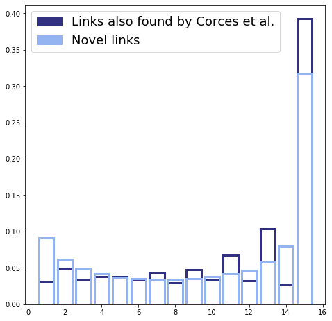

```python
# basal_sampleMetadata = sampleMetadata[sampleMetadata['BRCA_pam50'] == 'Basal']
# basal_sampleList = basal_sampleMetadata['submitter_id'] # 17 samples
# basal_sampleList = list(set(basal_sampleList) & set(dux_p2g.columns)) # 15 samples
# basal_sampleList.extend(['Peak_Name','Linked_Gene'])

# basal_dux_p2g = dux_p2g[basal_sampleList]
# basal_dux_p2g['count'] = basal_dux_p2g.sum(axis=1)
# basal_dux_p2g = basal_dux_p2g[basal_dux_p2g['count'] != 0]
# d(basal_dux_p2g)

# corces_p2gList = corces_p2g.index

novel_basal_dux_p2g = basal_dux_p2g[~basal_dux_p2g.index.isin(corces_p2gList)]
# d(novel_basal_dux_p2g)
corcesOverlap_basal_dux_p2g = basal_dux_p2g[basal_dux_p2g.index.isin(corces_p2gList)]
# d(corcesOverlap_basal_dux_p2g)

X = np.arange(1,16,1)

y1_corces = corcesOverlap_basal_dux_p2g['count'].value_counts(sort = False, normalize = True)
y2_dux = novel_basal_dux_p2g['count'].value_counts(sort = False, normalize = True)

# print(y1_corces)
# print(y2_dux)
fig = plt.figure(figsize = (6, 6))
ax = fig.add_axes([0,0,1,1])

ax.bar(X, y1_corces, edgecolor = "#323181", lw = 3, color="None")#, color = '#323181')#, width = 0.25)
ax.bar(X, y2_dux, edgecolor = '#93b4f0', lw = 3, color = "None")#, width = 0.)

# ax.bar(X, y1_corces, color = '#323181')#, width = 0.25)
# ax.bar(X, y2_dux, color = '#93b4f0')#, width = 0.)
# plt.xlabel('Frequency of peak-gene links in 15 TNBC patients', fontsize = 22)
# plt.ylabel('Density', fontsize = 22)

colors = {'Links also found by Corces et al.':'#323181', 'Novel links':'#93b4f0'}
labels = list(colors.keys())
handles = [plt.Rectangle((0,0),1,1, color=colors[label]) for label in labels]
plt.legend(handles, labels, prop={'size': 18})

plt.show()

# # d(basal_dux_p2g)
# # d(basal_corces_p2g)
```

# 0 - Funseq and CNCDriver on 31 PCAWG samples

OVERALL:

## 0.2 - Finding TCGA/PCAWG TNBC data

```python
## 1a) https://rpubs.com/tiagochst/BCR_Biotab
## In Terminal
## conda install -c conda-forge r-purrrogress

############ In R ######################
###### Downloading stuff ######

# if (!require("BiocManager", quietly = TRUE))
#   install.packages("BiocManager")
## Had to do below b/c one of TCGAbiolinks dependencies (purrrogress) was taken down from CRAN
# remotes::install_github("RDocTaskForce/parsetools")
# remotes::install_github("RDocTaskForce/testextra")
# BiocManager::install("halpo/purrrogress")
# BiocManager::install("TCGAbiolinks")

###### Actual code :) ######
library(TCGAbiolinks)

## Writing the query
query <- GDCquery(project = "TCGA-BRCA",
                  data.category = "Clinical",
                  data.type = "Clinical Supplement",
                  data.format = "BCR Biotab")
## Downloading the query from GDC
GDCdownload(query)
## "GDCprepare" reads the data and makes it into an R object, it gets assigned to a list of tibbles (tibbles = bascially dataframes; so it is a list of dataframes) that has all of the GDC data we just downloaded
clinical.BCRtab.all <- GDCprepare(query)
## this is just printing the name of all 9 of the dataframes
names(clinical.BCRtab.all)
## we want the dataframe/tibble called "clinical_patient_brca" which has the IHC info... note, just gonna save it to a dataframe so that I can work w/ it in python :P
table = clinical.BCRtab.all$clinical_patient_brca
typeof(table) # "list"
write.table(table,file="~/Documents/khuranalab/P5_AOCproject/P5_0.2_clinical_patient_brca.csv")

###### looking at the dataframe :) ######
TCGA_clinicalBrca = pd.read_csv('/Users/annpalladino/Documents/athena/khuranalab/scratch/acp4001/P5_AOCproject/P5_0.2_clinical_patient_brca.csv', sep = ',') # note, the most recently dx'd patient was in 2013; so i feel like there's more up to date ones

TCGA_clinicalBrca_TNBC = TCGA_clinicalBrca[(TCGA_clinicalBrca['er_status_by_ihc'] == 'Negative') & (TCGA_clinicalBrca['pr_status_by_ihc'] == 'Negative') & (TCGA_clinicalBrca['her2_status_by_ihc'] == 'Negative')]

TCGA_clinicalBrca_TNBC_list = TCGA_clinicalBrca_TNBC['bcr_patient_barcode'].to_list() # This column has the "TCGA-A1-A0SK" labels
# print(TCGA_clinicalBrca_TNBC_list)
print(len(TCGA_clinicalBrca_TNBC_list)) # n = 116 patients :)

# d(tcga_BRCA)
d(TCGA_clinicalBrca_TNBC)
```

```
116
```

|  | bcr_patient_uuid | bcr_patient_barcode | form_completion_date | prospective_collection | retrospective_collection | birth_days_to | gender | menopause_status | race | ethnicity | history_other_malignancy | history_neoadjuvant_treatment | tumor_status | vital_status | last_contact_days_to | death_days_to | radiation_treatment_adjuvant | pharmaceutical_tx_adjuvant | histologic_diagnosis_other | initial_pathologic_dx_year | age_at_diagnosis | method_initial_path_dx | method_initial_path_dx_other | surgical_procedure_first | first_surgical_procedure_other | margin_status | surgery_for_positive_margins | surgery_for_positive_margins_other | margin_status_reexcision | … |
| --- | --- | --- | --- | --- | --- | --- | --- | --- | --- | --- | --- | --- | --- | --- | --- | --- | --- | --- | --- | --- | --- | --- | --- | --- | --- | --- | --- | --- | --- | --- |
| 19 | a5b44d66-c162-46b5-9df2-86305f0385c5 | TCGA-A1-A0SK | 2010-12-6 | NO | YES | -20048 | FEMALE | Indeterminate (neither Pre or Postmenopausal) | ASIAN | NOT HISPANIC OR LATINO | No | No | [Not Available] | Dead | [Not Available] | 967 | [Not Available] | [Not Available] | Neuroendocrine carcinoma, large-cell type, hig... | 2007 | 54 | Excisional Biopsy | [Not Applicable] | Lumpectomy | [Not Available] | Positive | Other | surgical resection | Negative | … |
| 23 | a9bb8159-32f0-454c-a946-b3286a52b9d5 | TCGA-A1-A0SP | 2010-12-6 | NO | YES | -14954 | FEMALE | [Not Available] | [Not Available] | NOT HISPANIC OR LATINO | Yes | [Not Available] | TUMOR FREE | Alive | 584 | [Not Applicable] | [Not Available] | [Not Available] | [Not Applicable] | 2007 | 40 | Fine needle aspiration biopsy | [Not Applicable] | Lumpectomy | [Not Available] | Negative | [Not Available] | [Not Applicable] | [Not Available] | … |

```
(116, 112)
```

```python
print(list(nikZainal_TNBC['sample_name'].unique()))
```

## 0.3 Run Funseq & CNCDriver on PCAWG data

### 0.3.1 - Getting sample list

NOTES: I used the TNBC samples from 0.2 block (https://rpubs.com/tiagochst/BCR_Biotab) and overlapped them with the PCAWG samples. All samples used are from BRCA-US project

For the 31 samples cohort (didn't use these 3 b/c of overlap w/ nikZainal, make sure all PCAWG analysis is on 28 samples): I then added 3 extra samples (PD4086, PD4109, PD4248) that were TNBCs according to the paper below (is a Nik-Zainal paper). These samples had 2 DO### numbers on ICGC, one corresponded to the ER+/HER- EU/UK project and one corresponded to the TNBC/lobular BRCA-UK project. I used the one listed in the BRCA-UK project. Authors don't say how they defined TNBCs. Nik-Zainal paper (2012; TNBCs labeled in Fig 4 as well as others): https://ars.els-cdn.com/content/image/1-s2.0-S0092867412005272-mmc2.pdf

```python
path = '/Users/annpalladino/Documents/athena/khuranalab/scratch/acp4001/'
## Get TCGA IHC data
TCGA_clinicalBrca = pd.read_csv(path + 'P5_AOCproject/P5_0.2_clinical_patient_brca.csv', sep = ',') # note, the most recently dx'd patient was in 2013; so i feel like there's more up to date ones
TCGA_clinicalBrca_TNBC = TCGA_clinicalBrca[(TCGA_clinicalBrca['er_status_by_ihc'] == 'Negative') & (TCGA_clinicalBrca['pr_status_by_ihc'] == 'Negative') & (TCGA_clinicalBrca['her2_status_by_ihc'] == 'Negative')]

TCGA_clinicalBrca_TNBC_list = TCGA_clinicalBrca_TNBC['bcr_patient_barcode'].to_list() # This column has the "TCGA-A1-A0SK" labels
# print(TCGA_clinicalBrca_TNBC_list)
print(len(TCGA_clinicalBrca_TNBC_list)) # n = 116 patients :), but not all have WGS/PCAWG data

# d(tcga_BRCA)
########################
# ## 3 samples from NikZainal2012 paper - DON'T USE THESE!! OVERLAP W/ nikZainal COHORT!!!!
# ## Note, samples are such: NikZainal = ['PD4086, PD4109, PD4248'], ICGC = ['DO1008', 'DO1010','DO1017'], submitterID = ['CGP_donor_1187031', 'CGP_donor_1199131', 'CGP_donor_1230778']
# temp_nikZainal_list = ['CGP_donor_1187031', 'CGP_donor_1199131', 'CGP_donor_1230778']
# temp_finalPCAWGsubmitterID_list = TCGA_clinicalBrca_TNBC_list + temp_nikZainal_list
# print(len(temp_finalPCAWGsubmitterID_list))
###################################################

## Get PCAWG BRCA list
## https://www.nature.com/articles/s41586-020-1969-6#Sec23   ---> Download "Supplementary Tables" --> Supplementary table 1 (moved to P5 folder and renamed)
PCAWGsamples = pd.read_excel(path + 'P5_AOCproject/raw_PCAWG_PMID32025007_SupplementaryTable1.xlsx', header = [2])

PCAWGsamples = PCAWGsamples[PCAWGsamples['project_code'].str.contains('BRCA')] #note this contains ~83 TCGA samples + 127 CGP_donor_12123 <- CGP = Comprehensive Genome Profiling, i think this cohort comes from the BRCA-EU project

PCAWG_TNBC = PCAWGsamples[PCAWGsamples['submitted_donor_id'].isin(TCGA_clinicalBrca_TNBC_list)] # note, checked and there are no duplicates

d(TCGA_clinicalBrca_TNBC)
d(PCAWGsamples)
d(PCAWG_TNBC)
```

```
116
```

|  | bcr_patient_uuid | bcr_patient_barcode | form_completion_date | prospective_collection | retrospective_collection | birth_days_to | gender | menopause_status | race | ethnicity | history_other_malignancy | history_neoadjuvant_treatment | tumor_status | vital_status | last_contact_days_to | death_days_to | radiation_treatment_adjuvant | pharmaceutical_tx_adjuvant | histologic_diagnosis_other | initial_pathologic_dx_year | age_at_diagnosis | method_initial_path_dx | method_initial_path_dx_other | surgical_procedure_first | first_surgical_procedure_other | margin_status | surgery_for_positive_margins | surgery_for_positive_margins_other | margin_status_reexcision | … |
| --- | --- | --- | --- | --- | --- | --- | --- | --- | --- | --- | --- | --- | --- | --- | --- | --- | --- | --- | --- | --- | --- | --- | --- | --- | --- | --- | --- | --- | --- | --- |
| 19 | a5b44d66-c162-46b5-9df2-86305f0385c5 | TCGA-A1-A0SK | 2010-12-6 | NO | YES | -20048 | FEMALE | Indeterminate (neither Pre or Postmenopausal) | ASIAN | NOT HISPANIC OR LATINO | No | No | [Not Available] | Dead | [Not Available] | 967 | [Not Available] | [Not Available] | Neuroendocrine carcinoma, large-cell type, hig... | 2007 | 54 | Excisional Biopsy | [Not Applicable] | Lumpectomy | [Not Available] | Positive | Other | surgical resection | Negative | … |
| 23 | a9bb8159-32f0-454c-a946-b3286a52b9d5 | TCGA-A1-A0SP | 2010-12-6 | NO | YES | -14954 | FEMALE | [Not Available] | [Not Available] | NOT HISPANIC OR LATINO | Yes | [Not Available] | TUMOR FREE | Alive | 584 | [Not Applicable] | [Not Available] | [Not Available] | [Not Applicable] | 2007 | 40 | Fine needle aspiration biopsy | [Not Applicable] | Lumpectomy | [Not Available] | Negative | [Not Available] | [Not Applicable] | [Not Available] | … |

```
(116, 112)
```

|  | tumour_specimen_aliquot_id | normal_specimen_aliquot_id | icgc_donor_id | icgc_sample_id | icgc_specimen_id | dcc_specimen_type | project_code | gender | age | organ_system | histology_abbreviation | histology_tier1 | histology_tier2 | histology_tier3 | histology_tier4 | tumour_histological_code | tumour_histological_type | SV.events | ancestry_afr | ancestry_asn | ancestry_amr | ancestry_san | ancestry_eur | ancestry_primary | ancestry_primary_contribution | Coding.SNVs | Non.coding.SNVs | Coding.MNVs | Non.coding.MNVs | … |
| --- | --- | --- | --- | --- | --- | --- | --- | --- | --- | --- | --- | --- | --- | --- | --- | --- | --- | --- | --- | --- | --- | --- | --- | --- | --- | --- | --- | --- | --- | --- |
| 16 | 01658141-8398-4585-9f0f-8355dd9b0604 | 503baeb5-d5d6-46df-8695-c5e0f274c49c | DO3614 | SA17443 | SP7692 | Primary tumour - solid tissue | BRCA-US | female | 62.0 | BREAST | Breast-AdenoCA | ECTODERM | Breast | Adenocarcinoma | Infiltrating duct carcinoma | 8500/3 | Infiltrating duct carcinoma, NOS | 427.0 | 0.000100 | 0.08045 | 0.0001 | 0.033578 | 0.885772 | EUR | 0.885772 | 251 | 21727 | 0 | 41 | … |
| 46 | 0448206f-3ade-4087-b1a9-4fb2d14e1367 | 8fc3cfb0-e245-4089-a73c-8d93cb8fc5ee | DO2341 | SA57479 | SP5052 | Primary tumour - solid tissue | BRCA-US | female | 61.0 | BREAST | Breast-AdenoCA | ECTODERM | Breast | Adenocarcinoma | Infiltrating duct carcinoma | 8500/3 | Infiltrating duct carcinoma, NOS | 1222.0 | 0.615128 | 0.00010 | 0.0001 | 0.000100 | 0.384572 | AFR | 0.615128 | 182 | 18621 | 1 | 122 | … |

```
(211, 61)
```

|  | tumour_specimen_aliquot_id | normal_specimen_aliquot_id | icgc_donor_id | icgc_sample_id | icgc_specimen_id | dcc_specimen_type | project_code | gender | age | organ_system | histology_abbreviation | histology_tier1 | histology_tier2 | histology_tier3 | histology_tier4 | tumour_histological_code | tumour_histological_type | SV.events | ancestry_afr | ancestry_asn | ancestry_amr | ancestry_san | ancestry_eur | ancestry_primary | ancestry_primary_contribution | Coding.SNVs | Non.coding.SNVs | Coding.MNVs | Non.coding.MNVs | … |
| --- | --- | --- | --- | --- | --- | --- | --- | --- | --- | --- | --- | --- | --- | --- | --- | --- | --- | --- | --- | --- | --- | --- | --- | --- | --- | --- | --- | --- | --- | --- |
| 46 | 0448206f-3ade-4087-b1a9-4fb2d14e1367 | 8fc3cfb0-e245-4089-a73c-8d93cb8fc5ee | DO2341 | SA57479 | SP5052 | Primary tumour - solid tissue | BRCA-US | female | 61.0 | BREAST | Breast-AdenoCA | ECTODERM | Breast | Adenocarcinoma | Infiltrating duct carcinoma | 8500/3 | Infiltrating duct carcinoma, NOS | 1222.0 | 0.615128 | 0.000100 | 0.00010 | 0.0001 | 0.384572 | AFR | 0.615128 | 182 | 18621 | 1 | 122 | … |
| 165 | 110b5f05-ded7-45ec-b0f6-a941c92d77dd | f146c30d-fce0-49bc-b684-8ad9ccaca7cf | DO1559 | SA33754 | SP3415 | Primary tumour - solid tissue | BRCA-US | female | 41.0 | BREAST | Breast-AdenoCA | ECTODERM | Breast | Adenocarcinoma | Infiltrating duct carcinoma | 8500/3 | Infiltrating duct carcinoma, NOS | 460.0 | 0.812925 | 0.034654 | 0.08841 | 0.0001 | 0.063911 | AFR | 0.812925 | 105 | 8804 | 0 | 57 | … |

```
(28, 61)
```

```python
# PCAWG_TNBC.to_csv('/Users/annpalladino/Documents/athena/khuranalab/scratch/acp4001/P5_AOCproject/P5_0.3.1_PCAWG_TNBCsamples_metadata.csv', index = None)
```

```python
# PCAWGbrca_samples_dic = {}
# for i in PCAWGsamples.index:
#     key = PCAWGsamples.loc[i,'icgc_donor_id'] # checked, all donor id's are unique
#     values = [PCAWGsamples.loc[i,'submitted_donor_id'], PCAWGsamples.loc[i,'tcga_sample_uuid']]
#     PCAWGbrca_samples_dic[key] = values

# # open file for writing
# f = open("/Users/annpalladino/Documents/athena/khuranalab/scratch/acp4001/P5_AOCproject/P5_0.3.1_SamplesDic_keyICGCdonor_valueSubmitterAndTCGAuuid.txt","w")
# f.write(str(dict))
# f.close()
```

#### 0.3.1.1 - DIDN'T USE; looks at the BRCA-UK TNBC/lobular samples which I didn't use

```python
# ## overlap w/ BRCA-UK cohort which has the subtypes "TNBC/Lobular/Other"
# brcaUK = pd.read_csv('/Users/annpalladino/Downloads/icgc-dataset-1644511647041/sample.tsv', sep = '\t')
# brcaUK_list = list(brcaUK['submitted_donor_id'].unique())
# # print(len(brcaUK_list)) #is 46, ie 1/2 as many b/c 2 entries for each donor, one cancer/one normal
# temp_PCAWG_TNBC = PCAWGsamples[PCAWGsamples['submitted_donor_id'].isin(brcaUK_list)]


# d(brcaUK)
# d(temp_PCAWG_TNBC)

# # sanity check
# temp_PCAWG_forSure_list = list(PCAWG_TNBC['icgc_donor_id'])
# temp_PCAWG_brcaUK_list = list(temp_PCAWG_TNBC['icgc_donor_id'])
# overlap(temp_PCAWG_forSure_list, temp_PCAWG_brcaUK_list)
```

|  | icgc_sample_id | project_code | submitted_sample_id | icgc_specimen_id | submitted_specimen_id | icgc_donor_id | submitted_donor_id | analyzed_sample_interval | percentage_cellularity | level_of_cellularity | study |
| --- | --- | --- | --- | --- | --- | --- | --- | --- | --- | --- | --- |
| 0 | SA6146 | BRCA-UK | PD4085a | SP2150 | CGP_specimen_1215561 | DO1007 | CGP_donor_1187030 | NaN | NaN | NaN | PCAWG |
| 1 | SA6216 | BRCA-UK | PD4085b | SP2168 | CGP_specimen_1215562 | DO1007 | CGP_donor_1187030 | NaN | NaN | NaN | PCAWG |

```
(92, 11)
```

|  | tumour_specimen_aliquot_id | normal_specimen_aliquot_id | icgc_donor_id | icgc_sample_id | icgc_specimen_id | dcc_specimen_type | project_code | gender | age | organ_system | ... | specimen_donor_treatment_type | donor_wgs_included_excluded | specimen_library_strategy | gain_count | loss_count | hd_count | wgd | all.SNVs | all.MNVs | all.Indels |
| --- | --- | --- | --- | --- | --- | --- | --- | --- | --- | --- | --- | --- | --- | --- | --- | --- | --- | --- | --- | --- | --- |
| 94 | 097a7d36-905b-72be-e050-11ac0d482c9a | 097a7d36-9058-72be-e050-11ac0d482c9a | DO1076 | SA6164 | SP2293 | Primary tumour - solid tissue | BRCA-UK | female | NaN | BREAST | ... | NaN | Included | WGS | 1 | 24 | 0 | 0 | 65065 | 95 | 341 |
| 2234 | f221cbb5-eefa-187f-e040-11ac0c481708 | f221cbb5-eef8-187f-e040-11ac0c481708 | DO1020 | SA6760 | SP2357 | Primary tumour - solid tissue | BRCA-UK | female | 33.0 | BREAST | ... | no treatment | Included | WGS | 165 | 230 | 0 | 1 | 10361 | 97 | 528 |

2 rows × 61 columns

```
(44, 61)
```

```
len list1:  28 ; unique:  28
len list2:  44 ; unique:  44
len list1 and list2:  0
```

### 0.3.2 - Formatting Variant Calls BED file

```python
####### FORMATTING ALEX'S PCAWG BRCA VARIANTS; on terminal #########

ssh curie.pbtech
srun -n1 --pty --partition=panda --mem=50G bash -i
cd /athena/khuranalab/scratch/acp4001/P5_AOCproject/1_FunseqInput/PCAWG/TNBC/

python
## 1) filter by TNBCs
import pandas as pd
PCAWG_variants_hg19 = pd.read_csv('/athena/khuranalab/scratch/acp4001/P5_AOCproject/1_FunseqInput/PCAWG/TNBC/raw_alm_Breast-Cancer_PCAWG_SNV_hg19.beb', sep ='\t', header = None)
TNBC_metadata = pd.read_csv('/athena/khuranalab/scratch/acp4001/P5_AOCproject/1_FunseqInput/PCAWG/TNBC/P5_0.3.1_PCAWG_TNBCsamples_metadata.csv')
sampleList = list(TNBC_metadata['tumour_specimen_aliquot_id'])
TNBC_variants_hg19 = PCAWG_variants_hg19[PCAWG_variants_hg19[5].isin(sampleList)]

tempdf = TNBC_metadata[['tumour_specimen_aliquot_id','submitted_donor_id','icgc_donor_id']]
tempdf

TNBC_variants_hg19 = pd.merge(TNBC_variants_hg19, tempdf, how = 'left', left_on=[5], right_on='tumour_specimen_aliquot_id')

TNBC_variants_hg19 = TNBC_variants_hg19[[0,1,2,3,4,'submitted_donor_id']]
TNBC_variants_hg19['submitted_donor_id'] = 'PCAWG_' + TNBC_variants_hg19['submitted_donor_id']

TNBC_variants_hg19.to_csv('/athena/khuranalab/scratch/acp4001/P5_AOCproject/1_FunseqInput/PCAWG/TNBC/TNBC_variantCalls_FunseqFormatted_hg19_28SAMPLES.bed', header = None, index = None, sep = '\t')

# columns = TNBC_variants_hg19.columns
# TNBC_variants_hg19['temp_allColCombined'] = TNBC_variants_hg19[columns].apply(lambda row: ';'.join(row.values.astype(str)), axis=1)

# temp_TNBC_variants = TNBC_variants_hg19[[0,1,2,'temp_allColCombined']]

# temp_TNBC_variants.to_csv('temp_forLiftOver_PCAWG.bed', sep = '\t', header = None, index = None)

# ## also save TNBC_variants_hg19 in a Funseq Formatted way just in case I want to run Funseq/CNCDriver in hg19 instead :)
# temp_df = TNBC_variants_hg19[[0,1,2,3,4,'submitted_donor_id']]

# temp_df.to_csv('/athena/khuranalab/scratch/acp4001/P5_AOCproject/1_FunseqInput/PCAWG/TNBC/TNBC_variantCalls_FunseqFormatted_hg19_31SAMPLES.bed', header = None, index = None, sep = '\t')

# sampleList28 = ['TCGA-EW-A3U0', 'TCGA-AO-A0J4', 'TCGA-AR-A1AY', 'TCGA-AN-A04D', 'TCGA-A7-A26G', 'TCGA-BH-A0B3', 'TCGA-AQ-A04J', 'TCGA-E2-A1LL', 'TCGA-GI-A2C9', 'TCGA-D8-A27H', 'TCGA-A8-A09X', 'TCGA-A2-A0D0', 'TCGA-AN-A0G0', 'TCGA-E2-A14X', 'TCGA-GM-A2DF', 'TCGA-BH-A1FC', 'TCGA-AC-A2BK', 'TCGA-AO-A124', 'TCGA-EW-A1PB', 'TCGA-A2-A3XX', 'TCGA-EW-A1PH', 'TCGA-EW-A1P8', 'TCGA-BH-A0E0', 'TCGA-AR-A256', 'TCGA-BH-A0WA', 'TCGA-AO-A0J6', 'TCGA-AN-A0AT', 'TCGA-D8-A27F']

# temp_df = temp_df[temp_df['submitted_donor_id'].isin(sampleList28)]
# temp_df.to_csv('/athena/khuranalab/scratch/acp4001/P5_AOCproject/1_FunseqInput/PCAWG/TNBC/TNBC_variantCalls_FunseqFormatted_hg19_28SAMPLES.bed', header = None, index = None, sep = '\t')

# ##### on computer #####
# liftOver /Users/annpalladino/Downloads/temp_forLiftOver_PCAWG.bed /Users/annpalladino/Documents/khuranalab/00_raw_files/ucsc_hg19ToHg38.over.chain /Users/annpalladino/Downloads/temp_PCAWG_hg38.bed /Users/annpalladino/Downloads/unMapped_PCAWG

# sed 's:;:     :g' temp_PCAWG_hg38.bed > temp_PCAWG_hg38_formatted.bed  # HAVE TO RETYPE EVERYTIME!!!! DON'T JUST COPY AND PASTE!!
# # replace the ; with Tabs :).... press Control+V and then the tab char to "escape" the tab, ie: sed 's:/:<Control+V><TAB character>:g'

# ## move temp_PCAWG_hg38_formatted.bed back to folder via CyberDuck
# #######################

# ## back on terminal
# PCAWG_variants_hg38 = pd.read_csv('/athena/khuranalab/scratch/acp4001/P5_AOCproject/1_FunseqInput/PCAWG/TNBC/temp_PCAWG_hg38_formatted.bed', sep = '\t', header = None) # columns variable is from before, doesn't match up for the first 2 columns but will fix in a bit :)

# columns = ['CHROM','START','END','Chrom_hg19','Start_hg19','End_hg19', 'Ref','Alt','tumour_specimen_aliquot_id','submitted_donor_id','icgc_donor_id']

# PCAWG_variants_hg38.set_axis(columns, axis = 1, inplace = True)

# columns = ['CHROM','START','END','Ref','Alt','submitted_donor_id','Chrom_hg19','Start_hg19','End_hg19','tumour_specimen_aliquot_id','icgc_donor_id']

# PCAWG_variants_hg38 = PCAWG_variants_hg38[columns]

# PCAWG_variants_hg38.to_csv('/athena/khuranalab/scratch/acp4001/P5_AOCproject/1_FunseqInput/PCAWG/TNBC/P5_0.3.2_TNBCvariantCalls_hg38_31SAMPLES.csv')

# temp_df = PCAWG_variants_hg38[['CHROM','START','END','Ref','Alt','submitted_donor_id']]
# temp_df.to_csv('/athena/khuranalab/scratch/acp4001/P5_AOCproject/1_FunseqInput/PCAWG/TNBC/TNBC_variantCalls_FunseqFormatted_hg38_31SAMPLES.bed', header = None, index = None, sep = '\t')

# temp_df = temp_df[temp_df['submitted_donor_id'].isin(sampleList28)]
# temp_df = PCAWG_variants_hg38[['CHROM','START','END','Ref','Alt','submitted_donor_id']]
# temp_df.to_csv('/athena/khuranalab/scratch/acp4001/P5_AOCproject/1_FunseqInput/PCAWG/TNBC/TNBC_variantCalls_FunseqFormatted_hg38_28SAMPLES.bed', header = None, index = None, sep = '\t')
```

### 0.3.3 - Installing FunSeq2 Dependencies, in Cluster

```python
##################################
######### set up ##################
## get dependencies IN AN ENVIRONMENT!!
conda create --name openssl1.0.0_env # environment location: /home/acp4001/anaconda3/envs/openssl1.0.0_env
conda activate openssl1.0.0_env
conda install -c bioconda bedtools tabix ucsc-bigwigaverageoverbed perl-parallel-forkmanager openssl=1.0

## in acp4001@pascal ~ ; NOTE, STILL ACCESSIBLE EVEN WHEN NOT IN ENV
mkdir ReferenceFiles/VAT
vim .bash_profile
## in vim, add /home/acp4001/ReferenceFiles/VAT to $PATH
## esc :wq
## restart cluster or i think u can run: source ~/.bash_profile
echo $PATH # <- just to check :)
cd ReferenceFiles/VAT

##################################
######### Get gsl 1.14 #########
wget https://ftp.gnu.org/gnu/gsl/gsl-1.14.tar.gz
tar -zxvf gsl-1.4.tar.gz # z means (un)z̲ip.; x means ex̲tract files from the archive.; v means print the filenames v̲erbosely.; f means the following argument is a f̱ilename.

# conda install -c conda-forge gettext # dependency i think? idk if necessary tho, and somewhere during this my conda crashed so only do if necessary!!!

# conda install -c conda-forge openlibm # is another dependency??; idk if necessary tho, and somewhere during this my conda crashed so only do if necessary!!!

./configure --prefix=/home/acp4001/ReferenceFiles/VAT/gsl-1.4
make
make install
##################################
######### get gd-2.0.35 #########
## install dependencies - idk if necessary tho, and somewhere DURING THIS MY CONDA CRASHED so only do if necessary!!!
# cd /home/acp4001/ReferenceFiles/VAT
# wget http://www.ijg.org/files/jpegsrc.v9e.tar.gz
# tar -zxvf jpegsrc.v9e.tar.gz
# cd jpeg-9e/
# ./config --prefix=/home/acp4001/ReferenceFiles/VAT/jpeg-9e/

## downloaded manually onto my computer from here: https://sourceforge.net/projects/gd2/
## used cyberduck to transfer it onto cluster into ~/References/VAT folder
./configure --prefix=/home/acp4001/ReferenceFiles/VAT/gd-2.0.35
make
make install

##################################
######### get libbios #########

wget http://homes.gersteinlab.org/people/lh372/VAT/libbios-1.0.0.tar.gz
tar -zxvf libbios-1.0.0.tar.gz

export CPPFLAGS="-I/home/acp4001/ReferenceFiles/VAT/gsl-1.4/include -I/home/acp4001/ReferenceFiles/VAT/libbios-1.0.0/include -I/home/acp4001/ReferenceFiles/VAT/gd-2.0.35/include"

export LDFLAGS="-L/home/acp4001/ReferenceFiles/VAT/gsl-1.4/lib -L/home/acp4001/ReferenceFiles/VAT/libbios-1.0.0/lib -L/home/acp4001/ReferenceFiles/VAT/gd-2.0.35/lib"

export LD_LIBRARY_PATH=home/acp4001/ReferenceFiles/VAT/gsl-1.4/lib:/home/acp4001/ReferenceFiles/VAT/libbios-1.0.0/lib:/home/acp4001/ReferenceFiles/VAT/gd-2.0.35/lib

cd libbios-1.0.0
./configure --prefix=/home/acp4001/ReferenceFiles/VAT/libbios-1.0.0
make
make install
##################################
######### get VAT #################
#### DIDN"T WORK :( :( ############

# conda install -c bioconda perl-gd

wget http://homes.gersteinlab.org/people/lh372/VAT/vat-1.0.0.tar.gz
tar -zxvf vat-1.0.0.tar.gz
cd vat-1.0.0
./configure --prefix=/home/acp4001/ReferenceFiles/VAT/vat-1.0.0
make
make install
################################
######### get TFM-Pvalue ########

wget http://genomedata.org/seq-tec-workshop/funseq/TFM-Pvalue.tar.gz
tar -xvzf TFM-Pvalue.tar.gz
cd TFM-Pvalue/
wget http://genomedata.org/seq-tec-workshop/funseq/Makefile -O Makefile
wget http://genomedata.org/seq-tec-workshop/funseq/TFMpvalue.cpp -O TFMpvalue.cpp
# in btwn this step and "make" I had to edit the makeFile to only say g++ instead of g++-4.3 which i think is the version they wanted to use but i don't have.... idk, can try doing w/o this step
make # don't have to do config or make install steps
# can test the software by running 'make testpv2sc', 'make testsc2pv' and 'make testdistrib'. These commmands respectively compute the score associated to a P-value of 1e-5, the P-value associated to a score of 8.77 and the score distribution between 8 and 9 for the MA0045.pfm matrix file.... see ReadMe.txt for more info


export PATH="/home/acp4001/ReferenceFiles/VAT/gsl-1.4:$PATH"

./configure --prefix=/home/acp4001/ReferenceFiles/VAT/vat-1.0.0
```

### 0.3.4 - Running FunSeq2 on PCAWG samples + Analysis

#### 0.3.4.1 - EXPLANATION FOR FUNSEQ2 INPUT and OUTPUT (text only)

INPUT (there are more in actual documentation)

###### #

OUTPUT

- gerp = gerp score (i.e. 5.69) = evolutionary conservation score; high score = highly conserved
- cds = coding sequence (yes/no) = should all be no for enhancers
- variant.annotation.cds = gerp;cds;variant.annotation.cds;network.hub;gene.under.negative.selection; ENCODE.annotated;hot.region;motif.analysis;sensitive;ultra.sensitive;ultra.conserved;target.gene[known_cancer_gene/ TF_regulating_known_cancer_gene,differential_expressed_in_cancer,actionable_gene];coding.score;noncoding.score; recurrence.within.samples;recurrence.database

#### 0.3.4.2 - BASH CODE for running FunSeq on TNBC samples; Contexts = Nawaf, BRCA (andre), and TNBC (andre)

```python
####### ONLY DO THIS WHOLE BLOCK ONCE #######
## 1) copy NAWAF data context and code  over
cp -R /athena/khuranalab/scratch/naa4013/funseq_hg38_data_context/ /athena/khuranalab/scratch/acp4001 # copy Nawaf data context over;; note, will get some errors b/c can't unzip .gz files but thats fine, it'll still copy the .gz files over which is all that's needed
cp -R /athena/khuranalab/scratch/naa4013/funseq2_recent /athena/khuranalab/scratch/acp4001/ # copy code over

########################################################

## 1a) copy BRCA data context files over
# sensitive regions
cp /home/anf2034/sensitive_BRCA_hg38.bed /athena/khuranalab/scratch/acp4001/funseq_hg38_data_context
# regulatory network
cp /home/anf2034/BRCA.regulatory.network /athena/khuranalab/scratch/acp4001/funseq_hg38_data_context
# peak-gene networks
cp /home/anf2034/BRCA_sample_drm.gene_hg38.bed /athena/khuranalab/scratch/acp4001/funseq_hg38_data_context
# Network
cp /athena/khuranalab/scratch/anf2034/FunSeq2/data_context/networks/REG.degree /athena/khuranalab/scratch/acp4001/funseq_hg38_data_context # reg.degree file; NOTE, don't move directly to networks file b/c will replace original REG.degree file. instead, copy to my directory, rename (see below) and then move to the networks directory; just need to do for this file b/c Andre named it REG.degree... the rest he named more specifically (ie tnbc_Reg.degree)
mv /athena/khuranalab/scratch/acp4001/funseq_hg38_data_context/REG.degree /athena/khuranalab/scratch/acp4001/funseq_hg38_data_context/BRCA_REG.degree # Rename file
mv BRCA_REG.degree networks/ # move to networks directory

##############################################################

## 1b) copy TNBC data context files over
# sensitive regions
cp /home/anf2034/sensitive_TNBC_hg38.bed /athena/khuranalab/scratch/acp4001/funseq_hg38_data_context
# regulatory network
cp /home/anf2034/TNBC.regulatory.network /athena/khuranalab/scratch/acp4001/funseq_hg38_data_context
# peak-gene networks
cp /home/anf2034/TNBC_sample_drm.gene_hg38.bed /athena/khuranalab/scratch/acp4001/funseq_hg38_data_context
# Network
cp /athena/khuranalab/scratch/anf2034/FunSeq2/data_context/networks/TNBC_REG.degree /athena/khuranalab/scratch/acp4001/funseq_hg38_data_context/networks
```

```python
####### EDIT EVERYTIME!!!!!!!! ################
## 2) change config.txt in /athena/khuranalab/scratch/acp4001/funseq2_recent
vim /athena/khuranalab/scratch/acp4001/funseq2_recent/config.txt

## 3) Make output directory & BASH code
cd /athena/khuranalab/scratch/acp4001/P5_AOCproject
# make output directory; CHANGE EACH TIME!!!!
mkdir 2_FunseqOutput/$cohort
mkdir 2_FunseqOutput/$cohort/$cancer$contextContext

# make Bash code; CHANGE EACH TIME!!!!
cp /athena/khuranalab/scratch/acp4001/P5_AOCproject/code_funseqTemplate.sh /athena/khuranalab/scratch/acp4001/P5_AOCproject/1_FunseqInput/$cohort/$cancer/code_funseq_$cancer$contextContext.sh

vim /athena/khuranalab/scratch/acp4001/P5_AOCproject/1_FunseqInput/$cohort/code_funseq_$cancer$contextContext.sh

# 4) Run using following code
ssh curie.pbtech
cd /athena/khuranalab/scratch/acp4001
sbatch /athena/khuranalab/scratch/acp4001/P5_AOCproject/1_FunseqInput/$cohort/$cancer/code_funseq_$cancer$contextContext.sh
```

```python
# # ########### BASH CODES USED ABOVE!! #####################

# #! /bin/bash -l

# #SBATCH -p panda   # cluster-specific
# #SBATCH --nodes=1
# #SBATCH --ntasks=1
# #SBATCH --mem=50G   # memory requested, units available: K,M,G,T
# #SBATCH --job-name="FunSeq2"
# #SBATCH --output=slurm-%x-%j.out
# #SBATCH --mail-user=acp4001@med.cornell.edu
# #SBATCH --mail-type=END

# source ~/.bashrc

# conda activate openssl1.0.0_env

# PATH=$PATH:/home/acp4001/ReferenceFiles/VAT/TFM-Pvalue

# cd $TMPDIR

# rsync -av /athena/khuranalab/scratch/acp4001/funseq2_recent $TMPDIR

# cd funseq2_recent/

# bash funseq2.sh -f /athena/khuranalab/scratch/acp4001/P5_AOCproject/1_FunseqInput/$cohort/$cancerVariantCalls_FunseqFormatted_hg38.sh -inf BED -nc -p 2 -o /athena/khuranalab/scratch/acp4001/P5_AOCproject/2_FunseqOutput/$cohort/$cancer$contextContext

# # ####### Don't include this in code :) ##########
# # # -f = input file
# # # -inf = input file type (ie BED vs vcf)
# # # -nc = noncoding
# # # -p 2 = run two genomes in parallel
# # # -o = output directory CHANGE THIS EACH TIME!!!!!!!!
# # ### P5_0.3_PCAWG_CNCDriver/FunseqOutput_tnbcNawafcontext
# # ### P5_0.3_PCAWG_CNCDriver/FunseqOutput_tnbcBRCAcontext
# # ### P5_0.3_PCAWG_CNCDriver/FunseqOutput_tnbcTNBCcontext
```

```python
# 5) Do formatting of vcf files into .txt files w/ Nawaf's code on cluster
## Code from Nawaf; DO ON CLUSTER
ssh curie.pbtech

cd /athena/khuranalab/scratch/acp4001/CNCDriver_data_hg38

############################################
####extract.py AND runextractVCF.sh #########
vim extractVCF.py #(full code is copied under FILES; note, made some changes to Nawaf's file; ie commented out lines meant to process multiple files)
1) dir_out = '/athena/khuranalab/scratch/acp4001/P5_AOCproject/2_FunseqOutput/$cohort/$cancer$contextContext' # CHANGE
2) eachSamplestrip='$cancer$contextContext' # CHANGE
:wq

vim run_extractVCF.sh
1) for fullfile in /athena/khuranalab/scratch/acp4001/P5_AOCproject/2_FunseqOutput/$cohort/$cancer$context/*.vcf # CHANGE!!
:wq

sbatch run_extractVCF.sh
## Note, this outputs 2 .txt files, CDS and NCDS; use these in 0.3.4.3 - Output Analaysis
###########################################
### readLoadRds.R AND run_readLoadRd.sh ####
cp readLoadRds.R temp_readLoadRds.R
vim temp_readLoadRds.R
# THERE ARE 3 **** places to change
:wq

sbatch run_readLoadRd.sh
## this makes the final .Rd file to put into CNCDriver
```

#### 0.3.4.3 - Making OutputFormatted.csv (ie merged w/ input VCF and has DUX predicted genes)

```python
########### Output Analysis ##############

# Input VCF file
FSinput = pd.read_csv(path + 'P5_AOCproject/P5_0.3_PCAWG_CNCDriver/P5_0.3.2_TNBCvariantCalls_hg38.csv')

FSinput['variantSampleID'] = FSinput['CHROM'] + ':' + FSinput['END'].astype(str) + ':' +  FSinput['ALT'] + ':' +  FSinput['tcga_sample_uuid']
print('######## FunSeq Input DF ######')
d(FSinput)

##########################################

# peak2gene links
p2gMatrix = pd.read_csv(path + 'P5_AOCproject/raw_dux_EX_0177_peak2gene_cutoff0.csv', index_col = [0])
print('######## p2g Matrix ########')
d(p2gMatrix)

##########################################
########## CHANGE THIS!!!! ################
FSoutput_vcf = pd.read_csv('/Users/annpalladino/Documents/khuranalab/P5_AOCproject/P5_0.3_PCAWG_CNCDriver/FunseqOutput_tnbcTNBCContext/CNCDriverInput/tnbcTNBCContext_NCDS.txt', sep = '\t') # CHANGE THIS!!! edit at 2 places

FSoutput_vcf['variantSampleID'] = FSoutput_vcf['chr'] + ':' + FSoutput_vcf['posStart'].astype(str) + ':' +  FSoutput_vcf['alt'] + ':' +  FSoutput_vcf['sampleID']

d(FSoutput_vcf)
# columns = list(FSoutput_vcf.columns) # make a list of columns to use for FSoutput_candidates dataframe
```

```
######## FunSeq Input DF ######
```

|  | CHROM | START | END | REF | ALT | tcga_sample_uuid | CANCER_TYPE | submitted_donor_id | icgc_donor_id | enhancerChr | enhancerStart | enhancerEnd | enhancer | enhancerStatus | variantSampleID |
| --- | --- | --- | --- | --- | --- | --- | --- | --- | --- | --- | --- | --- | --- | --- | --- |
| 0 | chr1 | 1158243 | 1158244 | G | C | 0448206f-3ade-4087-b1a9-4fb2d14e1367 | Breast-AdenoCa | TCGA-EW-A3U0 | DO2341 | chr1 | 1158088 | 1158588 | CHOL_76 | linked | chr1:1158244:C:0448206f-3ade-4087-b1a9-4fb2d14... |
| 1 | chr1 | 2323645 | 2323646 | G | A | 0448206f-3ade-4087-b1a9-4fb2d14e1367 | Breast-AdenoCa | TCGA-EW-A3U0 | DO2341 | chr1 | 2323397 | 2323897 | ESCA_716 | open | chr1:2323646:A:0448206f-3ade-4087-b1a9-4fb2d14... |

```
(19742, 15)
```

```
######## p2g Matrix ########
```

|  | TCGA-MP-A4TF | TCGA-MP-A4TE | TCGA-A7-A0CH | TCGA-CU-A3YL | TCGA-IC-A6RE | TCGA-BH-A0DV | TCGA-BH-A0DP | TCGA-Q2-A5QZ | TCGA-IG-A4P3 | TCGA-H4-A2HO | TCGA-85-A4QR | TCGA-VQ-A94O | TCGA-GK-A6C7 | TCGA-B2-A4SR | TCGA-EB-A24C | TCGA-M9-A5M8 | TCGA-BA-A8YP | TCGA-L9-A8F4 | TCGA-AO-A03N | TCGA-MP-A4T7 | TCGA-MP-A4T4 | TCGA-DK-A1AD | TCGA-GL-A9DC | TCGA-CD-A486 | TCGA-85-A512 | TCGA-IG-A3YA | TCGA-LN-A9FQ | TCGA-A2-A0EX | TCGA-A2-A0EY | … |
| --- | --- | --- | --- | --- | --- | --- | --- | --- | --- | --- | --- | --- | --- | --- | --- | --- | --- | --- | --- | --- | --- | --- | --- | --- | --- | --- | --- | --- | --- | --- |
| KTN1-THCA_66795 | 0 | 0 | 0 | 0 | 0 | 0 | 0 | 0 | 0 | 0 | 0 | 0 | 0 | 0 | 0 | 0 | 0 | 0 | 0 | 0 | 0 | 0 | 0 | 0 | 0 | 0 | 0 | 0 | 0 | … |
| ZNF703-ACC_40338 | 1 | 1 | 1 | 1 | 1 | 1 | 1 | 1 | 1 | 1 | 1 | 1 | 1 | 1 | 1 | 1 | 1 | 1 | 1 | 1 | 1 | 1 | 1 | 1 | 1 | 1 | 1 | 1 | 1 | … |

```
(61502, 371)
```

|  | chr | posStart | posEnd | ref | alt | sampleID | CDS | VA | HUB | GNEG | GERP | UCONS | HOT | SEN | USEN | GENE | CDSS | NCDS | NCENC | MOTIFBR | MOTIFG | RECUR | DBRECUR | tumorType | variantSampleID |
| --- | --- | --- | --- | --- | --- | --- | --- | --- | --- | --- | --- | --- | --- | --- | --- | --- | --- | --- | --- | --- | --- | --- | --- | --- | --- |
| 0 | chr3 | 190566628 | 190566628 | G | T | 0448206f-3ade-4087-b1a9-4fb2d14e1367 | No | NaN | IL1RAP:BRCA_REG(0.727)PPI(0.695)REG(0.409)TNBC... | NaN | 3.72 | NaN | Helas3,Hepg2 | Yes | NaN | IL1RAP(Distal&Intron) | NaN | 3.37202330675671 | DHS(MCV-12\|chr3:190566555-190566705),DHS(MCV-1... | NaN | FOXD1_2#190566626#190566634#+#2#9.483#5.088,FO... | No | No | BRCA | chr3:190566628:T:0448206f-3ade-4087-b1a9-4fb2d... |
| 1 | chr2 | 85772641 | 85772641 | A | C | 0448206f-3ade-4087-b1a9-4fb2d14e1367 | No | NaN | ATOH8:BRCA_REG(0.983)PPI(0.236)REG(0.409)TNBC_... | NaN | 2.02 | NaN | H1hesc,Helas3,Hepg2 | Yes | NaN | ATOH8(Distal&Intron) | NaN | 3.37133043405877 | DHS(MCV-12\|chr2:85772440-85772660),DHS(MCV-13\|... | NaN | RUNX1_7#85772638#85772644#-#4#7.983#3.589,RUNX... | No | No | BRCA | chr2:85772641:C:0448206f-3ade-4087-b1a9-4fb2d1... |

```
(19187, 25)
```

```python
###### QUICK SANITY CHECKS/ANALYSIS :) ############
## Column names :) ['SAMPLE','GERP','CDS','VA','HUB','GNEG','NCENC','MOTIFBR','MOTIFG','SEN','USEN', 'UCONS','GENE','CANG','CDSS','NCDS', 'RECUR','DBRECUR', 'variantSampleID'] <- I added the last one :)

## SAMPLE: Make sure that all the samples were run
temp_FS_input_list = list(FSinput['tcga_sample_uuid'])
temp_FS_output_list = list(FSoutput_vcf['sampleID'])
print('OVERLAP OF SAMPLES')
overlap(temp_FS_input_list,temp_FS_output_list)
print(100*'*')

## CDS: Check that all CDS = no (i.e. b/c cds = coding sequence, so they should all be "no")
print(FSoutput_vcf['CDS'].value_counts())
print(100*'*')

## GENE: will do later

# ## NCDS: Make hist of NCDS = noncoding score;; don't run unless Dr. Khurana wants it, was pretty ugly histogram :P
# ## for some reason, there are some rows (2,463) that have "2.38:3.389" so can't be converted b/c of the colon, will fix that
# tempdf = FSoutput_vcf[['variantSampleID','NCDS']]
# tempdf['NCDS1'] = tempdf['NCDS'].str.split(':',1)

# n = 0
# for i in tempdf.index:
#     if len(tempdf.loc[i,'NCDS1']) > 1:
#         n += 1
#         tempdf.loc[i,'NCDS'] = tempdf.loc[i,'NCDS1'][1]
# #         print(tempdf.loc[i,'NCDS1'])
# # tempdf['NCDS1'] = tempdf['NCDS1'][0]
# # print(type(tempdf.loc[2,'NCDS1']))
# print(n)
# tempdf['NCDS'] = tempdf['NCDS'].astype(float)
# d(tempdf)

# fig, ax = plt.subplots()
# plt.hist(tempdf['NCDS'], bins = 15)

## variantSampleID: see if variantSampleIDs are unique and if they overlap w/ original input file
temp_FSinput_list = list(FSinput['variantSampleID'])
temp_FSoutput_list = list(FSoutput_vcf['variantSampleID'])
print('OVERLAP OF variantSampleID')
overlap(temp_FSinput_list,temp_FSoutput_list)
```

```
OVERLAP OF SAMPLES
len list1:  19742 ; unique:  28
len list2:  19187 ; unique:  28
len list1 U list2 (no repeats!):  28
len list1 ∩ list2 :  28
No    19187
Name: CDS, dtype: int64
OVERLAP OF variantSampleID
len list1:  19742 ; unique:  19742
len list2:  19187 ; unique:  19187
len list1 U list2 (no repeats!):  19742
len list1 ∩ list2 :  19187
```

```python
#####################################################################################
# # DON"T NEED TO RUN AGAIN; format p2gMatrix really quickly AND making a 'peak': ['gene'] dictionary
# p2gMatrix['gene'], p2gMatrix['peak'] = p2gMatrix.index.str.rsplit('-',1).str
# p2gDic = p2gMatrix.groupby('peak')['gene'].apply(list).to_dict()
# ## write dictionary to file
# import json
# # with open('00_raw_files/P5_acp_p2gDic_fromEX0177_peak2gene_cutoff0.txt', 'w') as convert_file:
# #     convert_file.write(json.dumps(p2gDic))
# # # print(p2gDic)
# #######################################################################################
# ## read in a file
temp_p2gDic = (open('/Users/annpalladino/Documents/khuranalab/00_raw_files/P5_acp_p2gDic_fromEX0177_peak2gene_cutoff0.txt','r')).read() # imports as a string
p2gDic = ast.literal_eval(temp_p2gDic) # ast package converts it to dic
print(type(p2gDic))

############## For VCF total output file ###############
## overlap the dataframes so that I can do more analysis
FSoutput_vcf_formatted = pd.merge(FSinput, FSoutput_vcf, how = 'right', on = 'variantSampleID')
FSoutput_vcf_formatted.drop(columns = ['chr', 'posStart', 'posEnd', 'ref', 'alt', 'sampleID'], inplace = True)
d(FSoutput_vcf_formatted)
```

```
<class 'dict'>
```

|  | CHROM | START | END | REF | ALT | tcga_sample_uuid | CANCER_TYPE | submitted_donor_id | icgc_donor_id | enhancerChr | enhancerStart | enhancerEnd | enhancer | enhancerStatus | variantSampleID | CDS | VA | HUB | GNEG | GERP | UCONS | HOT | SEN | USEN | GENE | CDSS | NCDS | NCENC | MOTIFBR | … |
| --- | --- | --- | --- | --- | --- | --- | --- | --- | --- | --- | --- | --- | --- | --- | --- | --- | --- | --- | --- | --- | --- | --- | --- | --- | --- | --- | --- | --- | --- | --- |
| 0 | chr1 | 1158243 | 1158244 | G | C | 0448206f-3ade-4087-b1a9-4fb2d14e1367 | Breast-AdenoCa | TCGA-EW-A3U0 | DO2341 | chr1 | 1158088 | 1158588 | CHOL_76 | linked | chr1:1158244:C:0448206f-3ade-4087-b1a9-4fb2d14... | No | NaN | C1orf159:BRCA_REG(0.857)TNBC_REG(0.870),LINC01... | NaN | . | NaN | NaN | Yes | NaN | C1orf159(Distal),LINC01342(Distal),MIR200A(Dis... | NaN | 0.96910593 | DHS(MCV-12\|chr1:1158195-1158345),DHS(MCV-18\|ch... | NaN | … |
| 1 | chr1 | 2323645 | 2323646 | G | A | 0448206f-3ade-4087-b1a9-4fb2d14e1367 | Breast-AdenoCa | TCGA-EW-A3U0 | DO2341 | chr1 | 2323397 | 2323897 | ESCA_716 | open | chr1:2323646:A:0448206f-3ade-4087-b1a9-4fb2d14... | No | NaN | MORN1:BRCA_REG(0.144)PHOS(0.540)REG(0.409)TNBC... | NaN | -2.37 | NaN | NaN | Yes | NaN | MORN1(Intron) | NaN | 0.96910593:1.96910593 | TFP(ZNF263\|chr1:2323572-2323992) | NaN | … |

```
(19187, 33)
```

```python
## add duxPredictedGenes column to dataframe; based off of p2gDic
FSoutput_vcf_formatted['duxPredictedGenes'] = FSoutput_vcf_formatted['enhancer'].map(p2gDic)
# d(FSoutput_vcf_formatted) # note, there are a bunch of NaN for duxPredictedGenes b/c not all the peaks had links to genes

## Yay :) worked; did in a tempdf so i didn't mess up original FSoutput_vcf_formatted...
tempdf = FSoutput_vcf_formatted[['variantSampleID','GENE']]
tempdf.set_index('variantSampleID', inplace = True)
tempdf = tempdf.dropna() #20,381 -> 13,231
tempdf['GENElist'] = tempdf['GENE'].str.split(',')
tempdf['FunseqGeneList'] = ''

for i in tempdf.index:
    tempList = tempdf.loc[i,'GENElist']
    tempList_formatted = [(re.sub(r"\([^()]*\)", "", x)) for x in tempList]
    tempdf.loc[i,'FunseqGeneList'] = tempList_formatted

# d(tempdf)
# now merge tempdf back w/ FSoutput_vcf_formatted
tempdf = tempdf[['FunseqGeneList']]
# d(tempdf)
FSoutput_vcf_formatted = pd.merge(FSoutput_vcf_formatted,tempdf, how='left', left_on='variantSampleID', right_index=True)
d(FSoutput_vcf_formatted)
```

|  | CHROM | START | END | REF | ALT | tcga_sample_uuid | CANCER_TYPE | submitted_donor_id | icgc_donor_id | enhancerChr | enhancerStart | enhancerEnd | enhancer | enhancerStatus | variantSampleID | CDS | VA | HUB | GNEG | GERP | UCONS | HOT | SEN | USEN | GENE | CDSS | NCDS | NCENC | MOTIFBR | … |
| --- | --- | --- | --- | --- | --- | --- | --- | --- | --- | --- | --- | --- | --- | --- | --- | --- | --- | --- | --- | --- | --- | --- | --- | --- | --- | --- | --- | --- | --- | --- |
| 0 | chr1 | 1158243 | 1158244 | G | C | 0448206f-3ade-4087-b1a9-4fb2d14e1367 | Breast-AdenoCa | TCGA-EW-A3U0 | DO2341 | chr1 | 1158088 | 1158588 | CHOL_76 | linked | chr1:1158244:C:0448206f-3ade-4087-b1a9-4fb2d14... | No | NaN | C1orf159:BRCA_REG(0.857)TNBC_REG(0.870),LINC01... | NaN | . | NaN | NaN | Yes | NaN | C1orf159(Distal),LINC01342(Distal),MIR200A(Dis... | NaN | 0.96910593 | DHS(MCV-12\|chr1:1158195-1158345),DHS(MCV-18\|ch... | NaN | … |
| 1 | chr1 | 2323645 | 2323646 | G | A | 0448206f-3ade-4087-b1a9-4fb2d14e1367 | Breast-AdenoCa | TCGA-EW-A3U0 | DO2341 | chr1 | 2323397 | 2323897 | ESCA_716 | open | chr1:2323646:A:0448206f-3ade-4087-b1a9-4fb2d14... | No | NaN | MORN1:BRCA_REG(0.144)PHOS(0.540)REG(0.409)TNBC... | NaN | -2.37 | NaN | NaN | Yes | NaN | MORN1(Intron) | NaN | 0.96910593:1.96910593 | TFP(ZNF263\|chr1:2323572-2323992) | NaN | … |

```
(19187, 35)
```

```python
FSoutput_vcf_formatted.to_csv('/Users/annpalladino/Documents/khuranalab/P5_AOCproject/P5_0.3_PCAWG_CNCDriver/FunseqOutput_tnbcTNBCContext/P5_0.3.4.3_tnbcTNBCContext_OutputFormatted.csv', index = None) # CHANGE!!!!
```

#### 0.3.4.4 - FunSeq Output Analysis - On Cluster

FILES BEING COMPARED:

- funseq input = FSinput
- funseq interactive tnbcTNBCContext (noncoding) = FSoutput
- funseq interactive tnbcTNBCContext (coding) = FSoutput_CDS; # don't need to do for future runs, just a comparison :)
- funseq interactive tnbcBRCAContext (noncoding) = FSoutput_BRCA # don't need to do for future runs, just a comparison :)

```python
###### ON CLUSTER ############
ssh curie.pbtech
srun -n1 --pty --partition=panda --mem=30G bash -i

python
import pandas as pd
import numpy as np

FSinput = pd.read_csv('/athena/khuranalab/scratch/acp4001/P5_AOCproject/1_FunseqInput/PCAWG/tnbc/P5_0.3.2_TNBCvariantCalls_hg38.csv')
FSinput['variantSampleID'] = FSinput['CHROM'] + ':' + FSinput['END'].astype(str) + ':' +  FSinput['ALT'] + ':' +  FSinput['tumour_specimen_aliquot_id']

FSoutput = pd.read_csv('/athena/khuranalab/scratch/acp4001/P5_AOCproject/bash/2_FunseqOutput/PCAWG/tnbcTNBCContext/tnbcTNBCContext_NCDS.txt', sep = '\t')
FSoutput['variantSampleID'] = FSoutput['chr'] + ':' + FSoutput['posEnd'].astype(str) + ':' + FSoutput['alt'] + ':' + FSoutput['sampleID']

FSoutput_interactive = pd.read_csv('/athena/khuranalab/scratch/acp4001/P5_AOCproject/2_FunseqOutput/PCAWG_interactive/tnbcTNBCContext/tnbcTNBCContext_NCDS.txt', sep = '\t')
FSoutput_interactive['variantSampleID'] = FSoutput_interactive['chr'] + ':' + FSoutput_interactive['posEnd'].astype(str) + ':' + FSoutput_interactive['alt'] + ':' + FSoutput_interactive['sampleID']

# FSoutput_CDS = pd.read_csv('/athena/khuranalab/scratch/acp4001/P5_AOCproject/2_FunseqOutput/PCAWG_interactive/tnbcTNBCContext/tnbcTNBCContext_NCDS.txt', sep = '\t')

# FSoutput_BRCA = pd.read_csv('/athena/khuranalab/scratch/acp4001/P5_AOCproject/2_FunseqOutput/PCAWG_interactive/tnbcBRCAContext/tnbcBRCAContext_NCDS.txt', sep = '\t')

# ###### IF LOCALLY RUN ############
# FSinput = pd.read_csv(path + 'P5_AOCproject/P5_0.3_PCAWG_CNCDriver/P5_0.3.2_TNBCvariantCalls_hg38.csv')
# FSinput['variantSampleID'] = FSinput['CHROM'] + ':' + FSinput['END'].astype(str) + ':' +  FSinput['ALT'] + ':' +  FSinput['tcga_sample_uuid']
# d(FSinput)

# FSoutput_vcf_formatted = pd.read_csv('/Users/annpalladino/Documents/khuranalab/P5_AOCproject/P5_0.3_PCAWG_CNCDriver/FunseqOutput_tnbcTNBCContext/P5_0.3.4.3_tnbcTNBCContext_OutputFormatted.csv') # CHANGE THIS!!!!!!
# # columns = 'CHROM','START','END','REF','ALT','tcga_sample_uuid','CANCER_TYPE','submitted_donor_id','icgc_donor_id','enhancerChr','enhancerStart','enhancerEnd','enhancer','enhancerStatus','variantSampleID','CDS','VA','HUB','GNEG','GERP','UCONS','HOT','SEN','USEN','GENE','CDSS','NCDS','NCENC','MOTIFBR','MOTIFG','RECUR','DBRECUR','tumorType','duxPredictedGenes','FunseqGeneList'

# d(FSoutput_vcf_formatted)
```

|  | CHROM | START | END | REF | ALT | tcga_sample_uuid | CANCER_TYPE | submitted_donor_id | icgc_donor_id | enhancerChr | enhancerStart | enhancerEnd | enhancer | enhancerStatus | variantSampleID |
| --- | --- | --- | --- | --- | --- | --- | --- | --- | --- | --- | --- | --- | --- | --- | --- |
| 0 | chr1 | 1158243 | 1158244 | G | C | 0448206f-3ade-4087-b1a9-4fb2d14e1367 | Breast-AdenoCa | TCGA-EW-A3U0 | DO2341 | chr1 | 1158088 | 1158588 | CHOL_76 | linked | chr1:1158244:C:0448206f-3ade-4087-b1a9-4fb2d14... |
| 1 | chr1 | 2323645 | 2323646 | G | A | 0448206f-3ade-4087-b1a9-4fb2d14e1367 | Breast-AdenoCa | TCGA-EW-A3U0 | DO2341 | chr1 | 2323397 | 2323897 | ESCA_716 | open | chr1:2323646:A:0448206f-3ade-4087-b1a9-4fb2d14... |

```
(19742, 15)
```

|  | CHROM | START | END | REF | ALT | tcga_sample_uuid | CANCER_TYPE | submitted_donor_id | icgc_donor_id | enhancerChr | enhancerStart | enhancerEnd | enhancer | enhancerStatus | variantSampleID | CDS | VA | HUB | GNEG | GERP | UCONS | HOT | SEN | USEN | GENE | CDSS | NCDS | NCENC | MOTIFBR | … |
| --- | --- | --- | --- | --- | --- | --- | --- | --- | --- | --- | --- | --- | --- | --- | --- | --- | --- | --- | --- | --- | --- | --- | --- | --- | --- | --- | --- | --- | --- | --- |
| 0 | chr1 | 1158243 | 1158244 | G | C | 0448206f-3ade-4087-b1a9-4fb2d14e1367 | Breast-AdenoCa | TCGA-EW-A3U0 | DO2341 | chr1 | 1158088 | 1158588 | CHOL_76 | linked | chr1:1158244:C:0448206f-3ade-4087-b1a9-4fb2d14... | No | NaN | C1orf159:BRCA_REG(0.857)TNBC_REG(0.870),LINC01... | NaN | . | NaN | NaN | Yes | NaN | C1orf159(Distal),LINC01342(Distal),MIR200A(Dis... | NaN | 0.96910593 | DHS(MCV-12\|chr1:1158195-1158345),DHS(MCV-18\|ch... | NaN | … |
| 1 | chr1 | 2323645 | 2323646 | G | A | 0448206f-3ade-4087-b1a9-4fb2d14e1367 | Breast-AdenoCa | TCGA-EW-A3U0 | DO2341 | chr1 | 2323397 | 2323897 | ESCA_716 | open | chr1:2323646:A:0448206f-3ade-4087-b1a9-4fb2d14... | No | NaN | MORN1:BRCA_REG(0.144)PHOS(0.540)REG(0.409)TNBC... | NaN | -2.37 | NaN | NaN | Yes | NaN | MORN1(Intron) | NaN | 0.96910593:1.96910593 | TFP(ZNF263\|chr1:2323572-2323992) | NaN | … |

```
(19187, 35)
```

```python
## 1) See if tnbcTNBC w/wo CDS is different
## 1a) make list of columns for each df
temp_FSoutInteractive_col = FSoutput_interactive.columns
temp_FSoutCDS_col = FSoutput_CDS.columns
## 1b) make a column for each df that is filled w/ concatenation of all columns (ie kinda like variantSampleID column but ALL columns are joined together)
FSoutput_interactive['temp'] = FSoutput_interactive[temp_FSoutInteractive_col].apply(lambda row: '_'.join(row.values.astype(str)), axis = 1)
FSoutput_CDS['temp'] = FSoutput_CDS[temp_FSoutCDS_col].apply(lambda row: '_'.join(row.values.astype(str)), axis = 1)
## 1c) look for overlap between the two "temp" columns
list1 = list(FSoutput_interactive['temp'])
list2 = list(FSoutput_CDS['temp'])
## below is modified from "overlap" function
set1 = set(list1)
set2 = set(list2)
print('len list1: ',len(list1),'; unique: ',len(set1))
print('len list2: ',len(list2),'; unique: ',len(set2))
print('len list1 U list2 (no repeats!): ',len(set1.union(set2)))
print('len list1 ∩ list2 : ', len(set1 & set2))
## len list1:  250724 ; unique:  250724
## len list2:  250724 ; unique:  250724
## len list1 U list2 (no repeats!):  250724
## len list1 ∩ list2 :  250724

#### So NCDS and CDS are the SAME!!! :), at least for these samples; maybe b/c of the context I used #######

###################################
## 2) Now see overlap btwn TNBC and BRCA contexts; SIMILAR CODE AS ABOVE, note have to run code above first to get the FSoutInteractive stuff
temp_FSoutBRCA_col = FSoutput_BRCA.columns

FSoutput_BRCA['temp'] = FSoutput_BRCA[temp_FSoutBRCA_col].apply(lambda row: '_'.join(row.values.astype(str)), axis = 1)

list1 = list(FSoutput_interactive['temp'])
list2 = list(FSoutput_BRCA['temp'])
## same code as above
set1 = set(list1)
set2 = set(list2)
print('len list1: ',len(list1),'; unique: ',len(set1))
print('len list2: ',len(list2),'; unique: ',len(set2))
print('len list1 U list2 (no repeats!): ',len(set1.union(set2)))
print('len list1 ∩ list2 : ', len(set1 & set2))
## len list1:  250724 ; unique:  250724
## len list2:  250724 ; unique:  250724
## len list1 U list2 (no repeats!):  252001
## len list1 ∩ list2 :  249447

#### So TNBC and BRCA Contexts also basically put out the same results. (i) they have same # of variants.. didn't do analysis yet, but probably just the HUB annotations are a bit different.. ie RYBP:BRCA_REG(0.135)PHOS(0.276)TNBC_REG(0.140)
```

```python
## 3) see why there is a different # of variants in FSinput vs FSoutput, using FSoutput_interactive for now b/c FSoutput via Bash code isn't done running yet.
## 3a) overlap variantSampleID
list1 = list(FSinput['variantSampleID'])
list2 = list(FSoutput['variantSampleID'])
## same code as above
set1 = set(list1)
set2 = set(list2)
print('len list1: ',len(list1),'; unique: ',len(set1))
print('len list2: ',len(list2),'; unique: ',len(set2))
print('len list1 U list2 (no repeats!): ',len(set1.union(set2)))
print('len list1 ∩ list2 : ', len(set1 & set2))
## len list1:  253640 ; unique:  253640
## len list2:  250724 ; unique:  250724
## len list1 U list2 (no repeats!):  253640
## len list1 ∩ list2 :  250724

temp_FSout_variantSampleID = list(FSoutput['variantSampleID'])

temp_FSout_variantSampleID = list(FSoutput['variantSampleID'])
df = FSinput[~FSinput['variantSampleID'].isin(temp_FSout_variantSampleID)]


* funseq input = FSinput
* funseq interactive tnbcTNBCContext (noncoding) = FSoutput
* funseq interactive tnbcTNBCContext (coding) = FSoutput_CDS; # don't need to do for future runs, just a comparison :)
* funseq interactive tnbcBRCAContext (noncoding) = FSoutput_BRCA # don't need to do for future runs, just a comparison :)
```

```python
temp_valueCounts_columns = ['CANCER_TYPE','enhancerStatus','SEN','RECUR','DBRECUR']
for column in temp_valueCounts_columns:
    print(15*'*',column,15*'*')
    print(FSoutput_vcf_formatted[column].value_counts())

temp_unique_columns = ['enhancer','CDS','VA','HUB','GNEG','GERP','UCONS','HOT','USEN','GENE','CDSS','NCDS','NCENC','MOTIFBR','MOTIFG','RECUR','DBRECUR','duxPredictedGenes','FunseqGeneList']
for column in temp_unique_columns:
    print(15*'*',column,15*'*')
    print(FSoutput_vcf_formatted[column].notna().sum())
    print(len(FSoutput_vcf_formatted[column].unique()))
```

```
*************** CANCER_TYPE ***************
Breast-AdenoCa      18790
Breast-LobularCa      397
Name: CANCER_TYPE, dtype: int64
*************** enhancerStatus ***************
open      17696
linked     1491
Name: enhancerStatus, dtype: int64
*************** SEN ***************
Yes    19187
Name: SEN, dtype: int64
*************** RECUR ***************
No     16724
Yes     2463
Name: RECUR, dtype: int64
*************** DBRECUR ***************
No     19186
Yes        1
Name: DBRECUR, dtype: int64
*************** enhancer ***************
19187
18576
*************** CDS ***************
19187
1
*************** VA ***************
0
1
*************** HUB ***************
10327
5882
*************** GNEG ***************
0
1
*************** GERP ***************
19187
3129
*************** UCONS ***************
4
2
```

[output cut: 21 more lines]

```
*************** MOTIFG ***************
424
425
*************** RECUR ***************
19187
2
*************** DBRECUR ***************
19187
2
*************** duxPredictedGenes ***************
1846
1677
*************** FunseqGeneList ***************
11310
6557
```

```python
# # OTHER QUICK ANALYSIS, can probably ignore
# tempdf1 = FSinput
# tempdf1['variant'] = FSinput['CHROM'] + ':' + FSinput['END'].astype(str) + ':' +  FSinput['ALT']
# # d(tempdf1)
# print(len(tempdf1['variant'].unique()))

# tempdf2 = FSoutput_vcf_formatted
# tempdf2['variant'] = FSoutput_vcf_formatted['CHROM'] + ':' + FSoutput_vcf_formatted['END'].astype(str) + ':' +  FSoutput_vcf_formatted['ALT']
# print(len(tempdf2['variant'].unique()))
###########################
print('***** # UNIQUE ENHANCERS w/ MUTATIONS *****')
print(len(FSinput['enhancer'].unique()))
print(len(FSoutput_vcf_formatted['enhancer'].unique()))
# print(len(FSoutput_candidates_formatted['enhancer'].unique()))
###########################
print('***** ENHANCER STATUS *****')
print(FSinput['enhancerStatus'].value_counts())
print(FSoutput_vcf_formatted['enhancerStatus'].value_counts())
# print((FSoutput_candidates_formatted['enhancerStatus'].value_counts()))
print('***** # VARIANTS w/ PREDICTED GENES *****')
print('# w/ FunSeq Predicted Gene: ', str(FSoutput_vcf_formatted['GENE'].count()))
print('# w/ Dux Predicted Gene: ', str(FSoutput_vcf_formatted['duxPredictedGenes'].count()))

###########################
print('***** # VARIANTS THAT ARE HUBS *****')
print(len(FSoutput_vcf_formatted['HUB'].unique()))
# print(len(FSoutput_candidates_formatted['HUB'].unique()))
###########################
```

[output not shown]

|  | CHROM | START | END | REF | ALT | tcga_sample_uuid | CANCER_TYPE | submitted_donor_id | icgc_donor_id | enhancerChr | enhancerStart | enhancerEnd | enhancer | enhancerStatus | variantSampleID | CDS | VA | HUB | GNEG | GERP | UCONS | HOT | SEN | USEN | GENE | CDSS | NCDS | NCENC | MOTIFBR | … |
| --- | --- | --- | --- | --- | --- | --- | --- | --- | --- | --- | --- | --- | --- | --- | --- | --- | --- | --- | --- | --- | --- | --- | --- | --- | --- | --- | --- | --- | --- | --- |
| 0 | chr1 | 1158243 | 1158244 | G | C | 0448206f-3ade-4087-b1a9-4fb2d14e1367 | Breast-AdenoCa | TCGA-EW-A3U0 | DO2341 | chr1 | 1158088 | 1158588 | CHOL_76 | linked | chr1:1158244:C:0448206f-3ade-4087-b1a9-4fb2d14... | No | NaN | C1orf159:BRCA_REG(0.857)TNBC_REG(0.870),LINC01... | NaN | . | NaN | NaN | Yes | NaN | C1orf159(Distal),LINC01342(Distal),MIR200A(Dis... | NaN | 0.96910593 | DHS(MCV-12\|chr1:1158195-1158345),DHS(MCV-18\|ch... | NaN | … |
| 1 | chr1 | 2323645 | 2323646 | G | A | 0448206f-3ade-4087-b1a9-4fb2d14e1367 | Breast-AdenoCa | TCGA-EW-A3U0 | DO2341 | chr1 | 2323397 | 2323897 | ESCA_716 | open | chr1:2323646:A:0448206f-3ade-4087-b1a9-4fb2d14... | No | NaN | MORN1:BRCA_REG(0.144)PHOS(0.540)REG(0.409)TNBC... | NaN | -2.37 | NaN | NaN | Yes | NaN | MORN1(Intron) | NaN | 0.96910593:1.96910593 | TFP(ZNF263\|chr1:2323572-2323992) | NaN | … |

```
(19187, 36)
```

```
17526
```

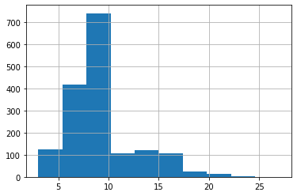

```python
## Gene analysis
FSoutput_vcf_formatted['#genesOverlapping'] = ''
for i in FSoutput_vcf_formatted.index:
    if pd.isnull(FSoutput_vcf_formatted.loc[i,'duxPredictedGenes']) or pd.isnull(FSoutput_vcf_formatted.loc[i,'FunseqGeneList']):
        FSoutput_vcf_formatted.loc[i,'#genesOverlapping'] = np.NaN
    else:
        tempList_dux = list(FSoutput_vcf_formatted.loc[i,'duxPredictedGenes'])
        tempList_vcf = list(FSoutput_vcf_formatted.loc[i,'FunseqGeneList'])
        overlap = len(set(tempList_dux) & set(tempList_vcf))
        FSoutput_vcf_formatted.loc[i,'#genesOverlapping'] = overlap

d(FSoutput_vcf_formatted)

print(FSoutput_vcf_formatted['#genesOverlapping'].isna().sum())
# print(FSoutput_vcf_formatted['#genesOverlapping'].value_counts())
FSoutput_vcf_formatted['#genesOverlapping'].hist()
```

### 0.3.5 - Running CNCDriver on PCAWG Samples + Analysis

```python
# ########### INSTALLATING CNCDRIVER ###############
# ## IN TERMINAL
# R
# install.packages("devtools",repos='http://cran.us.r-project.org')
# devtools::install_github("hadley/devtools")
# library("remotes")
# install.packages("rmarkdown")

# if (!require("BiocManager", quietly = TRUE))
#     install.packages("BiocManager")
# BiocManager::install("BiocStyle")

# remotes::install_github("khuranalab/CNCDriver", ref="master", build_vignette=FALSE)
# ## NOTE, it said to use build_vignette=TRUE but this didn't work for me, kept giving error

# ########### INSTALLATING CNCDRIVER ON CLUSTER ###############
# ## DON"T FORGET TO ACTIVATE ENVIRONMENT EACH TIME!!!!! #########
# conda create --name cncDriver_env
# source activate cncDriver_env

# conda install -c conda-forge r-devtools
# R
# devtools::install_github("hadley/devtools")
# library("remotes")
# install.packages("rmarkdown")

# if (!require("BiocManager", quietly = TRUE))
#     install.packages("BiocManager")
# BiocManager::install("BiocStyle")

# remotes::install_github("khuranalab/CNCDriver", ref="master")

# ## copying data context
# cd /athena/khuranalab/scratch/acp4001
# cp -R /athena/khuranalab/scratch/naa4013/CNCDriver_data_hg38 /athena/khuranalab/scratch/acp4001


# ###### Other dependencies
# BiocManager::install("TxDb.Hsapiens.UCSC.hg38.knownGene") # need b/c CNCdriver only has hg19
# BiocManager::install("BSgenome.Hsapiens.UCSC.hg38") # need b/c CNCdriver only has hg19
```

```python
## Getting hg19 and hg38 files from Nawaf

cp -r /home/naa4013/khurana_lab_work/nawaf_tools/CNCDriver_working_dir/cncdriver_input_files/CNCDriver_data/ /athena/khuranalab/scratch/acp4001/CNCDriver_data_hg19/
```

#### 0.3.5.3 - Making the enhancerRegionBedFile & analysis w/ Andre's TNBC_sample_drm.gene_hg38 file

```python
# ######## Quick code to make P5_0.3.5.3_PeakBed_TNBC_allOpenPeaks_hg38.bed #########
# ## Read files
# peakBed = pd.read_csv('/Users/annpalladino/Documents/khuranalab/00_raw_files/04_dux_EX0161_allPeakBed_hg38.bed', sep = '\t')

# tnbcPeak = pd.read_csv('/Users/annpalladino/Documents/khuranalab/P5_AOCproject/P5_0.1.2_TNBC_TCGApeaks.csv', index_col = [0])
# # d(peakBed)
# # d(tnbcPeak)
# # d(tnbcP2g)

# ##########

# TNBClinkedPeakList = list(tnbcP2g['peak'].unique())
# # print(len(TNBCpeakList))
# tnbcPeakBed_linkedpeaks = peakBed[peakBed['name'].isin(TNBClinkedPeakList)] #562,709 total peaks -> 35,886 peaks with links

# tnbcPeakBed_linkedpeaks = pd.merge(tnbcP2g,tnbcPeakBed_linkedpeaks, how = 'right', left_on = 'peak', right_on='name')

# tnbcPeakBed_linkedpeaks = tnbcPeakBed_linkedpeaks[['#seqnames','start','end','gene']]

# tnbcPeakBed_linkedpeaks.to_csv('P5_AOCproject/P5_0.3.5.3_PeakBed_TNBC_allLinkedPeaks_hg38.bed', index = None, sep = '\t', header = None) # don't use header b/c doesn't fit w/ format

# d(tnbcP2g)
# d(tnbcPeakBed_linkedpeaks)
```

```python
# ######### Making the enhancerRegionBedFile AND peakBed for allOpenPeaks  ###################

# ## did so w/ TNBC linkedPeaks (ie peaks w/ at least 1 link predicted in 1 of 15 of the TNBC samples; did this b/c the enhancerRegionBedFile format is:

# ## Chr Start End Gene

# ## so, by default it can only include peaks w/ a gene linked to them. could consider peaks w/ a link to any gene present in any BRCA samples instead of TNBC only??

# ## Read files
# peakBed = pd.read_csv('/Users/annpalladino/Documents/khuranalab/00_raw_files/04_dux_EX0161_allPeakBed_hg38.bed', sep = '\t')

# tnbcPeak = pd.read_csv('/Users/annpalladino/Documents/khuranalab/P5_AOCproject/P5_0.1.2_TNBC_TCGApeaks.csv', index_col = [0])

# tnbcP2g = pd.read_csv('/Users/annpalladino/Documents/khuranalab/P5_AOCproject/P5_0.1.2_TNBC_peak2gene.csv', index_col=[0])

# # d(peakBed)
# # d(tnbcPeak)
# # d(tnbcP2g)

# ##############################################

# TNBCOpenPeakList = list(tnbcPeak.index.unique())
# print(len(TNBCOpenPeakList))
# tnbcPeakBed_openPeaks = peakBed[peakBed['name'].isin(TNBCOpenPeakList)] #####562,709 total peaks -> 481,938  ope peaks

# # tnbcPeakBed_openPeaks = pd.merge(tnbcP2g,tnbcPeakBed_openPeaks, how = 'right', left_on = 'peak', right_on='name')

# # tnbcPeakBed_linkedpeaks = tnbcPeakBed_linkedpeaks[['#seqnames','start','end','gene']]

# tnbcPeakBed_openPeaks.to_csv('P5_AOCproject/P5_0.3.5.3_PeakBed_TNBC_allOpenPeaks_hg38.bed', index = None, sep = '\t', header = None) # don't use header b/c doesn't fit w/ format

# d(tnbcPeakBed_openPeaks)

# #############################################

# TNBClinkedPeakList = list(tnbcP2g['peak'].unique())
# # print(len(TNBCpeakList))
# tnbcPeakBed_linkedPeaks = peakBed[peakBed['name'].isin(TNBClinkedPeakList)] #562,709 total peaks -> 35,886 peaks with links

# tnbcPeakBed_linkedPeaks = pd.merge(tnbcP2g,tnbcPeakBed_linkedPeaks, how = 'right', left_on = 'peak', right_on='name')

# tnbcPeakBed_linkedPeaks = tnbcPeakBed_linkedPeaks[['#seqnames','start','end','gene']]

# tnbcPeakBed_linkedpeaks.to_csv('P5_AOCproject/P5_0.3.5.3_PeakBed_TNBC_allLinkedPeaks_hg38.bed', index = None, sep = '\t', header = None) # don't use header b/c doesn't fit w/ format

# d(tnbcP2g)
# d(tnbcPeakBed_linkedpeaks)

# # ############# MAKING enhancerRegionBedFile BASED ON ANDRE'S FILES ################
# # cd /athena/khuranalab/scratch/acp4001
# # cut -d$'\t' -f 1-4 funseq_hg38_data_context/BRCA_sample_drm.gene_hg38.bed > CNCDriver_data_hg38/enhancerBedfile_BRCA_sample_drm.gene_hg38.bed
# # cut -d$'\t' -f 1-4 funseq_hg38_data_context/TNBC_sample_drm.gene_hg38.bed > CNCDriver_data_hg38/enhancerBedfile_TNBC_sample_drm.gene_hg38.bed
# # ## Num Lines in file = BRCA: 56356 linked enhancers, TNBC = 44,471 linked enhancers
```

```
481938
```

|  | #seqnames | start | end | name |
| --- | --- | --- | --- | --- |
| 0 | chr1 | 17239 | 17739 | PCPG_2 |
| 3 | chr1 | 180654 | 181154 | TGCT_2 |

```
(481938, 4)
```

|  | TCGA-S3-AA0Z | TCGA-AR-A0U4 | TCGA-AR-A0U0 | TCGA-AO-A12F | TCGA-C8-A12V | TCGA-C8-A12K | TCGA-BH-A0E0 | TCGA-AR-A0TP | TCGA-AO-A0JB | TCGA-A2-A0YJ | TCGA-AO-A124 | TCGA-A7-A13E | TCGA-BH-A0DL | TCGA-A2-A4RX | TCGA-A2-A0SX | count | gene | peak |
| --- | --- | --- | --- | --- | --- | --- | --- | --- | --- | --- | --- | --- | --- | --- | --- | --- | --- | --- |
| KTN1-THCA_66795 | 0 | 0 | 0 | 0 | 0 | 0 | 0 | 0 | 0 | 0 | 0 | 1 | 0 | 0 | 0 | 1 | KTN1 | THCA_66795 |
| ZNF703-ACC_40338 | 1 | 1 | 1 | 1 | 1 | 1 | 1 | 1 | 1 | 1 | 1 | 1 | 1 | 1 | 1 | 15 | ZNF703 | ACC_40338 |

```
(44992, 18)
```

|  | #seqnames | start | end | gene |
| --- | --- | --- | --- | --- |
| 0 | chr14 | 55685088 | 55685588 | KTN1 |
| 1 | chr8 | 37700192 | 37700692 | ZNF703 |

```
(44992, 4)
```

```python
# # ####### comparison w/ Andre's DRM file (edit)
# # ssh curie.pbtech
# # srun -n1 --pty --partition=panda --mem=20G bash -i
# # cd /athena/khuranalab/scratch/acp4001
# # bedtools intersect -wa -wb -a CNCDriver_data_hg38/enhancerBedfile_TNBC_sample_drm.gene_hg38.bed -b P5_AOCproject/P5_0.3.5.3_PeakBed_TNBC_allLinkedPeaks_hg38.bed > CNCDriver_data_hg38/temp_Overlap_andreTNBC_my0.3.5.3peakBed.bed

# temp_intersect = pd.read_csv('/Users/annpalladino/Downloads/temp_Overlap_andreTNBC_my0.3.5.3peakBed.bed', sep = '\t', header = None)
# print(temp_intersect[])
# display(temp_intersect.tail())

# # TRY INTERSECTING UNIQUE POINTS AND THEN OVERLAP :)
```

|  | 0 | 1 | 2 | 3 | 4 | 5 | 6 | 7 |
| --- | --- | --- | --- | --- | --- | --- | --- | --- |
| 69827 | chr21 | 14533940 | 14534440 | HSPA13 | chr21 | 14533940 | 14534440 | SAMSN1-AS1 |
| 69828 | chr21 | 14533940 | 14534440 | HSPA13 | chr21 | 14533940 | 14534440 | HSPA13 |
| 69829 | chr9 | 33239889 | 33240389 | SMU1 | chr9 | 33239889 | 33240389 | NFX1 |
| 69830 | chr9 | 33239889 | 33240389 | SMU1 | chr9 | 33239889 | 33240389 | SPINK4 |
| 69831 | chr9 | 33239889 | 33240389 | SMU1 | chr9 | 33239889 | 33240389 | SMU1 |

```python
# # see overlap of variants vs enhancerBed files
# cd /Users/annpalladino/Documents/khuranalab/P5_AOCproject/

# # TNBC variants vs my enhancer Bed file
# cut -d$'\t' -f 1-4 P5_0.3_PCAWG_CNCDriver/FunseqOutput_tnbcTNBCContext/CNCDriverInput/tnbcTNBCContext_NCDS.txt > temp_tnbcTNBCcontext.bed # file of tnbcTNBC variant calls

# tail -n +2 temp_tnbcTNBCcontext.bed > temp_tnbcTNBCcontext_1.bed

# bedtools intersect -wa -wb -a temp_tnbcTNBCcontext_1.bed -b P5_0.3.5.3_PeakBed_TNBC_allLinkedPeaks_hg38.bed > temp_intersect_tnbcTNBCfunseqCalls_myPeakBed.bed

# # RESULTS:
# # tnbcTNBC = 19,187
# # myPeakBed (linked peaks) = 44,992
# # overlap = 1,885

# # TNBC variants vs Andre enhancer Bed file
# bedtools intersect -wa -wb -a temp_tnbcTNBCcontext_1.bed -b enhancerBedfile_TNBC_sample_drm.gene_hg38.bed > temp_intersect_tnbcTNBCfunseqCalls_andrePeakBed.bed

# # RESULTS:
# # tnbcTNBC = 19,187
# # andrePeakBed (linked peaks) = 44,471
# # overlap = 1,871

# # SO I guess most of the tnbcTNBC mutations were just in unlinked peaks? ie peaks that were open 1 of 17 samples but NOT linked
```

### 0.3.6 - CNCDriver Output Analysis

```python
# ###### DATA GENERATED
# - dataDetailed/enhancerUnit_cluster
# -- completeData
# --- BRCA_enhancerUnit... .txt

# -- prefiltered_minPts_2_distance_50
# --- BRCA enhancerUnit... .txt

# - output_result_triMut_match/enhancerUnit_cluster/BRCA/RT_0.2
# -- BRCA_outputDf_enhancerUnit... .txt
# -- log_enhancerUnit_cluster... .txt
# -- tmpOutput_enhancerUnit... .txt

# - Rplots.pdf
```

```python
## 1) Calculate Lambda value;
##
ssh curie.pbtech
srun -n1 --pty --partition=panda --mem=50G bash -i
acp

R

BRCA_outputDf_promoter<-read.delim('/athena/khuranalab/scratch/acp4001/P5_AOCproject/3_CNCDriverOutput/PCAWG/TNBCtnbcTrial1bContext/hg38/output_result_triMut_match/promoter_cluster/BRCA/RT_0.2/BRCA_outputDf_promoter_cluster_allSamples_minPoints_2_dRadius_50_with_RT_correction_similarity_0.2_triMut_match_distribution_task_0_iter_10000_.txt', header = TRUE, sep = '\t') # analysis of genes can be found in Summary stats

BRCA_outputDf_enhancer<-read.delim('/athena/khuranalab/scratch/acp4001/P5_AOCproject/3_CNCDriverOutput/PCAWG/TNBCtnbcTrial1bContext/hg38/output_result_triMut_match/enhancerUnit_cluster/BRCA/RT_0.2/BRCA_outputDf_enhancerUnit_cluster_allSamples_minPoints_2_dRadius_50_with_RT_correction_similarity_0.2_triMut_match_distribution_task_0_iter_10000_.txt', header = TRUE, sep = '\t')

## 1) Calculate Lambda Value, ie the estimate of the slope given by permPvector
pvector<-BRCA_outputDf_promoter$pValue
observedPvector<-sort(pvector,decreasing=F)
permPvector<-1:length(observedPvector)/length(observedPvector)
myLambda <- summary(lm(observedPvector ~ 0 + permPvector))$coeff[1,1]
# PCAWG myLambda = 1.099141.... (if pvector = $qValue column then: 1.409461)
# allSamples myLambda = 1.111153 ($qValue => 1.45778)


pvector<-BRCA_outputDf_enhancer$pValue
observedPvector<-sort(pvector,decreasing=F)
permPvector<-1:length(observedPvector)/length(observedPvector)
myLambda <- summary(lm(observedPvector ~ 0 + permPvector))$coeff[1,1]
# PCAWG myLambda = 1.260714
# allSamples myLambda = 1.083744 ($qValue => 1.372797)
```

```python
## 2) Compare against PCAWG/Liu results
LiuPromoterDrivers = pd.read_excel('/Users/annpalladino/Documents/khuranalab/P5_AOCproject/CTCF_CNCDriverPaperSupplement/TableS5_Promoters_1-s2.0-S2405471219301176-mmc6.xlsx', 'BRCA')
TNBCPromoterDrivers = pd.read_csv('/Users/annpalladino/Documents/khuranalab/P5_AOCproject/3_CNCdriverOutput/PCAWG/TNBCtnbcTrial1bContext/hg38/output_result_triMut_match/promoter_cluster/BRCA/RT_0.2/BRCA_outputDf_promoter_cluster_allSamples_minPoints_2_dRadius_50_with_RT_correction_similarity_0.2_triMut_match_distribution_task_0_iter_10000_.txt', sep = '\t')
LiuEnhancerDrivers = pd.read_excel('/Users/annpalladino/Documents/khuranalab/P5_AOCproject/CTCF_CNCDriverPaperSupplement/TableS6_Enhancers_1-s2.0-S2405471219301176-mmc7.xlsx', 'BRCA')
TNBCEnhancerDrivers = pd.read_csv('/Users/annpalladino/Documents/khuranalab/P5_AOCproject/3_CNCdriverOutput/PCAWG/TNBCtnbcTrial1bContext/hg38/output_result_triMut_match/enhancerUnit_cluster/BRCA/RT_0.2/BRCA_outputDf_enhancerUnit_cluster_allSamples_minPoints_2_dRadius_50_with_RT_correction_similarity_0.2_triMut_match_distribution_task_0_iter_10000_.txt', sep = '\t')

d(LiuPromoterDrivers)
d(TNBCPromoterDrivers)
d(LiuEnhancerDrivers)
d(TNBCEnhancerDrivers)
```

|  | geneSymbol | numOfAlteredPos | numOfAlterations | numOfPatients | pValue | qValue |
| --- | --- | --- | --- | --- | --- | --- |
| 0 | CCDC107 | 3 | 3 | 4 | 0.000010 | 0.005200 |
| 1 | STAG1 | 2 | 2 | 1 | 0.000061 | 0.014153 |

```
(520, 6)
```

|  | elementPos | numOfAlterationPos | numOfAlteration | numOfPatient | compositeDriverScore | numOfAboveCDscore | reSampleNum | pValue | qValue |
| --- | --- | --- | --- | --- | --- | --- | --- | --- | --- |
| 0 | GPI | 3 | 3 | 2 | 6.281908 | 0 | 34220 | 0.000029 | 0.001724 |
| 1 | SPC24 | 2 | 2 | 1 | 4.515476 | 0 | 903 | 0.001106 | 0.032633 |

```
(59, 9)
```

|  | geneSymbol | numOfAlteredPos | numOfAlterations | numOfPatients | pValue | qValue |
| --- | --- | --- | --- | --- | --- | --- |
| 0 | chr1:183239692-183240277 | 9 | 9 | 1 | 0.000010 | 0.002280 |
| 1 | chr1:201095944-201096208 | 2 | 2 | 1 | 0.000042 | 0.004819 |

```
(228, 6)
```

|  | enhancerUnitPos | numOfAlteredElements | elementPos | numOfAlterationPos | numOfAlteration | numOfPatient | compositeDriverScore | numOfAboveCDscore | reSampleNum | pValue | qValue |
| --- | --- | --- | --- | --- | --- | --- | --- | --- | --- | --- | --- |
| 0 | chr2:39736557-39737056 | 1 | THUMPD2 | 2 | 2 | 2 | 2.920897 | 0 | 28 | 0.034483 | 0.396694 |
| 1 | chr1:25425546-25426045 | 1 | TMEM50A | 2 | 2 | 1 | 4.515572 | 5 | 120 | 0.049587 | 0.396694 |

```
(16, 11)
```

```python
# ## Gene overlap for Promoters
# list1 = LiuPromoterDrivers['geneSymbol']
# list2 = TNBCPromoterDrivers['elementPos']
# overlap(list1,list2, Make = True) # 22 overlap

## Gene overlap for Enhnacers
temp_liuForIntersect = LiuEnhancerDrivers[['geneSymbol']]
temp_liuForIntersect['chr'], temp_liuForIntersect['coord'] = temp_liuForIntersect['geneSymbol'].str.split(':').str
temp_liuForIntersect['start'], temp_liuForIntersect['stop'] = temp_liuForIntersect['coord'].str.split('-').str
temp_liuForIntersect = temp_liuForIntersect[['chr','start','stop','geneSymbol']]
temp_liuForIntersect.sort_values(by=['chr','start','stop'], inplace = True)

# temp_TNBCForIntersect = TNBCEnhancerDrivers[['enhancerUnitPos']]
# temp_TNBCForIntersect['chr'], temp_TNBCForIntersect['coord'] = temp_TNBCForIntersect['enhancerUnitPos'].str.split(':').str
# temp_TNBCForIntersect['start'], temp_TNBCForIntersect['stop'] = temp_TNBCForIntersect['coord'].str.split('-').str
# temp_TNBCForIntersect = temp_TNBCForIntersect[['chr','start','stop','enhancerUnitPos']]

d(temp_liuForIntersect)
# d(temp_TNBCForIntersect)

temp_liuForIntersect.to_csv('/Users/annpalladino/Documents/khuranalab/temp_liuForIntersect.bed', header = None, index = None, sep ='\t')
# temp_TNBCForIntersect.to_csv('/Users/annpalladino/Documents/khuranalab/temp_TNBCForIntersect.bed', header = None, index = None, sep ='\t')

# ## on terminal
# liftOver temp_liuForIntersect.bed 00_raw_files/ucsc_hg19ToHg38.over.chain /Users/annpalladino/Documents/khuranalab/P5_AOCproject/CTCF_CNCDriverPaperSupplement/liuForIntersect_hg38.bed temp_unMapped_liu

# bedtools intersect -wa -wb -a /Users/annpalladino/Documents/khuranalab/P5_AOCproject/CTCF_CNCDriverPaperSupplement/liuForIntersect_hg38.bed -b /Users/annpalladino/Documents/khuranalab/temp_TNBCForIntersect.bed # no overlap
```

|  | chr | start | stop | geneSymbol |
| --- | --- | --- | --- | --- |
| 139 | chr1 | 110526078 | 110526596 | chr1:110526078-110526596 |
| 57 | chr1 | 111184233 | 111184630 | chr1:111184233-111184630 |

```
(228, 4)
```

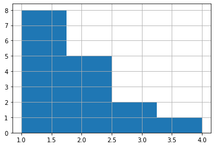

```python
# TNBCPromoterDrivers['numOfPatient'].hist(bins = 5)
TNBCEnhancerDrivers['numOfPatient'].hist(bins = 4)
```

```python
from bs4 import BeautifulSoup

# with open("index.html") as fp:
#     soup = BeautifulSoup(fp, 'html.parser')

soup = BeautifulSoup("/Users/annpalladino/Downloads/SPC24 Gene - GeneCards _ SPC24 Protein _ SPC24 Antibody.html", 'html.parser')

print(soup.prettify())
# soup
```

```
/Users/annpalladino/Downloads/SPC24 Gene - GeneCards _ SPC24 Protein _ SPC24 Antibody.html
```

# 1.0 - FunSeq + CNCDriver on ER+ cell lines - DIDN'T USE!!

## 1.1 - finding data

```python
# For the ER+ samples, I went to CCLE and was able to find a file w/ merged mutation calls called "CCLE_mutations.csv" (1,231,281 mutations; from link below) -> 10,743 SNPs in ER+ breast cancer cell lines (21 cell lines) -> lifted over to hg38 -> intersected with peakBed_hg38 -> only 2,153 SNPs in the enhancer regions... I also tried to look at specific cell lines, like MCF7, but they all seem to point back to the CCLE_mutations.csv file (link below)

link to CCLE data: https://depmap.org/portal/download/
link to MCF7 data: https://depmap.org/portal/cell_line/ACH-000019?tab=mutation ; the "Mutation 22Q1 Public" links back to the CCLE_mutations.csv file


## LOOKING AT CCLE data
tempdf_og = pd.read_csv('/Users/annpalladino/Downloads/CCLE_mutations.csv')
d(tempdf_og, 10)

tempList=['ACH-000019', 'ACH-000028', 'ACH-000044', 'ACH-000097', 'ACH-000117', 'ACH-000147', 'ACH-000277', 'ACH-000330', 'ACH-000349', 'ACH-000352', 'ACH-000568', 'ACH-000759', 'ACH-000783', 'ACH-000818', 'ACH-000828', 'ACH-000876', 'ACH-000927', 'ACH-000934', 'ACH-001395', 'ACH-001396', 'ACH-001514'] # n = 21

tempdf = tempdf_og[tempdf_og['DepMap_ID'].isin(tempList)] # 1,231,281 -> 11,321
tempdf = tempdf[tempdf['Variant_Type'] == 'SNP'] # 11,321 -> 10,743
d(tempdf)

tempdf['CHR'] = 'chr'+ tempdf['Chromosome'].astype(str)
tempdf['END'] = tempdf['End_position'] + 1
tempdf = tempdf[['CHR','Start_position','END','DepMap_ID']]
d(tempdf)
tempdf.to_csv('tempdf_hg19.bed', header = None, index = None, sep = '\t')

# liftOver tempdf_hg19.bed 00_raw_files/ucsc_hg19ToHg38.over.chain tempdf_hg38.bed tempUnmapped # all 10743 get lifted over
# bedtools intersect -a tempdf_hg38.bed -b 00_raw_files/04_dux_EX0161_allPeakBed_hg38.bed > temp.bed # only 2,153 overlap w/ erica's peakBed_hg38 file

tempdf1 = pd.read_csv('temp.bed', header = None, sep = '\t')
print(len(tempdf1[3].unique())) #20 samples
d(tempdf1)
```

```python
# ## LOOKING AT COSMIC DATA
# https://cancer.sanger.ac.uk/cell_lines/download # downloaded from here, the "Complete mutation data" -> "download whole file" -> is ~600MB .gz file -> uploaded to Cluster via Cyberduck then did:
# gunzip CosmicCLP_MutantExport.tsv.gz
# mv CosmicCLP_MutantExport.tsv raw_CosmicCellLineProject_VariantCalls_6mil.tsv
# python
# import pandas as pd
# import numpy as np
# cosmicDf = pd.read_csv('/athena/khuranalab/scratch/acp4001/P5_AOCproject/raw_CosmicCellLineProject_VariantCalls_6mil.tsv', sep = '\t', encoding='latin-1')

# >>> cosmicDf.shape
# (6057238, 42)
# >>> breastDf.shape
# (227938, 42)
# >>> print(breastDf['Histology subtype 1'].unique())
# ['NS' 'ductal_carcinoma']
# >>> print(breastDf['GRCh'].unique())
# [38.]
# >>> print(breastDf['Sample source'].unique())
# ['cell-line']
# >>>

# breastDf['chr'], breastDf['temp'] = breastDf['Mutation genome position'].str.split(':', n = 1).str

# breastDf['start'], breastDf['end'] = breastDf['temp'].str.split('-').str


# breastDf.to_csv('P5_1.1_CosmicCellLineProject_VariantCalls_brca200k_hg38.tsv', sep = '\t')

# tempdf = breastDf[['chr','start','end','Sample name']]
# tempdf['chr'] = 'chr'+ tempdf['chr'].astype(str)

# tempdf.to_csv('tempdf.bed',header = None, index = None, sep = '\t')

# # on my computer
# bedtools intersect -a /Users/annpalladino/Downloads/tempdf.bed -b 00_raw_files/04_dux_EX0161_allPeakBed_hg38.bed > tempdf.bed #37850

tempdf1 = pd.read_csv('tempdf.bed', header = None, sep = '\t')
print(len(tempdf1[3].unique())) #52 samples
d(tempdf1)
```

```
52
```

|  | 0 | 1 | 2 | 3 |
| --- | --- | --- | --- | --- |
| 0 | chr6 | 32665018 | 32665018 | HCC1419 |
| 1 | chr17 | 82134092 | 82134092 | HCC1569 |

```
(37850, 4)
```

```python
QUESTIONS
1) filter COSMIC samples by ER+
2) how were variants called for both CCLE and COSMIC? ie via SNP?
```

# 3.0 - Neville's Project!

## 3.1 - Formatting Andre's Funseq Files for CNCDriver

```python
# ####### On terminal #############

# cd /athena/khuranalab/scratch/acp4001/P5_AOCproject/2_FunseqOutput
# cp /home/anf2034/BRCA_*_Funseq_Recurrence_hg19_raw.bed /athena/khuranalab/scratch/acp4001/P5_AOCproject/2_FunseqOutput/andre_BRCA

# python
import pandas as pd
import numpy as np

BRCA_EU_hg19 = pd.read_csv('BRCA_EU_Funseq_Recurrence_hg19_raw.bed', sep = r'[\t;]')
BRCA_UK_hg19 = pd.read_csv('BRCA_UK_Funseq_Recurrence_hg19_raw.bed', sep = r'[\t;]')

columns = list(BRCA_UK_hg19.columns) # column names to use when reading in BRCA_US
BRCA_US_hg19 = pd.read_csv('BRCA_US_Funseq_Recurrence_hg19_raw.bed', sep = r'[\t;]', header = None, names = columns)

cohortNames = ['BRCA_EU_hg19', 'BRCA_UK_hg19', 'BRCA_US_hg19']
cohortList = [BRCA_EU_hg19,BRCA_UK_hg19,BRCA_US_hg19]
for n in range(3):
    cohortName = cohortNames[n]
    cohortDf = cohortList[n]
    print(cohortName)
    print(cohortDf.shape)
#     print(cohortDf['cds'].value_counts())
#     hubstring = cohortDf['network.hub']
#     if 'BRCA_REG' in hubstring:
#         print(hubstring)


for cohort in cohortList:
    cohort['MOTIFBR'], cohort['MOTIFG'] = '',''
    for i in cohort.index:
        motifAnalysisString = cohort.loc[i,'motif.analysis']
        if motifAnalysisString.startswith('MOTIFBR'):
            if ('MOTIFG' in motifAnalysisString):
                motifAnalysisList = motifAnalysisString.split(',MOTIFG=')
                MOTIFBR = motifAnalysisList[0][8:] # [0] calls first instance of the list, [8:] takes all the characters after the
                MOTIFG = motifAnalysisList[1]
                cohort.loc[i,'MOTIFBR'] = MOTIFBR
                cohort.loc[i,'MOTIFG'] = MOTIFG
            else:
                cohort.loc[i,'MOTIFBR'] = motifAnalysisString[8:]
                cohort.loc[i,'MOTIFG'] = np.nan
        if motifAnalysisString.startswith('MOTIFG'):
            if ('MOTIFBR' in motifAnalysisString):
                motifAnalysisList = motifAnalysisString.split(',MOTIFBR=')
                MOTIFG = motifAnalysisList[0][7:]
                MOTIFBR = motifAnalysisList[1]
                cohort.loc[i,'MOTIFBR'] = MOTIFBR
                cohort.loc[i,'MOTIFG'] = MOTIFG
            else:
                cohort.loc[i,'MOTIFG'] = motifAnalysisString[7:]
                cohort.loc[i,'MOTIFBR'] = np.nan

for n in range(3):
    cohortName = cohortNames[n]
    cohortDf = cohortList[n]
    cohortDf.replace('.', np.NaN, inplace = True)
    cohortDf.to_csv(('/home/acp4001/tempAndreBRCA_'+cohortName+'_formatted.bed'), sep = '\t', header = None, index = None) # next time don't do "header = None", caused more headaches, see below

### on terminal ###
# cat tempAndreBRCA_BRCA_* > BRCAbrcaTrial1Context_hg19_NCDS.txt # make sure to move to right place, in this case, home folder

python
import pandas as pd

columns = ['chr', 'posStart', 'posEnd', 'ref', 'alt', 'sampleID', 'GERP', 'CDS', 'VA', 'HUB', 'GNEG', 'NCENC', 'HOT', 'motif.analysis', 'SEN', 'USEN', 'UCONS','GENE','user.annotations','CDSS', 'NCDS', 'RECUR', 'DBRECUR','MOTIFBR', 'MOTIFG']

df = pd.read_csv('BRCAbrcaTrial1Context_hg19_NCDS.txt', sep = '\t', header = None, names = columns)

df['tumorType'] = 'BRCA'

tempdf = df[['chr', 'posStart', 'posEnd', 'ref', 'alt', 'sampleID', 'CDS', 'VA', 'HUB', 'GNEG', 'GERP', 'UCONS', 'HOT', 'SEN', 'USEN', 'GENE', 'CDSS', 'NCDS', 'NCENC', 'MOTIFBR', 'MOTIFG', 'RECUR', 'DBRECUR', 'tumorType']]

tempdf.to_csv('/home/acp4001/P5_AOCproject/2_FunseqOutput/andre_BRCA/BRCA_brcaTrial1Context_hg19/BRCAbrcaTrial1Context_hg19_NCDS.txt', sep = '\t', index = None)


R
reducedFunseqOutputNCDS <- read.csv('/home/acp4001/P5_AOCproject/2_FunseqOutput/andre_BRCA/BRCA_brcaTrial1Context_hg19/BRCAbrcaTrial1Context_hg19_NCDS.txt',sep = '\t', row.names=NULL, na.strings="")

save(reducedFunseqOutputNCDS, file = '/home/acp4001/P5_AOCproject/2_FunseqOutput/andre_BRCA/BRCA_brcaTrial1Context_hg19/reducedFunseqOutputNCDS_BRCA.Rd', version = 3.6)

## RAN THRU CNCDRIVER, SLURM LOG FILE AND R CODE ARE LOCATED HERE: /athena/khuranalab/scratch/acp4001/P5_AOCproject/3_CNCDriverOutput/andre_BRCA/BRCA_brcaTrial1aContext_hg19
```

## 3.2 - CNCDriver Output Analysis: Compare to Neville's CRISPRi screen

```python
### on terminal ####

## 1) Compare against enhancers from Sanjana CRISPRi screen
## File is from Slack Andre/Erica convo, is now saved here: /athena/khuranalab/scratch/acp4001/P5_AOCproject/raw_dux_MCF7_RRA_all_guides_slim.txt

## Liftover peakBed files back to hg19 b/c thats what andre's samples are in; done locally
# download /athena/khuranalab/scratch/dux2001/EX_0161_fpBRCA/allPeakBed.bed
# liftOver /Users/annpalladino/Downloads/allPeakBed.bed /Users/annpalladino/Documents/athena/khuranalab/scratch/acp4001/00_raw_files/ucsc_hg38ToHg19.over.chain /Users/annpalladino/Downloads/temp_allPeakBed_hg19.bed /Users/annpalladino/Downloads/unMapped

## formatting of files
python
import pandas as pd
CRISPRiScreen = pd.read_csv('/athena/khuranalab/scratch/acp4001/P5_AOCproject/raw_dux_MCF7_RRA_all_guides_slim.txt', sep = '\t')
CNCDriverResults_hg19 = pd.read_csv('/athena/khuranalab/scratch/acp4001/P5_AOCproject/3_CNCDriverOutput/andre_BRCA/BRCA_brcaTrial1aContext_hg19/output_result_triMut_match/enhancerUnit_cluster/BRCA/RT_0.2/BRCA_outputDf_enhancerUnit_cluster_allSamples_minPoints_2_dRadius_50_with_RT_correction_similarity_0.2_triMut_match_distribution_task_0_iter_10000_.txt', sep = '\t')
peakBed_hg19 = pd.read_csv('/athena/khuranalab/scratch/acp4001/P5_AOCproject/temp_allPeakBed_hg19.bed', sep = '\t', header = None, names = ['chr_peakBed_hg19', 'start_peakBed_hg19', 'end_peakBed_hg19', 'peak_peakBed_hg19'])
peakBed_hg38 = pd.read_csv('/athena/khuranalab/scratch/dux2001/EX_0161_fpBRCA/allPeakBed.bed', sep = '\t', names = ['chr_peakBed_hg38', 'start_peakBed_hg38', 'end_peakBed_hg38', 'peak_peakBed_hg38'])
peakBed_hg38.drop(labels = [0], axis = 'index', inplace = True)

CRISPRiScreen = CRISPRiScreen[CRISPRiScreen['Gene'].str.contains('_')] # 15376 -> 14910 rows
CRISPRiScreen.rename(columns = {'Gene': 'peak_CRISPRi'}, inplace = True)

CRISPRiScreen = pd.merge(CRISPRiScreen, peakBed_hg19, how = 'left', left_on = 'peak_CRISPRi', right_on = 'peak_peakBed_hg19')

CRISPRiScreen = pd.merge(CRISPRiScreen, peakBed_hg38, how = 'left', left_on = 'peak_CRISPRi', right_on = 'peak_peakBed_hg38')
# CRISPRiScreen.dropna(subset = ['peak_peakBed'], inplace = True) # 14,910 -> 14,894


CRISPRiScreen['end_peakBed_hg19'] = CRISPRiScreen['end_peakBed_hg19'].astype('Int64') # note: if you just do .astype(int) it throws an error b/c can't convert NaN to int, is rectified if you use "int64"
CRISPRiScreen['start_peakBed_hg19'] = CRISPRiScreen['start_peakBed_hg19'].astype('Int64')
CRISPRiScreen.drop(columns = ['peak_peakBed_hg19', 'peak_peakBed_hg38'], inplace = True)
CRISPRiScreen.sort_values('p_val', inplace = True)
CRISPRiScreen['rank_CRISPRi'] = CRISPRiScreen['p_val'].rank() # rank by p_val instead of p.adj just to actually rank by "most to least" significant, ie 2 rows may have same p.adj but one is slightly more significant by p_val.. did the same for CNCDriver

# CRISPRiScreen.to_csv('/athena/khuranalab/scratch/acp4001/P5_AOCproject/P5_3.2_formatted_MCF7_RRA_all_guides_slim.txt', sep = '\t', index = None)

CRISPRiScreen = pd.read_csv('/athena/khuranalab/scratch/acp4001/P5_AOCproject/P5_3.2_formatted_MCF7_RRA_all_guides_slim.txt', sep = '\t')

CRISPRiScreen_sig = CRISPRiScreen[CRISPRiScreen['p.adj'] < 0.05]

peakBed_hg19['start+1_peakBed_hg19'] = peakBed_hg19['start_peakBed_hg19'] + 1 # do this for overlap w/ CNCDriver b/c CNCDriver does posStart+1 to convert from 0-based to 1-based
peakBed_hg19['chr:start-end_peakBed_hg19'] = peakBed_hg19['chr_peakBed_hg19'] + ':' + peakBed_hg19['start+1_peakBed_hg19'].astype(str) + '-' + peakBed_hg19['end_peakBed_hg19'].astype(str)

CNCDriverResults_hg19['enhancerUnitPos'] = CNCDriverResults_hg19['enhancerUnitPos'].str.split(',')
CNCDriverResults_hg19 = CNCDriverResults_hg19.explode('enhancerUnitPos')
CNCDriverResults_hg19 = pd.merge(CNCDriverResults_hg19, peakBed_hg19, how = 'left', left_on = 'enhancerUnitPos', right_on = 'chr:start-end_peakBed_hg19') # 9 out of 1,332 are NaN, ie don't map to any peak, none are particularly high ranking in terms of significance (ie row 674+)
CNCDriverResults_hg19.dropna(subset = ['peak_peakBed_hg19'], inplace = True) # 1332 -> 1323
CNCDriverResults_hg19['rank_CNCDriver'] = CNCDriverResults_hg19['pValue'].rank()

CNCDriverResults_hg19['chr_CNCDriver'], CNCDriverResults_hg19['start_CNCDriver'], CNCDriverResults_hg19['end_CNCDriver'] = CNCDriverResults_hg19['enhancerUnitPos'].str.split(':|-').str

#####################################
## Did bedtools intersect of CRISPRiScreen_sig ∩ CNCDRiver -> no intersection
temp_CRISPRiScreen = CRISPRiScreen[['chr_peakBed_hg19', 'start_peakBed_hg19', 'end_peakBed_hg19', 'peak_peakBed_hg19','rank']]
temp_CRISPRiScreen_sig = CRISPRiScreen_sig[['chr_peakBed_hg19', 'start_peakBed_hg19', 'end_peakBed_hg19', 'peak_peakBed_hg19','rank']]
temp_CNCDriverResults = CNCDriverResults_hg19[['chr_CNCDriver','start_CNCDriver','end_CNCDriver','rank']]

temp_CRISPRiScreen.to_csv('temp_CRISPRiScreen.bed', sep = '\t', header = None, index = None)
temp_CRISPRiScreen_sig.to_csv('temp_CRISPRiScreen_sig.bed', sep = '\t', header = None, index = None)
temp_CNCDriverResults.to_csv('temp_CNCDriverResults.bed', sep = '\t', header = None, index = None)
## do bedtools intersect locally -> no intersection :/
####################################
# Did intersection based on peak names -> no intersection
sigPeakList = CRISPRiScreen_sig['peak_CRISPRi'].unique()
CNCDriverResults_CRISPRiScreenSig_overlap = CNCDriverResults_hg19[CNCDriverResults_hg19['peak_peakBed_hg19'].isin(sigPeakList)] # empty dataframe :/

# look at overlap btwn NON significant peaks
CRISPRiScreen_CNCDriverResults_overlap = pd.merge(CRISPRiScreen, CNCDriverResults_hg19, how = 'inner', left_on = 'peak_CRISPRi', right_on = 'peak_peakBed_hg19', suffixes=('_CRISPRi', '_CNCDriver')) # there are some duplicated rows b/c CNCDriver has multiple enhancers per gene
#### header:
#### CRISPRi_peak  CNCDriver_peak   CNCDriver_Gene    CNCDriver_pValue
#### LGG_42096      LGG_42096         COL15A1         0.360464
## formatting
CRISPRiScreen_CNCDriverResults_overlap = CRISPRiScreen_CNCDriverResults_overlap[['peak_CRISPRi','Median_fold_change','LFC','p_val','p.adj','chr_peakBed_hg19_CRISPRi','start_peakBed_hg19_CRISPRi','end_peakBed_hg19_CRISPRi','rank_CRISPRi','enhancerUnitPos','numOfAlteredElements','elementPos','numOfAlterationPos','numOfAlteration','numOfPatient','compositeDriverScore','numOfAboveCDscore','pValue','qValue','rank_CNCDriver']]

CRISPRiScreen_CNCDriverResults_overlap.rename(columns = {'peak_CRISPRi': 'peak','Median_fold_change':'Median_fold_change_CRISPRi','LFC':'LFC_CRISPRi','p_val': 'pvalue_CRISPRi','p.adj':'qvalue_CRISPRi','chr_peakBed_hg19_CRISPRi': 'chr','start_peakBed_hg19_CRISPRi':'start','end_peakBed_hg19_CRISPRi':'end','enhancerUnitPos':'enhancerUnitPos_CNCDriver','numOfAlteredElements':'numOfAlteredElements_CNCDriver','elementPos':'elementPos_CNCDriver','numOfAlterationPos':'numOfAlterationPos_CNCDriver','numOfAlteration':'numOfAlteration_CNCDriver','numOfPatient':'numOfPatient_CNCDriver','compositeDriverScore':'compositeDriverScore_CNCDriver','numOfAboveCDscore':'numOfAboveCDscore_CNCDriver','pValue':'pvalue_CNCDriver','qValue':'qvalue_CNCDriver'}, inplace = True)

CRISPRiScreen_CNCDriverResults_overlap.to_csv('/athena/khuranalab/scratch/acp4001/P5_AOCproject/3_CNCDriverOutput/andre_BRCA/BRCA_brcaTrial1aContext_hg19/3.2_CRISPRiScreen_CNCDriverResults_overlap.bed', sep = '\t', index = None)
```

|  | peak | Median_fold_change_CRISPRi | LFC_CRISPRi | pvalue_CRISPRi | qvalue_CRISPRi | chr | start | end | rank_CRISPRi | enhancerUnitPos_CNCDriver | numOfAlteredElements_CNCDriver | elementPos_CNCDriver | numOfAlterationPos_CNCDriver | numOfAlteration_CNCDriver | numOfPatient_CNCDriver | compositeDriverScore_CNCDriver | numOfAboveCDscore_CNCDriver | pvalue_CNCDriver | qvalue_CNCDriver | rank_CNCDriver |
| --- | --- | --- | --- | --- | --- | --- | --- | --- | --- | --- | --- | --- | --- | --- | --- | --- | --- | --- | --- | --- |
| 0 | BRCA_12940 | 0.794430 | -0.332008 | 0.000964 | 0.053909 | chr1 | 164567927 | 164568427 | 94.0 | chr1:164567928-164568427 | 1 | PBX1 | 4 | 5 | 8 | 9.279266 | 2522 | 0.252275 | 0.809867 | 412.0 |
| 1 | PCPG_10261 | 1.294463 | 0.372353 | 0.003235 | 0.124988 | chr2 | 85621948 | 85622448 | 191.0 | chr2:85621949-85622448 | 1 | MAT2A | 2 | 2 | 2 | 2.913435 | 7463 | 0.746325 | 0.992074 | 989.0 |
| 2 | LGG_42096 | 1.275001 | 0.350498 | 0.006356 | 0.200265 | chr9 | 101733356 | 101733856 | 273.0 | chr9:101733357-101733856 | 1 | COL15A1 | 2 | 2 | 2 | 4.331622 | 3604 | 0.360464 | 0.906029 | 494.0 |
| 3 | LGG_42096 | 1.275001 | 0.350498 | 0.006356 | 0.200265 | chr9 | 101733356 | 101733856 | 273.0 | chr9:101733357-101733856 | 1 | ANKS6 | 2 | 2 | 3 | 4.331622 | 4047 | 0.404760 | 0.906029 | 544.0 |
| 4 | PRAD_90510 | 0.643570 | -0.635832 | 0.013960 | 0.301679 | chr17 | 5163107 | 5163607 | 469.0 | chr17:5163108-5163607 | 1 | RABEP1 | 1 | 2 | 2 | 1.938212 | 391 | 0.523364 | 0.906029 | 756.0 |

```
(531, 20)
```

|  | peak | elementPos_CNCDriver | qvalue_CNCDriver |
| --- | --- | --- | --- |
| 2 | LGG_42096 | COL15A1 | 0.906029 |
| 3 | LGG_42096 | ANKS6 | 0.906029 |

```
(288, 3)
```

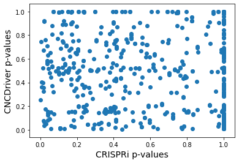

```python
CRISPRiScreen_CNCDriverResults_overlap = pd.read_csv('/Users/annpalladino/Documents/athena/khuranalab/scratch/acp4001/P5_AOCproject/3_CNCDriverOutput/andre_BRCA/BRCA_brcaTrial1aContext_hg19/3.2_CRISPRiScreen_CNCDriverResults_overlap.bed', sep = '\t')
CRISPRiScreen_CNCDriverResults_overlap.sort_values(by = 'rank_CRISPRi', inplace = True)
# CRISPRiScreen_CNCDriverResults_overlap.drop_duplicates(subset = 'peak', keep = 'first', inplace = True)
d(CRISPRiScreen_CNCDriverResults_overlap, 5)

x = CRISPRiScreen_CNCDriverResults_overlap['pvalue_CRISPRi']
y = CRISPRiScreen_CNCDriverResults_overlap['pvalue_CNCDriver']

plt.scatter(x,y)
plt.xlabel('CRISPRi p-values', size = 14)
plt.ylabel('CNCDriver p-values', size = 14)

tempdf = CRISPRiScreen_CNCDriverResults_overlap[CRISPRiScreen_CNCDriverResults_overlap['peak'].duplicated(keep = False)]
tempdf = tempdf[['peak', 'elementPos_CNCDriver', 'qvalue_CNCDriver']]
d(tempdf)
```

## 3.3 - Analysis of SV/CNV overlap

```python
# ## Get files
# cd /athena/khuranalab/scratch/acp4001/00_raw_files # note, this directory also has all the individual CNVs
# wget https://dcc.icgc.org/api/v1/download?fn=/current/Projects/BRCA-EU/copy_number_somatic_mutation.BRCA-EU.tsv.gz
# wget https://dcc.icgc.org/api/v1/download?fn=/current/Projects/BRCA-UK/copy_number_somatic_mutation.BRCA-UK.tsv.gz
# wget https://dcc.icgc.org/api/v1/download?fn=/current/Projects/BRCA-US/copy_number_somatic_mutation.BRCA-US.tsv.gz
# gunzip download\?fn\=%2Fcurrent%2FProjects%2FBRCA-EU%2Fcopy_number_somatic_mutation.BRCA-EU.tsv.gz
# gunzip download\?fn\=%2Fcurrent%2FProjects%2FBRCA-UK%2Fcopy_number_somatic_mutation.BRCA-UK.tsv.gz
# gunzip download\?fn\=%2Fcurrent%2FProjects%2FBRCA-US%2Fcopy_number_somatic_mutation.BRCA-US.tsv.gz
# mv download\?fn\=%2Fcurrent%2FProjects%2FBRCA-EU%2Fcopy_number_somatic_mutation.BRCA-EU.tsv 05_copy_number_somatic_mutation.BRCA-EU.tsv
# mv download\?fn\=%2Fcurrent%2FProjects%2FBRCA-UK%2Fcopy_number_somatic_mutation.BRCA-UK.tsv 06_copy_number_somatic_mutation.BRCA-UK.tsv
# mv download\?fn\=%2Fcurrent%2FProjects%2FBRCA-US%2Fcopy_number_somatic_mutation.BRCA-US.tsv 07_copy_number_somatic_mutation.BRCA-US.tsv

# ssh curie.pbtech
# srun -n1 --pty --partition=panda --mem=50G bash -i
# acp
# python
# import pandas as pd
# EU_CNVs = pd.read_csv('/athena/khuranalab/scratch/acp4001/00_raw_files/05_copy_number_somatic_mutation.BRCA-EU.tsv', sep = '\t')
# UK_CNVs = pd.read_csv('/athena/khuranalab/scratch/acp4001/00_raw_files/06_copy_number_somatic_mutation.BRCA-UK.tsv', sep = '\t')
# US_CNVs = pd.read_csv('/athena/khuranalab/scratch/acp4001/00_raw_files/07_copy_number_somatic_mutation.BRCA-US.tsv', sep = '\t')
# # EU = 7,009,807 lines
# # UK = 447,313 lines
# # US = 1,089,614 lines

# all_CNVs = pd.concat([EU_CNVs,UK_CNVs,US_CNVs]) # 8,546,734 lines
# all_CNVs = all_CNVs[['chromosome','chromosome_start','chromosome_end','icgc_donor_id','submitted_sample_id','mutation_type','segment_mean','assembly_version']]
# all_CNVs['chromosome'] = 'chr' + all_CNVs['chromosome']
# all_CNVs['variantSampleID'] = all_CNVs['chromosome'] + ':' + all_CNVs['chromosome_start'].astype(str) + '-' + all_CNVs['chromosome_end'].astype(str) + '_' + all_CNVs['mutation_type'] + '_' + all_CNVs['icgc_donor_id']
# all_CNVs['variantID'] = all_CNVs['chromosome'] + ':' + all_CNVs['chromosome_start'].astype(str) + '-' + all_CNVs['chromosome_end'].astype(str) + '_' + all_CNVs['mutation_type']
# all_CNVs.drop_duplicates(subset = 'variantSampleID', keep = 'first', inplace = True) # 8,546,734 -> 1,134,522 lines
# # all_CNVs.to_csv('/athena/khuranalab/scratch/acp4001/00_raw_files/P5_3.3_EUUKUSmerged_CNVs_hg19.tsv', sep = '\t', index = None)

## NOTES:
## all_CNVs has 1501 unique icgc_donor_ids
## previously it had been filtered from 8.5mil lines to 1.1mil lines based on variantSampleID (i.e. chr1:10208-3251382_undetermined_DO1984)

srun -n1 --pty --partition=panda --mem=50G bash -i
acp
python
import pandas as pd
all_CNVs = pd.read_csv('/athena/khuranalab/scratch/acp4001/00_raw_files/P5_3.3_EUUKUSmerged_CNVs_hg19.tsv', sep = '\t')
# for actual analysis, drop duplicates of variants (i.e. even if they're in different samples)
temp_allCNVs_forIntersect = all_CNVs[['chromosome','chromosome_start','chromosome_end','variantSampleID']]
temp_allCNVs_forIntersect.to_csv('temp_allCNVs_forIntersect.bed', sep = '\t', header = None, index = None)

CRISPRiScreen = pd.read_csv('/athena/khuranalab/scratch/acp4001/P5_AOCproject/P5_3.2_formatted_MCF7_RRA_all_guides_slim.txt', sep = '\t') # 14910 rows
CRISPRiScreen_sig = CRISPRiScreen[CRISPRiScreen['p.adj'] < 0.05] # 14910 -> 90
CRISPRiScreen_sig['start_peakBed_hg19'] = CRISPRiScreen_sig['start_peakBed_hg19'].astype(int)
CRISPRiScreen_sig['end_peakBed_hg19'] = CRISPRiScreen_sig['end_peakBed_hg19'].astype(int)
tempdf1 = CRISPRiScreen_sig[['chr_peakBed_hg19','start_peakBed_hg19','end_peakBed_hg19','peak_CRISPRi']]
tempdf1.sort_values(by = ['chr_peakBed_hg19','start_peakBed_hg19','end_peakBed_hg19'], inplace = True)
tempdf1.to_csv('temp_peaks_forIntersect.bed', sep = '\t', header = None, index = None)

CRISPRiScreen_insig = CRISPRiScreen[(CRISPRiScreen['p.adj'] > 0.05)] # 14,910 -> 14,820
CRISPRiScreen_insig.dropna(subset = ['p.adj','chr_peakBed_hg19'], inplace = True) # 14,820 -> 14,804; so dropping regions where there was no peakLoc is fine :) only 16 were dropped

CRISPRiScreen_insig['start_peakBed_hg19'] = CRISPRiScreen_insig['start_peakBed_hg19'].astype(int)
CRISPRiScreen_insig['end_peakBed_hg19'] = CRISPRiScreen_insig['end_peakBed_hg19'].astype(int)
tempdf1 = CRISPRiScreen_insig[['chr_peakBed_hg19','start_peakBed_hg19','end_peakBed_hg19','peak_CRISPRi']]
tempdf2 = tempdf1.sample(300)
tempdf2.sort_values(by = ['chr_peakBed_hg19','start_peakBed_hg19','end_peakBed_hg19'], inplace = True)
tempdf2.to_csv('temp_300randomPeaks1_forIntersect.bed', sep = '\t', header = None, index = None)

all_gains = all_CNVs[all_CNVs['mutation_type'] == 'gain'][['chromosome','chromosome_start','chromosome_end','variantSampleID']]
all_losses = all_CNVs[all_CNVs['mutation_type'] == 'loss'][['chromosome','chromosome_start','chromosome_end','variantSampleID']]
all_others = all_CNVs[(all_CNVs['mutation_type'] != 'gain') & (all_CNVs['mutation_type'] != 'loss')][['chromosome','chromosome_start','chromosome_end','variantSampleID']]
all_gains.to_csv('temp_allGains_forIntersect.bed', sep = '\t', header = None, index = None)
all_losses.to_csv('temp_allLosses_forIntersect.bed', sep = '\t', header = None, index = None)
all_others.to_csv('temp_allOthers_forIntersect.bed', sep = '\t', header = None, index = None)

##### FIX STARTING FROM HERE!!!!
## download the files and then do the following locally ##
## note, -f 1 = 100% of peak must overlap w/ the CNV

bedtools intersect -wo -f 1 -a temp_peaks_forIntersect.bed -b temp_allCNVs_forIntersect.bed > temp_peaksIntersected_allCNVs.bed

bedtools intersect -wo -f 1 -a temp_peaks_forIntersect.bed -b temp_allGains_forIntersect.bed > temp_peaksIntersected_allGains.bed

bedtools intersect -wo -f 1 -a temp_peaks_forIntersect.bed -b temp_allLosses_forIntersect.bed > temp_peaksIntersected_allLosses.bed

# bedtools intersect -wo -f 1 -a temp_peaks_forIntersect.bed -b temp_allOthers_forIntersect.bed > temp_peaksIntersected_allOthers.bed

##### For randomly selected peaks ####
bedtools intersect -wo -f 1 -a temp_300randomPeaks1_forIntersect.bed -b temp_allGains_forIntersect.bed > temp_300randomPeaksIntersected1_allGains.bed
bedtools intersect -wo -f 1 -a temp_300randomPeaks1_forIntersect.bed -b temp_allLosses_forIntersect.bed > temp_300randomPeaksIntersected1_allLosses.bed
```

```python
## read in files
## note, for the CNV data, you can have the same region w/ 2+ different CNVs in the same sample. i.e.: chr1:1-100_loss_sample1, chr1:20-30_loss_sample1.... so we only want to count these once I think... so will account for this below :)

CRISPRiScreen = pd.read_csv('/Users/annpalladino/Documents/athena/khuranalab/scratch/acp4001/P5_AOCproject/P5_3.2_formatted_MCF7_RRA_all_guides_slim.txt', sep = '\t')
CRISPRiScreen_sig = CRISPRiScreen[CRISPRiScreen['p.adj'] < 0.05][['peak_CRISPRi','p_val','p.adj','rank_CRISPRi']]
d(CRISPRiScreen_sig)

peaksIntersected_allCNVs = pd.read_csv('/Users/annpalladino/Downloads/temp_peaksIntersected_allCNVs.bed', sep = '\t', header = None, names = ['chr_peak','start_peak','end_peak', 'peak', 'chr_CNV', 'start_CNV', 'end_CNV','variantSampleID','numBpsOverlapping'])
peaksIntersected_allCNVs.sort_values(by = ['peak','chr_CNV', 'start_CNV', 'end_CNV'], inplace = True)
peaksIntersected_allCNVs['variantLoc'], peaksIntersected_allCNVs['mutationType'], peaksIntersected_allCNVs['icgc_donor_ids'] = peaksIntersected_allCNVs['variantSampleID'].str.split('_', n = 2).str
d(peaksIntersected_allCNVs)

# peaksIntersected_allGains = pd.read_csv('/Users/annpalladino/Downloads/temp_peaksIntersected_allGains.bed', sep = '\t', header = None, names = ['chr_peak','start_peak','end_peak', 'peak', 'chr_CNV', 'start_CNV', 'end_CNV','variantSampleID','numBpsOverlapping'])
peaksIntersected_allGains = pd.read_csv('/Users/annpalladino/Downloads/temp_300randomPeaksIntersected1_allGains.bed', sep = '\t', header = None, names = ['chr_peak','start_peak','end_peak', 'peak', 'chr_CNV', 'start_CNV', 'end_CNV','variantSampleID','numBpsOverlapping'])
peaksIntersected_allGains.sort_values(by = ['peak','chr_CNV', 'start_CNV', 'end_CNV'], inplace = True)
peaksIntersected_allGains['variantLoc'], peaksIntersected_allGains['mutationType'], peaksIntersected_allGains['icgc_donor_ids'] = peaksIntersected_allGains['variantSampleID'].str.split('_', n = 2).str
d(peaksIntersected_allGains)
print(peaksIntersected_allGains.shape)

# peaksIntersected_allLosses = pd.read_csv('/Users/annpalladino/Downloads/temp_peaksIntersected_allLosses.bed', sep = '\t', header = None, names = ['chr_peak','start_peak','end_peak', 'peak', 'chr_CNV', 'start_CNV', 'end_CNV','variantSampleID','numBpsOverlapping'])
peaksIntersected_allLosses = pd.read_csv('/Users/annpalladino/Downloads/temp_300randomPeaksIntersected1_allLosses.bed', sep = '\t', header = None, names = ['chr_peak','start_peak','end_peak', 'peak', 'chr_CNV', 'start_CNV', 'end_CNV','variantSampleID','numBpsOverlapping'])
peaksIntersected_allLosses.sort_values(by = ['peak','chr_CNV', 'start_CNV', 'end_CNV'], inplace = True)
peaksIntersected_allLosses['variantLoc'], peaksIntersected_allLosses['mutationType'], peaksIntersected_allLosses['icgc_donor_ids'] = peaksIntersected_allLosses['variantSampleID'].str.split('_', n = 2).str
d(peaksIntersected_allLosses)
print(peaksIntersected_allLosses['numBpsOverlapping'].value_counts())
print(peaksIntersected_allLosses.shape)

# peaksIntersected_allOthers = pd.read_csv('/Users/annpalladino/Documents/athena/khuranalab/scratch/acp4001/temp_peaksIntersected_allOthers.bed', sep = '\t', header = None)
# d(peaksIntersected_allOthers)

## more code for 300random peaks; note, just name the df "CRISPRiScreen_sig" so i don't have to change any code :P; can go back and change to something else, like filteredPeakDF
filteredPeakList = peaksIntersected_allGains['peak'].unique()
# print(len(filterdPeakList))
CRISPRiScreen_sig = CRISPRiScreen[CRISPRiScreen['peak_CRISPRi'].isin(filteredPeakList)][['peak_CRISPRi','p_val','p.adj','rank_CRISPRi']]
d(CRISPRiScreen_sig)

## ### NOTES ###
## df.shape for overlap of 1bp is basically same as for overlap of 500bps
## All CNV = (219428, 12) -> 219,417 (only one that changed)
## All gains = (6627, 12)
## All losses = (7845, 12)
```

|  | peak_CRISPRi | p_val | p.adj | rank_CRISPRi |
| --- | --- | --- | --- | --- |
| 0 | TGCT_14792 | 1.436779e-12 | 3.681986e-09 | 1.0 |
| 1 | TGCT_52350 | 2.420479e-11 | 2.862869e-08 | 2.0 |

```
(90, 4)
```

|  | chr_peak | start_peak | end_peak | peak | chr_CNV | start_CNV | end_CNV | variantSampleID | numBpsOverlapping | variantLoc | mutationType | icgc_donor_ids |
| --- | --- | --- | --- | --- | --- | --- | --- | --- | --- | --- | --- | --- |
| 151544 | chr5 | 36242038 | 36242538 | ACC_23078 | chr5 | 11769 | 49509285 | chr5:11769-49509285_undetermined_DO1984 | 500 | chr5:11769-49509285 | undetermined | DO1984 |
| 153402 | chr5 | 36242038 | 36242538 | ACC_23078 | chr5 | 11769 | 180905246 | chr5:11769-180905246_undetermined_DO2533 | 500 | chr5:11769-180905246 | undetermined | DO2533 |

```
(219417, 12)
```

|  | chr_peak | start_peak | end_peak | peak | chr_CNV | start_CNV | end_CNV | variantSampleID | numBpsOverlapping | variantLoc | mutationType | icgc_donor_ids |
| --- | --- | --- | --- | --- | --- | --- | --- | --- | --- | --- | --- | --- |
| 6186 | chr7 | 107648055 | 107648555 | ACC_37330 | chr7 | 43259 | 142042378 | chr7:43259-142042378_gain_DO218605 | 500 | chr7:43259-142042378 | gain | DO218605 |
| 6187 | chr7 | 107648055 | 107648555 | ACC_37330 | chr7 | 43259 | 143633297 | chr7:43259-143633297_gain_DO220824 | 500 | chr7:43259-143633297 | gain | DO220824 |

```
(7755, 12)
```

```
(7755, 12)
```

|  | chr_peak | start_peak | end_peak | peak | chr_CNV | start_CNV | end_CNV | variantSampleID | numBpsOverlapping | variantLoc | mutationType | icgc_donor_ids |
| --- | --- | --- | --- | --- | --- | --- | --- | --- | --- | --- | --- | --- |
| 6813 | chr7 | 107648055 | 107648555 | ACC_37330 | chr7 | 92525 | 159119220 | chr7:92525-159119220_loss_DO225152 | 500 | chr7:92525-159119220 | loss | DO225152 |
| 6814 | chr7 | 107648055 | 107648555 | ACC_37330 | chr7 | 18834799 | 159119220 | chr7:18834799-159119220_loss_DO225217 | 500 | chr7:18834799-159119220 | loss | DO225217 |

```
(7477, 12)
```

```
500    7462
502      15
Name: numBpsOverlapping, dtype: int64
(7477, 12)
```

|  | peak_CRISPRi | p_val | p.adj | rank_CRISPRi |
| --- | --- | --- | --- | --- |
| 299 | ACC_78859 | 0.007261 | 0.213872 | 300.0 |
| 438 | PCPG_38796 | 0.012856 | 0.291127 | 439.0 |

```
(90, 4)
```

```python
# Accounting for the fact that the same region can have 2+ different CNVs in the same sample. i.e.: chr1:1-100_loss_sample1, chr1:20-30_loss_sample1
CRISPRiScreen_sig['donorCounts_allCNVs'] = ''
CRISPRiScreen_sig['donorCounts_allGains'] = ''
CRISPRiScreen_sig['donorCounts_allLosses'] = ''

for i in CRISPRiScreen_sig.index:
    peak = CRISPRiScreen_sig.loc[i,'peak_CRISPRi']
    tempdf = peaksIntersected_allCNVs[peaksIntersected_allCNVs['peak'] == peak]
    CRISPRiScreen_sig.loc[i, 'donorCounts_allCNVs'] = len(tempdf['icgc_donor_ids'].unique())
    tempdf = peaksIntersected_allGains[peaksIntersected_allGains['peak'] == peak]
    CRISPRiScreen_sig.loc[i, 'donorCounts_allGains'] = len(tempdf['icgc_donor_ids'].unique())
    tempdf = peaksIntersected_allLosses[peaksIntersected_allLosses['peak'] == peak]
    CRISPRiScreen_sig.loc[i, 'donorCounts_allLosses'] = len(tempdf['icgc_donor_ids'].unique())

d(CRISPRiScreen_sig,2)
```

|  | peak_CRISPRi | p_val | p.adj | rank_CRISPRi | donorCounts_allCNVs | donorCounts_allGains | donorCounts_allLosses |
| --- | --- | --- | --- | --- | --- | --- | --- |
| 299 | ACC_78859 | 0.007261 | 0.213872 | 300.0 | 0 | 56 | 84 |
| 438 | PCPG_38796 | 0.012856 | 0.291127 | 439.0 | 0 | 192 | 22 |

```
(90, 7)
```

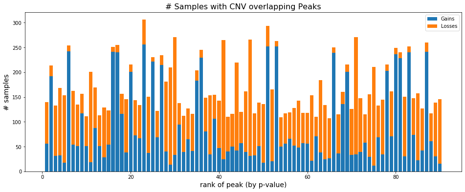

```python
from matplotlib.pyplot import figure

CRISPRiScreen_sig['rank_CRISPRi'] = CRISPRiScreen_sig['p_val'].rank(method = 'first')
CRISPRiScreen_sig.sort_values(by = 'rank_CRISPRi',inplace = True)
X = CRISPRiScreen_sig['rank_CRISPRi']
y1_allCNVs = CRISPRiScreen_sig['donorCounts_allCNVs']
y2_gains = CRISPRiScreen_sig['donorCounts_allGains']
y3_losses = CRISPRiScreen_sig['donorCounts_allLosses']
# y4_GainsAndLosses = CRISPRiScreen_sig['counts_GainsAndLosses']

# figure(figsize=(8, 6))#, dpi=80)
fig, ax = plt.subplots(figsize=(16, 6))
ax.bar(X, y2_gains, label='Gains')
ax.bar(X, y3_losses, bottom=y2_gains,label='Losses')
plt.xlabel('rank of peak (by p-value)', size = 14)
plt.ylabel('# samples', size = 14)
ax.set_title('# Samples with CNV overlapping Peaks', size = 16)
ax.legend()
plt.show()

# fig = plt.figure(figsize = (6, 6))
# ax = fig.add_axes([0,0,1,1])
# # ax.bar(X, y1_allCNVs, color='#900D09')
# # ax.bar(X, y2_gains, color='#323181')
# ax.bar(X, y3_losses, color = '#93b4f0')
# # ax.bar(X, y4_GainsAndLosses, color='black')
# ## formatting axes
# plt.xlabel('rank of peak (by p-value)', size = 15)
# plt.ylabel('# samples with CNV-Loss overlapping peak', size = 15)
# # colors = {'Gains':'#323181', 'Losses':'#93b4f0'}
# # labels = list(colors.keys())
# # handles = [plt.Rectangle((0,0),1,1, color=colors[label]) for label in labels]
# # plt.legend(handles, labels, prop={'size': 18})
# plt.show()
```

# 4.0 - PCAWG + STAAF + Nik-Zainal + MSK samples

```python
## FUNSEQ INPUT FORMAT
## 0-based, end exclusive


## 1) PCAWG Samples are GTG. Originals (hg19, all BRCA, 0-based) can be found here: /athena/khuranalab/scratch/alm2069/PaperE/Data_source/breast_cancer_data/Breast-Cancer_PCAWG_SNV.beb
## formatted can be found here: /athena/khuranalab/scratch/acp4001/P5_AOCproject/1_FunseqInput/PCAWG/TNBC
## 0 based/BED (chr1 100 101)
## FOR 31 SAMPLES
## variants: 253,654 (hg19) -> 253,640 (hg38)
## avg/sample (hg19) = 8182
## FOR 28 SAMPLES
## variants: 237,892 (hg19; 15,762 less than 31 Samples) -> 237,880 (hg38)
## avg/sample (hg19) = 8496

################################################

## 2) Get Staaf mutations here: under data availability (https://www.nature.com/articles/s41591-019-0582-4#data-availability)
# wget https://data.mendeley.com/public-files/datasets/2mn4ctdpxp/files/103b64ab-e944-4efc-8f2a-47cf61ce9df8/file_downloaded
## stored here: /athena/khuranalab/scratch/acp4001/P5_AOCproject/1_FunseqInput/staaf/TNBC/raw_TNBC_variantCalls_hg19.bed
## 1 based (chr1 100) i think;; not mentioned in paper but CaVEMan is 1-based HOWEVER it is technically a .bed file which is usually 0-based, however i think when only 1 position is given (ie chr1 100 instead of chr1 99 100) it is usually just 1 based (ie https://www.biostars.org/p/359535/) ... to convert to 0-based I did Position-1 (but just in case Position+1 is in a separate file :P;; double checked to make sure the positions are as expected and # mutations is similar in both (PositionPlus1 had 2 more mutations that liftedOver))... :)
## variants: 1,355,995 (hg19, raw) -> 1,355,927 (hg38)
## samples: 237
## avg/sample (hg19) = 5721

################################################

## 3) Get NikZainal mutations here: /home/anf2034/BRCA_WGS/BRCA_EU
## Stored here: /athena/khuranalab/scratch/acp4001/P5_AOCproject/1_FunseqInput/nikZainal/TNBC # see 4.2 for how I filtered out all BRCA for just TNBCs
## 0-based I think (confirmed-ish by Andre in Slack Chat)
# variants: 724169 (hg19, raw) -> 724097 (hg38)
# samples: 154
## avg/sample (hg19) = 4702

################################################

## 4) Get MSK mutations here (from Andrew's Email): https://mskcc.box.com/s/z8usqoghlle21b43lxod4jzbqusyjfnp
## stored here: /athena/khuranalab/scratch/acp4001/P5_AOCproject/1_FunseqInput/MSK/TNBC
## note1: Tumor_Seq_Allele2 is the actual alteration, Tumor_Seq_Allele1 is all the same as the reference allele...
## note2: 'Tumor_Seq_Allele2' column is same as 'alt' column and 'Reference_Allele' is the same as 'ref' column
## 1-based, I think (will email Andrew?? is an attending)
# variants: 279,869 (hg19, raw) -> 279,617 (hg38)
# samples: 16
## avg/sample (hg19) = 17,491


## TOTAL VARIANTS = 2,613,281
## TOTAL SAMPLES = 438
```

## 4.1 - Formatting Staaf

```python
ssh curie.pbtech
srun -n1 --pty --partition=panda --mem=50G bash -i

cd /athena/khuranalab/scratch/acp4001/P5_AOCproject/1_FunseqInput/staaf/TNBC

##### FORMATTING FOR LIFTOVER ########
python
import pandas as pd
staaf_variants_hg19 = pd.read_csv('/athena/khuranalab/scratch/acp4001/P5_AOCproject/1_FunseqInput/staaf/TNBC/raw_TNBC_variantCalls_hg19.bed', sep = '\t')

staaf_variants_hg19['Pos-1'] = staaf_variants_hg19['Pos'] - 1

## Rearrange columns
staaf_variants_hg19.columns # Then use txtformat.com to rearrange as below:
columns = ['Chrom','Pos-1','Pos','Ref','Alt','Sample','#AnalysisProc','Normal','VariantID','Qual','Filter','Gene','Transcript','RNA','CDS','Protein','Type','Effect','DP','MP','GP','TG','TP','SG','SP','DS','SNP','ASRD','CLPM','ASMD','VD','VW','GT-Norm','FAZ-Norm','FCZ-Norm','FGZ-Norm','FTZ-Norm','RAZ-Norm','RCZ-Norm','RGZ-Norm','RTZ-Norm','PM-Norm','GT-Tum','FAZ-Tum','FCZ-Tum','FGZ-Tum','FTZ-Tum','RAZ-Tum','RCZ-Tum','RGZ-Tum','RTZ-Tum','PM-Tum','FLG-DTH','FLG-RP','FLG-MN','FLG-PT','FLG-MQ','FLG-SR','FLG-CR','FLG-PH','FLG-HSD','FLG-GI','FLG-VUM','FLG-SE','FLG-MNP','1000g2015aug_all','ExAC_ALL','avsnp147']

staaf_variants_hg19 = staaf_variants_hg19[columns]

staaf_variants_hg19['Chrom'] = 'chr' + staaf_variants_hg19['Chrom'].astype(str)

staaf_variants_hg19['Sample'] = 'staaf_' + staaf_variants_hg19['Sample']


## code to make sure that the delimiter I use in "temp_allColCombined" is not in any of the columns ---> can't use "_", ';'
# for column in msk_variants.columns:
#     print(msk_variants.loc[0,column])

staaf_variants_hg19['temp_allColCombined'] = staaf_variants_hg19[columns].apply(lambda row: ';'.join(row.values.astype(str)), axis=1)

temp_staaf_variants = staaf_variants_hg19[['Chrom','Pos-1','Pos','temp_allColCombined']]


temp_staaf_variants.to_csv('temp_forLiftOver_staaf.bed', sep = '\t', header = None, index = None)

## also save staaf_variants_hg19 in a Funseq Formatted way just in case I want to run Funseq/CNCDriver in hg19 instead :)
temp_df = staaf_variants_hg19[['Chrom','Pos-1','Pos','Ref','Alt','Sample']]
temp_df.to_csv('/athena/khuranalab/scratch/acp4001/P5_AOCproject/1_FunseqInput/staaf/TNBC/TNBC_variantCalls_FunseqFormatted_hg19.bed', header = None, index = None, sep = '\t')


##### on computer #####
liftOver /Users/annpalladino/Downloads/temp_forLiftOver_staaf.bed /Users/annpalladino/Documents/athena/khuranalab/scratch/acp4001/00_raw_files/ucsc_hg19ToHg38.over.chain /Users/annpalladino/Downloads/temp_staaf_hg38.bed /Users/annpalladino/Downloads/unMapped_staaf

sed 's:;:     :g' temp_staaf_hg38.bed > temp_staaf_hg38_formatted.bed  # HAVE TO RETYPE EVERYTIME!!!! DON'T JUST COPY AND PASTE!!
# replace the ; with Tabs :).... press Control+V and then the tab char to "escape" the tab, ie: sed 's:/:<Control+V><TAB character>:g'

## move temp_staaf_hg38_formatted.bed back to folder via CyberDuck
#######################

## back on terminal
staaf_variants_hg38 = pd.read_csv('/athena/khuranalab/scratch/acp4001/P5_AOCproject/1_FunseqInput/staaf/TNBC/temp_staaf_hg38_formatted.bed', sep = '\t', header = None)
temp_list = ['CHROM','POS-1','POS']
temp_columns = temp_list + columns

staaf_variants_hg38.set_axis(temp_columns, axis = 1, inplace = True)

staaf_variants_hg38.rename(columns={'Chrom':'Chrom_hg19','Pos-1':'Pos-1_hg19', 'Pos': 'Pos_hg19'}, inplace = True)

columns = ['CHROM','POS-1','POS','Ref','Alt','Sample','Chrom_hg19','Pos-1_hg19','Pos_hg19','#AnalysisProc','Normal','VariantID','Qual','Filter','Gene','Transcript','RNA','CDS','Protein','Type','Effect','DP','MP','GP','TG','TP','SG','SP','DS','SNP','ASRD','CLPM','ASMD','VD','VW','GT-Norm','FAZ-Norm','FCZ-Norm','FGZ-Norm','FTZ-Norm','RAZ-Norm','RCZ-Norm','RGZ-Norm','RTZ-Norm','PM-Norm','GT-Tum','FAZ-Tum','FCZ-Tum','FGZ-Tum','FTZ-Tum','RAZ-Tum','RCZ-Tum','RGZ-Tum','RTZ-Tum','PM-Tum','FLG-DTH','FLG-RP','FLG-MN','FLG-PT','FLG-MQ','FLG-SR','FLG-CR','FLG-PH','FLG-HSD','FLG-GI','FLG-VUM','FLG-SE','FLG-MNP','1000g2015aug_all','ExAC_ALL','avsnp147']

staaf_variants_hg38 = staaf_variants_hg38[columns]

staaf_variants_hg38.to_csv('/athena/khuranalab/scratch/acp4001/P5_AOCproject/1_FunseqInput/staaf/TNBC/P5_4.1_TNBCvariantCalls_hg38.csv')

temp_df = staaf_variants_hg38[['CHROM','POS-1','POS','Ref','Alt','Sample']]
temp_df.to_csv('/athena/khuranalab/scratch/acp4001/P5_AOCproject/1_FunseqInput/staaf/TNBC/TNBC_variantCalls_FunseqFormatted_hg38.bed', header = None, index = None, sep = '\t')
```

## 4.2 - Formatting NikZainal

```python
## Upload 'Supplementary Table 1 CLINICAL.PATHOLOGY.DATA.FREEZE.ANALYSIS.v4.032015.csv' from Supplementary Tables of https://www.nature.com/articles/nature17676#MOESM45

ssh curie.pbtech
srun -n1 --pty --partition=panda --mem=50G bash -i

cd /athena/khuranalab/scratch/acp4001/P5_AOCproject/1_FunseqInput/nikZainal

#####  ########
python
import pandas as pd
import glob

nikZainal_metadata = pd.read_csv('/athena/khuranalab/scratch/acp4001/P5_AOCproject/1_FunseqInput/nikZainal/Supplementary Table 1 CLINICAL.PATHOLOGY.DATA.FREEZE.ANALYSIS.v4.032015.csv', header = [1]) # 560 samples

nikZainal_metadata_TNBC = nikZainal_metadata[(nikZainal_metadata['final.ER'] == 'negative') & (nikZainal_metadata['final.PR'] == 'negative') & (nikZainal_metadata['final.HER2'] == 'negative')] # 163 samples

TNBC_sampleList = nikZainal_metadata_TNBC['sample_name'].unique()
TNBC_sampleList = ['/home/anf2034/BRCA_WGS/BRCA_EU/'+ x + 'a_BRCA_EU_WGS_hg19.bed' for x in TNBC_sampleList] # len = 163

path = r'/home/anf2034/BRCA_WGS/BRCA_EU/' # use your path
all_files = glob.glob(path + "/*.bed") # len 560

temp_TNBC_files = set(TNBC_sampleList) & set(all_files) #len = 154

temp_list = []

for filename in temp_TNBC_files:
    df = pd.read_csv(filename, index_col=None, header=0, names = ['CHROM','START','END','REF','ALT','SAMPLE'], sep = '\t')
    temp_list.append(df)

nikZainal_variants_hg19 = pd.concat(temp_list, ignore_index = True)

columns = nikZainal_variants_hg19.columns

nikZainal_variants_hg19['SAMPLE'] = 'nikZainal_' + nikZainal_variants_hg19['SAMPLE']

nikZainal_variants_hg19['temp_allColCombined'] = nikZainal_variants_hg19[columns].apply(lambda row: ';'.join(row.values.astype(str)), axis=1)

temp_nikZainal_variants = nikZainal_variants_hg19[['CHROM','START','END','temp_allColCombined']]

temp_nikZainal_variants.to_csv('/athena/khuranalab/scratch/acp4001/P5_AOCproject/1_FunseqInput/nikZainal/TNBC/temp_forLiftOver_nikZainal.bed', sep = '\t', header = None, index = None)

# also save hg19 variants :)
nikZainal_variants_hg19.drop(columns=['temp_allColCombined'],inplace = True)
nikZainal_variants_hg19.to_csv('/athena/khuranalab/scratch/acp4001/P5_AOCproject/1_FunseqInput/nikZainal/TNBC/TNBC_variantCalls_FunseqFormatted_hg19.bed', header = None, index = None, sep = '\t')

##### on computer #####
liftOver /Users/annpalladino/Downloads/temp_forLiftOver_nikZainal.bed /Users/annpalladino/Documents/athena/khuranalab/scratch/acp4001/00_raw_files/ucsc_hg19ToHg38.over.chain /Users/annpalladino/Downloads/temp_nikZainal_hg38.bed /Users/annpalladino/Downloads/unMapped_nikZainal

sed 's:;:     :g' temp_nikZainal_hg38.bed > temp_nikZainal_hg38_formatted.bed # HAVE TO RETYPE EVERYTIME!!!! DON'T JUST COPY AND PASTE!!
# replace the ; with Tabs :).... press Control+V and then the tab char to "escape" the tab, ie: sed 's:/:<Control+V><TAB character>:g'

## move temp_nikZainal_hg38_formatted.bed back to folder via CyberDuck
#######################

## back on terminal
nikZainal_variants_hg38 = pd.read_csv('/athena/khuranalab/scratch/acp4001/P5_AOCproject/1_FunseqInput/nikZainal/TNBC/temp_nikZainal_hg38_formatted.bed', sep = '\t', header = None) # columns variable is from before, doesn't match up for the first 2 columns but will fix in a bit :)

columns = ['CHROM', 'START', 'END', 'Chrom_hg19','Start_hg19','End_hg19','REF', 'ALT', 'SAMPLE']

nikZainal_variants_hg38.set_axis(columns, axis = 1, inplace = True)

columns = ['CHROM', 'START', 'END', 'REF', 'ALT','SAMPLE','Chrom_hg19','Start_hg19','End_hg19']

nikZainal_variants_hg38 = nikZainal_variants_hg38[columns]

nikZainal_variants_hg38.to_csv('/athena/khuranalab/scratch/acp4001/P5_AOCproject/1_FunseqInput/nikZainal/TNBC/P5_4.2_TNBCvariantCalls_hg38.csv')

temp_df = nikZainal_variants_hg38[['CHROM', 'START', 'END', 'REF', 'ALT','SAMPLE']]
temp_df.to_csv('/athena/khuranalab/scratch/acp4001/P5_AOCproject/1_FunseqInput/nikZainal/TNBC/TNBC_variantCalls_FunseqFormatted_hg38.bed', header = None, index = None, sep = '\t')
```

## 4.3 - Formatting MSK

```python
ssh curie.pbtech
srun -n1 --pty --partition=panda --mem=50G bash -i

cd /athena/khuranalab/scratch/acp4001/P5_AOCproject/1_FunseqInput/MSK/TNBC

##### FORMATTING FOR LIFTOVER ########
python
import pandas as pd
MSK_variants_hg19 = pd.read_csv('/athena/khuranalab/scratch/acp4001/P5_AOCproject/1_FunseqInput/MSK/TNBC/raw_tnbc_hg19.maf', sep = '\t')

## Rearrange columns
MSK_variants_hg19.columns # Then use txtformat.com to rearrange as below:
columns = ['Chromosome','Start_Position','End_Position','Reference_Allele','Tumor_Seq_Allele1','Tumor_Seq_Allele2','Tumor_Sample_Barcode','Hugo_Symbol','Entrez_Gene_Id','Center','NCBI_Build','Strand','Variant_Classification','Variant_Type','dbSNP_RS','Matched_Norm_Sample_Barcode','Match_Norm_Seq_Allele1','Match_Norm_Seq_Allele2','Tumor_Validation_Allele1','Tumor_Validation_Allele2','Score','Tumor_Sample_UUID','HGVSc','HGVSp','HGVSp_Short','Transcript_ID','Exon_Number','t_depth','t_ref_count','t_alt_count','n_depth','n_ref_count','n_alt_count','all_effects','Allele','Gene','Feature','Feature_type','Consequence','STRAND_VEP','SYMBOL','SYMBOL_SOURCE','HGNC_ID','SIFT','PolyPhen','CLIN_SIG','SOMATIC','IMPACT','PICK','VARIANT_CLASS','TSL','HGVS_OFFSET','PHENO','GENE_PHENO','FILTER','flanking_bps','vcf_id','vcf_qual','vcf_pos','AF','chrom','coord','ref','alt','tri_nucleotide_context','gene_name','VAF','isabl_patient_id','isabl_sample_id','isabl_aliquot_id','qual','museq_snv_predicted','qual_strelka_snv','strelka_snv_predicted']

MSK_variants_hg19 = MSK_variants_hg19[columns]

MSK_variants_hg19['Chromosome'] = 'chr' + MSK_variants_hg19['Chromosome'].astype(str)

MSK_variants_hg19['Tumor_Sample_Barcode'] = 'MSK_' + MSK_variants_hg19['Tumor_Sample_Barcode']

MSK_variants_hg19['Start_Position'] = MSK_variants_hg19['Start_Position'] - 1 # need to do this b/c I think its 1 based and we want 0-based

MSK_variants_hg19_snpsOnly = MSK_variants_hg19[MSK_variants_hg19['Variant_Type'] == 'SNP']


# # ## code to make sure that the delimiter I use in "temp_allColCombined" is not in any of the columns ---> can't use "_", ';'
# # for column in MSK_variants_hg19.columns:
# #     print(MSK_variants_hg19.loc[0,column])

# MSK_variants_hg19['temp_allColCombined'] = MSK_variants_hg19[columns].apply(lambda row: '|'.join(row.values.astype(str)), axis=1)

# temp_MSK_variants = MSK_variants_hg19[['Chromosome','Start_Position','End_Position','temp_allColCombined']]

# temp_MSK_variants.to_csv('temp_forLiftOver_MSK.bed', sep = '\t', header = None, index = None)

## also save MSK_variants_hg19 in a Funseq Formatted way just in case I want to run Funseq/CNCDriver in hg19 instead :)
temp_df = MSK_variants_hg19_snpsOnly[['Chromosome','Start_Position','End_Position','Reference_Allele','Tumor_Seq_Allele2','Tumor_Sample_Barcode']] # note, Tumor_Seq_Allele2 is the actual alteration, Tumor_Seq_Allele1 is all the same as the reference allele, I checked by doing
# temp_df = MSK_variants_hg19[['Reference_Allele','Tumor_Seq_Allele1','Tumor_Seq_Allele2']]
# temp_allele0_list = []
# temp_allele1_list = []
# temp_allele2_list = []
# temp_allele12_list = []
# for i in temp_df.index:
#     ref = temp_df.loc[i,'Reference_Allele']
#     allele1 = temp_df.loc[i,'Tumor_Seq_Allele1']
#     allele2 = temp_df.loc[i,'Tumor_Seq_Allele2']
#     if (ref == allele1) & (ref == allele2):
#         temp_allele0_list.append(ref)
#     if (ref == allele1) & (ref != allele2):
#         temp_allele1_list.append(ref)
#     if (ref != allele1) & (ref == allele2):
#         temp_allele2_list.append(ref)
#     if (ref != allele1) & (ref != allele2):
#         temp_allele0_list.append(ref)

temp_df.to_csv('/athena/khuranalab/scratch/acp4001/P5_AOCproject/1_FunseqInput/MSK/TNBC/TNBC_variantCalls_FunseqFormatted_hg19.bed', header = None, index = None, sep = '\t')



##### on computer #####
liftOver /Users/annpalladino/Downloads/temp_forLiftOver_MSK.bed /Users/annpalladino/Documents/athena/khuranalab/scratch/acp4001/00_raw_files/ucsc_hg19ToHg38.over.chain /Users/annpalladino/Downloads/temp_MSK_hg38.bed /Users/annpalladino/Downloads/unMapped_MSK

sed 's:|:     :g' temp_MSK_hg38.bed > temp_MSK_hg38_formatted.bed  # HAVE TO RETYPE EVERYTIME!!!! DON'T JUST COPY AND PASTE!!
# replace the ; with Tabs :).... press Control+V and then the tab char to "escape" the tab, ie: sed 's:/:<Control+V><TAB character>:g'

## move temp_MSK_hg38_formatted.bed back to folder via CyberDuck
#######################

## back on terminal
MSK_variants_hg38 = pd.read_csv('/athena/khuranalab/scratch/acp4001/P5_AOCproject/1_FunseqInput/MSK/TNBC/temp_MSK_hg38_formatted.bed', sep = '\t', header = None)

## for some reason 'isabl_aliquot_id' column (which has the value 'Unspecified Aliquot' for ALL columns) gets split up into two columns, so just do quick fix
MSK_variants_hg38[72] = 'Unspecified Aliquot'
MSK_variants_hg38.drop(columns=[73], inplace = True)

temp_list = ['CHROM','POS-1','POS']
temp_columns = temp_list + columns

MSK_variants_hg38.set_axis(temp_columns, axis = 1, inplace = True)

MSK_variants_hg38.rename(columns={'Chromosome':'Chromosome_hg19','Start_Position':'Start_Position_hg19', 'End_Position': 'End_Position_hg19'}, inplace = True)

columns = ['CHROM','POS-1','POS','Reference_Allele','Tumor_Seq_Allele2','Tumor_Sample_Barcode','Chromosome_hg19','Start_Position_hg19','End_Position_hg19','Tumor_Seq_Allele1','Hugo_Symbol','Entrez_Gene_Id','Center','NCBI_Build','Strand','Variant_Classification','Variant_Type','dbSNP_RS','Matched_Norm_Sample_Barcode','Match_Norm_Seq_Allele1','Match_Norm_Seq_Allele2','Tumor_Validation_Allele1','Tumor_Validation_Allele2','Score','Tumor_Sample_UUID','HGVSc','HGVSp','HGVSp_Short','Transcript_ID','Exon_Number','t_depth','t_ref_count','t_alt_count','n_depth','n_ref_count','n_alt_count','all_effects','Allele','Gene','Feature','Feature_type','Consequence','STRAND_VEP','SYMBOL','SYMBOL_SOURCE','HGNC_ID','SIFT','PolyPhen','CLIN_SIG','SOMATIC','IMPACT','PICK','VARIANT_CLASS','TSL','HGVS_OFFSET','PHENO','GENE_PHENO','FILTER','flanking_bps','vcf_id','vcf_qual','vcf_pos','AF','chrom','coord','ref','alt','tri_nucleotide_context','gene_name','VAF','isabl_patient_id','isabl_sample_id','isabl_aliquot_id','qual','museq_snv_predicted','qual_strelka_snv','strelka_snv_predicted']

MSK_variants_hg38 = MSK_variants_hg38[columns]

MSK_variants_hg38.to_csv('/athena/khuranalab/scratch/acp4001/P5_AOCproject/1_FunseqInput/MSK/TNBC/P5_4.3_TNBCvariantCalls_hg38.csv')

temp_df = MSK_variants_hg38[['CHROM','POS-1','POS','Reference_Allele','Tumor_Seq_Allele2','Tumor_Sample_Barcode']]
temp_df.to_csv('/athena/khuranalab/scratch/acp4001/P5_AOCproject/1_FunseqInput/MSK/TNBC/TNBC_variantCalls_FunseqFormatted_hg38_all.bed', header = None, index = None, sep = '\t')

# ## Went back later and took out InDels!! got rid of the Error: "MSK_SSB11-T_IGO_08874_C_17	WARNING. chromosome (6) was not found in the FASTA file. Skipping."
# ## on cluster:
python
import pandas as pd
variants_hg38 = pd.read_csv('/athena/khuranalab/scratch/acp4001/P5_AOCproject/1_FunseqInput/MSK/TNBC/P5_4.3_TNBCvariantCalls_hg38.csv', index_col=[0])
temp_variants_hg38 = variants_hg38[variants_hg38['Variant_Type'] == 'SNP'] # 279,617 -> 209,987
temp_variants_hg38 = temp_variants_hg38[['CHROM','POS-1','POS','Reference_Allele','Tumor_Seq_Allele2','Tumor_Sample_Barcode']]
temp_variants_hg38.to_csv('/athena/khuranalab/scratch/acp4001/P5_AOCproject/1_FunseqInput/MSK/TNBC/TNBC_variantCalls_FunseqFormatted_hg38_snpsOnly.bed', header = None, index = None, sep = '\t')
```

## 4.4 - Analyzing inputs

```python
PCAWG = pd.read_csv('/athena/khuranalab/scratch/acp4001/P5_AOCproject/1_FunseqInput/PCAWG/TNBC/TNBC_variantCalls_FunseqFormatted_hg19.bed', sep = '\t', header = None)
staaf = pd.read_csv('/athena/khuranalab/scratch/acp4001/P5_AOCproject/1_FunseqInput/staaf/TNBC/TNBC_variantCalls_FunseqFormatted_hg19.bed', sep = '\t', header = None)
nikZainal = pd.read_csv('/athena/khuranalab/scratch/acp4001/P5_AOCproject/1_FunseqInput/nikZainal/TNBC/TNBC_variantCalls_FunseqFormatted_hg19.bed', sep = '\t', header = None)
MSK = pd.read_csv('/athena/khuranalab/scratch/acp4001/P5_AOCproject/1_FunseqInput/MSK/TNBC/TNBC_variantCalls_FunseqFormatted_hg19.bed', sep = '\t', header = None)

cohortDfList = [PCAWG, staaf, nikZainal, MSK]

for cohort in cohortDfList:
    print(len(cohort[5].unique()))
    valueCounts = cohort[5].value_counts().rename_axis('unique_samples').reset_index(name='counts')
    print(valueCounts)
    avgNumMut = valueCounts['counts'].mean()
    print("Avg Num Muts/sample: ", avgNumMut)

allSamples = pd.concat([PCAWG, staaf, nikZainal, MSK])
valueCounts = allSamples[5].value_counts().rename_axis('unique_samples').reset_index(name='counts')
avgNumMut = valueCounts['counts'].mean()
print("Avg Num Muts/sample: ", avgNumMut)
```

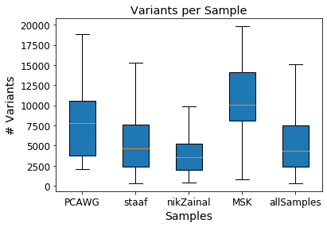

```
284
```

```
Ttest_indResult(statistic=-2.9795021037418725, pvalue=0.003048504581314401)
```

```python
# ## Run base code (above) and then this on the Cluster to get min/max/mean of # variants AND DO BOX PLOT

# boxplot_dic = {}
# for n in range(5):
#     cohortName = cohortNames[n]
#     cohortDF = cohortDFs[n]
#     print(cohortName)
#     tempdf = cohortDF[5].value_counts().rename_axis('unique_values').reset_index(name='counts')
#     boxplot_dic[cohortName] = tempdf
#     print(tempdf['counts'].min())
#     print(tempdf['counts'].max())
#     print(tempdf['counts'].mean())

# for key in boxplot_dic:
#     print(key)
#     values_count_df = boxplot_dic[key]
#     file_name = '/athena/khuranalab/scratch/acp4001/temp/'+key+'.csv'
#     print(file_name)
#     values_count_df.to_csv('/athena/khuranalab/scratch/acp4001/P5_AOCproject/1_FunseqInput/allSamples/'+key+'_valueCountsDf_forBoxPlot.csv', index = None)

#### on here :) #####

cohortNames = ['PCAWG', 'staaf', 'nikZainal', 'MSK','allSamples']
cohort_boxplotData_dic = {}

for cohort in cohortNames:
    tempdf = pd.read_csv('/Users/annpalladino/Documents/athena/khuranalab/scratch/acp4001/P5_AOCproject/1_FunseqInput/allSamples/'+cohort+'_valueCountsDf_forBoxPlot.csv')
    cohort_boxplotData_dic[cohort] = tempdf['counts'].to_list()

# print(cohort_boxplotData_dic['PCAWG'])
labels, data = [*zip(*cohort_boxplotData_dic.items())] # note: data is a Tuple

plt.boxplot(data, patch_artist=True, labels = labels, showfliers=False)
plt.rc('font', size = 12)
plt.title('Variants per Sample')
plt.xlabel('Samples', fontsize=14)
plt.ylabel('# Variants', fontsize=14)
# colors = ['pink', 'lightblue', 'lightgreen', 'white','red']
# plt.Patch(color = 'red')

plt.show()

# Test: Do MSK samples have statistically more variants/sample than the other 3 cohorts (PCAWG, Staaf, nikZainal)
MSK = data[2]
otherCohorts = data[0]
otherCohorts.extend(data[1])
otherCohorts.extend(data[3])
print(len(otherCohorts))
# print(type(data[3]))
stats.ttest_ind(MSK, otherCohorts)

# PCAWG vs other cohorts: 0.017
# staaf vs other cohorts: 0.73
# nikZainal vs other cohorts: 0.0030
### MSK vs other cohorts: 1.6 e -0.7 ###

# PCAWG vs staaf/nikZainal: .002
# staaf vs PCAWG/nikZainal: 0.38
# nikZainal vs PCAWG/staaf: .012



#### If you want to run ANOVA on cohorts
# fvalue, pvalue = stats.f_oneway(data[0],data[1],data[2],data[3], data[4])
# print(fvalue, pvalue)
```

```python
%reset -f
```

```python
for n in range(6):
    cohortName = cohortNames[n]
    cohortDF = cohortDFs[n]
    print(cohortName)
    cohortDF['chr:start'] = cohortDF[0] + ':' + cohortDF[1].astype(str)
    print(cohortDF['chr:start'].value_counts().value_counts())
    cohortDF['chr:start:sample'] = cohortDF[0] + ':' + cohortDF[1].astype(str) + ':' + cohortDF[5]
    print(cohortDF['chr:start:sample'].value_counts().value_counts())


###### ON COMPUTER (see how many CDS variants) ###
# download all variants from cyberduck (can use files here: /athena/khuranalab/scratch/acp4001/P5_AOCproject/1_FunseqInput/allSamples/TNBC

cd Downloads/

## -c flag writes all lines of -a just once and then the num of overlaps w/ -b (ie if 2 overlaps it still only writes -a once)
bedtools intersect -c -a TNBC_variantCalls_FunseqFormatted_hg38_PCAWG31SAMPLES.bed -b gencode.v36.cds.bed > temp_PCAWG.bed

bedtools intersect -c -a TNBC_variantCalls_FunseqFormatted_hg38_staaf.bed -b gencode.v36.cds.bed > temp_staaf.bed

bedtools intersect -c -a TNBC_variantCalls_FunseqFormatted_hg38_nikZainal.bed -b gencode.v36.cds.bed > temp_nikZainal.bed

bedtools intersect -c -a TNBC_variantCalls_FunseqFormatted_hg38_MSKsnpsOnly.bed -b gencode.v36.cds.bed > temp_MSKsnpsOnly.bed

# note, orig file isn't title w/ "_allSamples"
bedtools intersect -c -a TNBC_variantCalls_FunseqFormatted_hg38.bed -b gencode.v36.cds.bed > temp_allSamples.bed

bedtools intersect -c -a TNBC_variantCalls_FunseqFormatted_hg38_MSKall.bed -b gencode.v36.cds.bed > temp_MSKall.bed

##

python
import pandas as pd
PCAWG = pd.read_csv('temp_PCAWG.bed', sep = '\t', header = None)
staaf = pd.read_csv('temp_staaf.bed', sep = '\t', header = None)
nikZainal = pd.read_csv('temp_nikZainal.bed', sep = '\t', header = None)
MSK = pd.read_csv('temp_MSKsnpsOnly.bed', sep = '\t', header = None)
allSamples = pd.read_csv('temp_allSamples.bed', sep = '\t', header = None)
MSKall = pd.read_csv('temp_MSKall.bed', sep = '\t', header = None)


cohortNames = ['PCAWG', 'staaf', 'nikZainal', 'MSK','allSamples','MSKall']
cohortDFs = [PCAWG, staaf, nikZainal, MSK, allSamples, MSKall]
for n in range(6):
    cohortName = cohortNames[n]
    cohortDF = cohortDFs[n]
    print(cohortName)
    tempdf = cohortDF[cohortDF[6] == 0]
    print(tempdf.shape)
    tempdf = cohortDF[cohortDF[6] != 0]
    print(tempdf.shape)
```

```python
#### on cluster ###
## 1) make list of variants w/ chr:start to use in venn diagram

# python
# import pandas as pd
# PCAWG = pd.read_csv('/athena/khuranalab/scratch/acp4001/P5_AOCproject/1_FunseqInput/PCAWG/TNBC/TNBC_variantCalls_FunseqFormatted_hg38.bed', sep = '\t', header = None)
# staaf = pd.read_csv('/athena/khuranalab/scratch/acp4001/P5_AOCproject/1_FunseqInput/staaf/TNBC/TNBC_variantCalls_FunseqFormatted_hg38.bed', sep = '\t', header = None)
# nikZainal = pd.read_csv('/athena/khuranalab/scratch/acp4001/P5_AOCproject/1_FunseqInput/nikZainal/TNBC/TNBC_variantCalls_FunseqFormatted_hg38.bed', sep = '\t', header = None)
# MSK = pd.read_csv('/athena/khuranalab/scratch/acp4001/P5_AOCproject/1_FunseqInput/MSK/TNBC/TNBC_variantCalls_FunseqFormatted_hg38.bed', sep = '\t', header = None)

# cohortNames = ['PCAWG', 'staaf', 'nikZainal', 'MSK']
# cohortDFs = [PCAWG, staaf, nikZainal, MSK]

# for n in range(4):
#     cohortName = cohortNames[n]
#     cohortDF = cohortDFs[n]
#     cohortDF['chr:start'] = cohortDF[0] + ':' + cohortDF[1].astype(str)
#     tempList = cohortDF['chr:start'].unique()
#     print(len(tempList))
#     with open(('tempList_'+cohortName+'.txt'), 'w') as f:
#         for item in tempList:
#             f.write("%s\n" % item)

##### ON COMPUTER #####
## 2) Download onto computer using cyber duck
sampleDic = {}

tempPCAWG = pd.read_csv('/Users/annpalladino/Downloads/tempList_PCAWG.txt', header = None)
sampleDic['PCAWG'] = set(tempPCAWG[0].unique())

tempstaaf = pd.read_csv('/Users/annpalladino/Downloads/tempList_staaf.txt', header = None)
sampleDic['staaf'] = set(tempstaaf[0].unique())

tempnikZainal = pd.read_csv('/Users/annpalladino/Downloads/tempList_nikZainal.txt', header = None)
sampleDic['nikZainal'] = set(tempnikZainal[0].unique())

tempMSK = pd.read_csv('/Users/annpalladino/Downloads/tempList_MSK.txt', header = None)
sampleDic['MSK'] = set(tempMSK[0].unique())
```

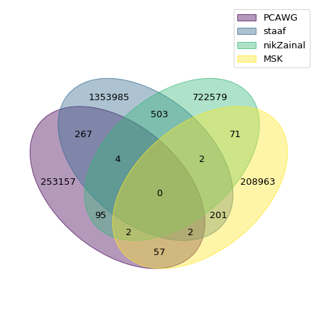

```python
from venn import venn
venn(sampleDic)
```

## 4.5 - Funseq Output Analysis

```python
## 1) Downloaded jsut the NCDS.txt files into 2_FunseqOutput
## NOTE, i accidentally deleted the allSamples Funseq output :( re-running it but for now didn't include it)

PCAWG = pd.read_csv('/Users/annpalladino/Documents/athena/khuranalab/scratch/acp4001/P5_AOCproject/2_FunseqOutput/PCAWG_TNBCtnbcTrial1Context_NCDS.txt', sep = '\t')
staaf = pd.read_csv('/Users/annpalladino/Documents/athena/khuranalab/scratch/acp4001/P5_AOCproject/2_FunseqOutput/staaf_TNBCtnbcTrial1Context_NCDS.txt', sep = '\t')
nikZainal = pd.read_csv('/Users/annpalladino/Documents/athena/khuranalab/scratch/acp4001/P5_AOCproject/2_FunseqOutput/nikZainal_TNBCtnbcTrial1Context_NCDS.txt', sep = '\t')
MSK = pd.read_csv('/Users/annpalladino/Documents/athena/khuranalab/scratch/acp4001/P5_AOCproject/2_FunseqOutput/MSK_TNBCtnbcTrial1Context_NCDS.txt', sep = '\t')
# allSamples = pd.read_csv('/Users/annpalladino/Documents/athena/khuranalab/scratch/acp4001/P5_AOCproject/2_FunseqOutput/allSamles_TNBCtnbcTrial1Context_NCDS.txt', sep = '\t')

CTCF_ctcfpprContext = pd.read_csv('/Users/annpalladino/Documents/athena/khuranalab/scratch/acp4001/P5_AOCproject/2_FunseqOutput/CTCF_BRCActcfpprTrial1Context_NCDS.txt', sep = '\t')
CTCF_brcaContext = pd.read_csv('/Users/annpalladino/Documents/athena/khuranalab/scratch/acp4001/P5_AOCproject/2_FunseqOutput/CTCF_BRCAbrcaTrial1Context_NCDS.txt', sep = '\t')

cohortNames = ['PCAWG', 'staaf', 'nikZainal', 'MSK','CTCF_ctcfpprContext','CTCF_brcaContext'] #,'allSamples']
cohortDFs = [PCAWG, staaf, nikZainal, MSK, CTCF_ctcfpprContext, CTCF_brcaContext] #, allSamples]
for n in range(6):
    cohortName = cohortNames[n]
    cohortDF = cohortDFs[n]
    print(cohortName)
    print(cohortDF.shape)
d(PCAWG)
```

```
PCAWG
(250724, 24)
staaf
(1341871, 24)
nikZainal
(716197, 24)
MSK
(207652, 24)
CTCF_ctcfpprContext
(597991, 24)
CTCF_brcaContext
(597991, 24)
```

|  | chr | posStart | posEnd | ref | alt | sampleID | CDS | VA | HUB | GNEG | GERP | UCONS | HOT | SEN | USEN | GENE | CDSS | NCDS | NCENC | MOTIFBR | MOTIFG | RECUR | DBRECUR | tumorType |
| --- | --- | --- | --- | --- | --- | --- | --- | --- | --- | --- | --- | --- | --- | --- | --- | --- | --- | --- | --- | --- | --- | --- | --- | --- |
| 0 | chr3 | 190566628 | 190566628 | G | T | 0448206f-3ade-4087-b1a9-4fb2d14e1367 | No | NaN | IL1RAP:BRCA_REG(0.727)PPI(0.695)REG(0.409)TNBC... | NaN | 3.72 | NaN | Helas3,Hepg2 | Yes | NaN | IL1RAP(Distal&Intron) | NaN | 3.37202330675671 | DHS(MCV-12\|chr3:190566555-190566705),DHS(MCV-1... | NaN | FOXD1_2#190566626#190566634#+#2#9.483#5.088,FO... | No | No | BRCA |
| 1 | chr2 | 85772641 | 85772641 | A | C | 0448206f-3ade-4087-b1a9-4fb2d14e1367 | No | NaN | ATOH8:BRCA_REG(0.983)PPI(0.236)REG(0.409)TNBC_... | NaN | 2.02 | NaN | H1hesc,Helas3,Hepg2 | Yes | NaN | ATOH8(Distal&Intron) | NaN | 3.37133043405877 | DHS(MCV-12\|chr2:85772440-85772660),DHS(MCV-13\|... | NaN | RUNX1_7#85772638#85772644#-#4#7.983#3.589,RUNX... | No | No | BRCA |

```
(250724, 24)
```

```python
temp_valueCounts_columns = ['CDS','UCONS','SEN','USEN','RECUR','DBRECUR']
temp_notNaN_columns = ['HUB','HOT','GENE','NCENC','MOTIFBR','MOTIFG']
# temp_valueCountsBinned_columns= ['GERP','NCDS'] # doesn't work b/c neither are numeric, NCDS sometimes has 2 scores i think... idk, don't have time to trouble shoot, can try again later

for n in range(6):
    cohortName = cohortNames[n]
    cohortDF = cohortDFs[n]
    print(cohortName)
#     for column in temp_valueCounts_columns:
#         print(15*'*',column,15*'*')
#         print(cohortDF[column].value_counts())
#     for column in temp_notNaN_columns:
#         print(15*'*',column,15*'*')
#         print(cohortDF[column].count()) # counts number of NON-NaN values
    tempdf = cohortDF[cohortDF['GERP'] != '.']
    tempdf = tempdf[tempdf['GERP'].astype(float) > 2]
    d(tempdf)
#     for i in cohortDF.index:
#         try:
#             float(cohortDF.loc[i,'GERP'])
#         except:
#             print(cohortDF.loc[i,'GERP'])
#     try:
#         tempdf = cohortDF[cohortDF['GERP'].astype(float) > 2]
#     except:
#         print
#     print(tempdf.shape)
```

```
PCAWG
```

|  | chr | posStart | posEnd | ref | alt | sampleID | CDS | VA | HUB | GNEG | GERP | UCONS | HOT | SEN | USEN | GENE | CDSS | NCDS | NCENC | MOTIFBR | MOTIFG | RECUR | DBRECUR | tumorType |
| --- | --- | --- | --- | --- | --- | --- | --- | --- | --- | --- | --- | --- | --- | --- | --- | --- | --- | --- | --- | --- | --- | --- | --- | --- |
| 0 | chr3 | 190566628 | 190566628 | G | T | 0448206f-3ade-4087-b1a9-4fb2d14e1367 | No | NaN | IL1RAP:BRCA_REG(0.727)PPI(0.695)REG(0.409)TNBC... | NaN | 3.72 | NaN | Helas3,Hepg2 | Yes | NaN | IL1RAP(Distal&Intron) | NaN | 3.37202330675671 | DHS(MCV-12\|chr3:190566555-190566705),DHS(MCV-1... | NaN | FOXD1_2#190566626#190566634#+#2#9.483#5.088,FO... | No | No | BRCA |
| 1 | chr2 | 85772641 | 85772641 | A | C | 0448206f-3ade-4087-b1a9-4fb2d14e1367 | No | NaN | ATOH8:BRCA_REG(0.983)PPI(0.236)REG(0.409)TNBC_... | NaN | 2.02 | NaN | H1hesc,Helas3,Hepg2 | Yes | NaN | ATOH8(Distal&Intron) | NaN | 3.37133043405877 | DHS(MCV-12\|chr2:85772440-85772660),DHS(MCV-13\|... | NaN | RUNX1_7#85772638#85772644#-#4#7.983#3.589,RUNX... | No | No | BRCA |

```
(6465, 24)
```

```
staaf
```

|  | chr | posStart | posEnd | ref | alt | sampleID | CDS | VA | HUB | GNEG | GERP | UCONS | HOT | SEN | USEN | GENE | CDSS | NCDS | NCENC | MOTIFBR | MOTIFG | RECUR | DBRECUR | tumorType |
| --- | --- | --- | --- | --- | --- | --- | --- | --- | --- | --- | --- | --- | --- | --- | --- | --- | --- | --- | --- | --- | --- | --- | --- | --- |
| 1 | chr2 | 74440811 | 74440811 | G | C | staaf_PD31028a | No | NaN | HTRA2:PPI(0.729)TNBC_REG(0.682),LBX2:REG(0.830... | NaN | 3.34 | NaN | H1hesc,Hepg2 | Yes | NaN | HTRA2(Distal),LBX2(Distal),MRPL53(Distal),RTKN... | NaN | 2.389122627:3.389122627 | DHS(MCV-11\|chr2:74440775-74440925),DHS(MCV-14\|... | NaN | NaN | Yes | No | TNBC |
| 2 | chr6 | 14477425 | 14477425 | C | A | staaf_PD31028a | No | NaN | NaN | NaN | 2.66 | NaN | K562 | Yes | NaN | NaN | NaN | 2.389122627:3.389122627 | DHS(MCV-14\|chr6:14477315-14477465),DHS(MCV-14\|... | NaN | NaN | Yes | No | TNBC |

```
(36680, 24)
```

```
nikZainal
```

|  | chr | posStart | posEnd | ref | alt | sampleID | CDS | VA | HUB | GNEG | GERP | UCONS | HOT | SEN | USEN | GENE | CDSS | NCDS | NCENC | MOTIFBR | MOTIFG | RECUR | DBRECUR | tumorType |
| --- | --- | --- | --- | --- | --- | --- | --- | --- | --- | --- | --- | --- | --- | --- | --- | --- | --- | --- | --- | --- | --- | --- | --- | --- |
| 1 | chr6 | 41427742 | 41427742 | G | C | nikZainal_PD10010a | No | NaN | FOXP4-AS1:TNBC_REG(0.811) | NaN | 4.07 | NaN | H1hesc | Yes | NaN | FOXP4-AS1(Distal) | NaN | 2.389122627:3.389122627 | DHS(MCV-10\|chr6:41427695-41427845),DHS(MCV-16\|... | NaN | NaN | Yes | No | TNBC |
| 24 | chr2 | 21633551 | 21633551 | T | C | nikZainal_PD10010a | No | NaN | NaN | NaN | 3.78 | NaN | NaN | Yes | NaN | NaN | NaN | 1.591892678:2.591892678 | DHS(MCV-1\|chr2:21633400-21633800),DHS(MCV-1\|ch... | NaN | NaN | Yes | No | TNBC |

```
(20925, 24)
```

```
MSK
```

|  | chr | posStart | posEnd | ref | alt | sampleID | CDS | VA | HUB | GNEG | GERP | UCONS | HOT | SEN | USEN | GENE | CDSS | NCDS | NCENC | MOTIFBR | MOTIFG | RECUR | DBRECUR | tumorType |
| --- | --- | --- | --- | --- | --- | --- | --- | --- | --- | --- | --- | --- | --- | --- | --- | --- | --- | --- | --- | --- | --- | --- | --- | --- |
| 0 | chr3 | 194135095 | 194135095 | C | G | MSK_SSB10-T_IGO_08874_C_15 | No | NaN | HES1:PHOS(0.717)PPI(0.781)REG(0.944)TNBC_REG(0... | NaN | 2.5 | NaN | H1hesc | Yes | NaN | HES1(Promoter) | NaN | 3.3716173310349 | DHS(MCV-13\|chr3:194134820-194135220),DHS(MCV-1... | NaN | TEAD2_1#194135092#194135099#+#3#7.627#3.312 | No | No | TNBC |
| 9 | chrX | 10833729 | 10833729 | C | G | MSK_SSB10-T_IGO_08874_C_15 | No | NaN | MID1:PPI(0.685) | NaN | 3.02 | NaN | NaN | Yes | NaN | MID1(Promoter) | NaN | 2.56703122331079 | DHS(MCV-16\|chrX:10833615-10833765),DHS(MCV-17\|... | NaN | HNF4_known11#10833727#10833733#-#5#4.893#2.009 | No | No | TNBC |

```
(4511, 24)
```

```
CTCF_ctcfpprContext
```

|  | chr | posStart | posEnd | ref | alt | sampleID | CDS | VA | HUB | GNEG | GERP | UCONS | HOT | SEN | USEN | GENE | CDSS | NCDS | NCENC | MOTIFBR | MOTIFG | RECUR | DBRECUR | tumorType |
| --- | --- | --- | --- | --- | --- | --- | --- | --- | --- | --- | --- | --- | --- | --- | --- | --- | --- | --- | --- | --- | --- | --- | --- | --- |
| 0 | chr14 | 36291506 | 36291506 | T | C | TCGA-A1-A0SM-01A | No | NaN | NaN | NaN | 2.5 | NaN | Hepg2 | Yes | NaN | NaN | NaN | 3.37064612699682 | DHS(MCV-1\|chr14:36291500-36291650),Enhancer(dr... | DHS#DMRTA1_1#36291493#36291506#+#13#0.150000#0... | NaN | No | No | BRCA |
| 2 | chr3 | 113932404 | 113932404 | A | T | TCGA-A1-A0SM-01A | No | NaN | NaN | NaN | 4.5 | NaN | Gm12878 | NaN | NaN | NaN | NaN | 2.411786697:3.411786697 | TFM(BCL11A,FOS,IRF4,JUN,MEF2A,NFKB1,SPI1,WRNIP... | BCL11A,FOS,IRF4,JUN,MEF2A,NFKB1,SPI1,WRNIP1#NK... | NaN | Yes | Yes | BRCA |

```
(47311, 24)
```

```
CTCF_brcaContext
```

|  | chr | posStart | posEnd | ref | alt | sampleID | CDS | VA | HUB | GNEG | GERP | UCONS | HOT | SEN | USEN | GENE | CDSS | NCDS | NCENC | MOTIFBR | MOTIFG | RECUR | DBRECUR | tumorType |
| --- | --- | --- | --- | --- | --- | --- | --- | --- | --- | --- | --- | --- | --- | --- | --- | --- | --- | --- | --- | --- | --- | --- | --- | --- |
| 0 | chr3 | 113932404 | 113932404 | A | T | TCGA-A1-A0SM-01A | No | NaN | NaN | NaN | 4.5 | NaN | Gm12878 | Yes | NaN | NaN | NaN | 3.380892627:4.380892627 | TFM(BCL11A,FOS,IRF4,JUN,MEF2A,NFKB1,SPI1,WRNIP... | BCL11A,FOS,IRF4,JUN,MEF2A,NFKB1,SPI1,WRNIP1#NK... | NaN | Yes | Yes | BRCA |
| 6 | chr17 | 38226655 | 38226655 | G | T | TCGA-A1-A0SM-01A | No | NaN | CSF3:BRCA_REG(0.229)PPI(0.841),MSL1:BRCA_REG(0... | NaN | 2.81 | NaN | NaN | Yes | NaN | CSF3(Distal),MSL1(Distal),THRA(Distal&Intron) | NaN | 2.583662678:3.583662678 | Enhancer(chmm/segway\|chr17:38226331-38227200),... | NR3C1,STAT3#NR3C1_known11#38226650#38226660#+#... | NaN | Yes | No | BRCA |

```
(47311, 24)
```

## 4.6 - MergedCohorts

```python
mkdir -p /athena/khuranalab/scratch/acp4001/P5_AOCproject/2_FunseqOutput/mergedCohorts/TNBC_tnbcTrial1Context_hg19

cp /athena/khuranalab/scratch/acp4001/P5_AOCproject/2_FunseqOutput/PCAWG/TNBC_tnbcTrial1Context_hg19/TNBCtnbcTrial1Context_NCDS.txt /athena/khuranalab/scratch/acp4001/P5_AOCproject/2_FunseqOutput/mergedCohorts/TNBC_tnbcTrial1Context_hg19/PCAWG_TNBCtnbcTrial1Context_NCDS.txt
cp /athena/khuranalab/scratch/acp4001/P5_AOCproject/2_FunseqOutput/staaf/TNBC_tnbcTrial1Context_hg19/TNBCtnbcTrial1Context_NCDS.txt /athena/khuranalab/scratch/acp4001/P5_AOCproject/2_FunseqOutput/mergedCohorts/TNBC_tnbcTrial1Context_hg19/staaf_TNBCtnbcTrial1Context_NCDS.txt
cp /athena/khuranalab/scratch/acp4001/P5_AOCproject/2_FunseqOutput/nikZainal/TNBC_tnbcTrial1Context_hg19/TNBCtnbcTrial1Context_NCDS.txt /athena/khuranalab/scratch/acp4001/P5_AOCproject/2_FunseqOutput/mergedCohorts/TNBC_tnbcTrial1Context_hg19/nikZainal_TNBCtnbcTrial1Context_NCDS.txt
cp /athena/khuranalab/scratch/acp4001/P5_AOCproject/2_FunseqOutput/MSK/TNBC_tnbcTrial1Context_hg19/TNBCtnbcTrial1Context_NCDS.txt /athena/khuranalab/scratch/acp4001/P5_AOCproject/2_FunseqOutput/mergedCohorts/TNBC_tnbcTrial1Context_hg19/MSK_TNBCtnbcTrial1Context_NCDS.txt


R

PCAWG_reducedFunseqOutputNCDS <- read.csv('/athena/khuranalab/scratch/acp4001/P5_AOCproject/2_FunseqOutput/mergedCohorts/TNBC_tnbcTrial1Context_hg19/PCAWG_TNBCtnbcTrial1Context_NCDS.txt', sep = '\t', row.names=NULL, na.strings="")
staaf_reducedFunseqOutputNCDS <- read.csv('/athena/khuranalab/scratch/acp4001/P5_AOCproject/2_FunseqOutput/mergedCohorts/TNBC_tnbcTrial1Context_hg19/staaf_TNBCtnbcTrial1Context_NCDS.txt', sep = '\t', row.names=NULL, na.strings="")
nikZainal_reducedFunseqOutputNCDS <- read.csv('/athena/khuranalab/scratch/acp4001/P5_AOCproject/2_FunseqOutput/mergedCohorts/TNBC_tnbcTrial1Context_hg19/nikZainal_TNBCtnbcTrial1Context_NCDS.txt', sep = '\t', row.names=NULL, na.strings="")
MSK_reducedFunseqOutputNCDS <- read.csv('/athena/khuranalab/scratch/acp4001/P5_AOCproject/2_FunseqOutput/mergedCohorts/TNBC_tnbcTrial1Context_hg19/MSK_TNBCtnbcTrial1Context_NCDS.txt', sep = '\t', row.names=NULL, na.strings="")

PCAWG_reducedFunseqOutputNCDS$tumorType <- 'BRCA'
staaf_reducedFunseqOutputNCDS$tumorType <- 'BRCA'
nikZainal_reducedFunseqOutputNCDS$tumorType <- 'BRCA'
MSK_reducedFunseqOutputNCDS$tumorType <- 'BRCA'

df1 <- rbind(PCAWG_reducedFunseqOutputNCDS, staaf_reducedFunseqOutputNCDS)
df2 <- rbind(df1, nikZainal_reducedFunseqOutputNCDS)
reducedFunseqOutputNCDS <- rbind(df2, MSK_reducedFunseqOutputNCDS)

save(reducedFunseqOutputNCDS, file = '/athena/khuranalab/scratch/acp4001/P5_AOCproject/2_FunseqOutput/mergedCohorts/TNBC_tnbcTrial1Context_hg19/reducedFunseqOutputNCDS_BRCA.Rd', version = 3.6)

# save as tsv file as well :)
write.table(reducedFunseqOutputNCDS, file="/athena/khuranalab/scratch/acp4001/P5_AOCproject/2_FunseqOutput/mergedCohorts/TNBC_tnbcTrial1Context_hg19/reducedFunseqOutputNCDS.tsv", row.names=FALSE, sep="\t")
```

# 6.0 - Funseq + CNCDriver on Nawaf samples & Eric samples (sanity check)

## 6.1 - Nawaf samples (LUAD)

```python
# # path to Funseq output: /athena/khuranalab/scratch/naa4013/alchamist_nygc/parsed_funseq2_cncdriver_filter_LUAD_upd/
# # path to CNCDriver R code:
# # Output_NCDS_upd.txt had 19,469,070 lines

# #### analysis of input ###
# ## overlap variants w/ enhancers to see how many enhancers/genes there should be ##
# ## 1) get variants bedfile for intersect
# cut -f1,2,3,6 /athena/khuranalab/scratch/naa4013/alchamist_nygc/parsed_funseq2_cncdriver_filter_LUAD_upd/Output_NCDS_upd.txt > /athena/khuranalab/scratch/acp4001/temp_variantsForIntersect.bed

# python
# import pandas as pd
# tempdf = pd.read_csv('/athena/khuranalab/scratch/acp4001/temp_variantsForIntersect.bed', sep = '\t')
# tempdf['posStart'] = tempdf['posStart'] - 1
# tempdf.sort_values(by = ['chr', 'posStart', 'posEnd'], inplace = True)
# # just did this part to reduce size of file since i have to do intersection on my computer
# tempdf['variantPos'] = tempdf['chr'] + ':' + tempdf['posStart'].astype(str)
# tempdf.drop_duplicates(subset = 'variantPos', keep = 'first', inplace = True) # 16,894,925 -> 14,583,605
# tempdf = tempdf[['chr', 'posStart', 'posEnd']]
# tempdf.to_csv('/athena/khuranalab/scratch/acp4001/temp_variantsForIntersect_formatted.bed', sep = '\t', header = None, index = None)
# ## 2) get enhancers bedfile for intersect
# # do in linux/terminal
# cut -f1,2,3,4 /athena/khuranalab/scratch/naa4013/funseq_hg38_data_context/LUAD_NAWAF_DRM_hg38.bed > /athena/khuranalab/scratch/acp4001/temp_enhancersForIntersect.bed

# ####################################
# ## Do locally
# cd Downlowads
# bedtools intersect -loj -wa -wb -a temp_variantsForIntersect_formatted.bed -b temp_enhancersForIntersect.bed > temp_enhancerVariants.bed

# ######################################
# enhancerVariants = pd.read_csv('/Users/annpalladino/Downloads/temp_enhancerVariants.bed', sep = '\t', header = None)
enhancerVariants = enhancerVariants[enhancerVariants[6] != '.']
enhancerVariants['variantID'] = enhancerVariants[0] + ':' + enhancerVariants[1].astype(str) + '-' + enhancerVariants[2].astype(str)
enhancerVariants['enhancerID'] = enhancerVariants[3] + ':' + enhancerVariants[4].astype(str) + '-' + enhancerVariants[5].astype(str)
# print('########## ENHANCER VARIANTS ##########')
d(enhancerVariants)

list1 = enhancerVariants['variantID'].unique()
list2 = enhancerVariants['enhancerID'].unique()

overlap(list1,list2)
print('# variants in enhancers: ', len(list1))
print('# unique enhancers: ', len(list2))
print('# associated genes: ', len(enhancerVariants[6].unique()))
#### there are 29,127 unique variants (by position, not nucleotide (i.e. A->T) changes) in 16,849 enhancers linked to 11,870 genes ####
```

|  | 0 | 1 | 2 | 3 | 4 | 5 | 6 | variantID | enhancerID |
| --- | --- | --- | --- | --- | --- | --- | --- | --- | --- |
| 680 | chr1 | 921238 | 921239 | chr1 | 921010 | 921510 | SAMD11 | chr1:921238-921239 | chr1:921010-921510 |
| 689 | chr1 | 933470 | 933471 | chr1 | 933008 | 933508 | SAMD11 | chr1:933470-933471 | chr1:933008-933508 |

```
(34672, 9)
```

```
len list1:  29127 ; unique:  29127
len list2:  16849 ; unique:  16849
len list1 U list2 (no repeats!):  45976
len list1 ∩ list2 :  0
# variants in enhancers:  29127
# unique enhancers:  16849
# associated genes:  11870
```

```python
## actually running CNCDriver
mkdir -p /athena/khuranalab/scratch/acp4001/P5_AOCproject/2_FunseqOutput/nawafSC/LUAD_luadTrial1Context_hg38
cp /athena/khuranalab/scratch/naa4013/alchamist_nygc/parsed_funseq2_cncdriver_filter_LUAD_upd/reducedFunseqOutputNCDS_LUAD.Rd /athena/khuranalab/scratch/acp4001/P5_AOCproject/2_FunseqOutput/nawafSC/LUAD_luadTrial1Context_hg38/

# Then did Flow: All
```

## 6.2 - Eric BRCA samples

SUMMARY

- variants in raw file (hg19, all): 638,528
- variants in hg19, snpsOnly: 603,204 (file to use for funseq hg19)
- variants in hg38, all: 638,292
- variants in hg38, snpsOnly: 602,987 (file to use for funseq hg38)

TRIALS: 1) hg19, SNPsOnly, BRCA Context, networks = BRCA_REG, PHOS, PPI 2) hg38, SNPsOnly, BRCA Context, networks = BRCA_REG, PHOS, PPI 3) hg19, SNPsOnly, OG context (ie what they may have used in paper?), networks = PHOS, PPI, REG, REG.degree_back

```python
###### FORMATTING FILES!!!! ########

## 1) get samples
mkdir -p /athena/khuranalab/scratch/acp4001/P5_AOCproject/1_FunseqInput/CTCFppr/BRCA

cp /athena/khuranalab/scratch/alm2069/DATA/WGS_SNV_data/Fredriksson_et_al_2014/Fredriksson_et_al_2014_BRCA_mutation.txt /athena/khuranalab/scratch/acp4001/P5_AOCproject/1_FunseqInput/CTCFppr/BRCA/raw_Fredriksson_et_al_2014_BRCA_mutation.txt

python
df = pd.read_csv('raw_Fredriksson_et_al_2014_BRCA_mutation.txt', sep = '\t')
df['pos-1'] = df['pos'] - 1
df['chr'] = 'chr' + df['chr'].astype(str)
tempdf = df[['chr','pos-1','pos','ref_allele','var_allele','barcode']]

tempdf = tempdf[(~tempdf['var_allele'].str.startswith('-')) & (~tempdf['var_allele'].str.startswith('+'))]
tempdf.to_csv('/athena/khuranalab/scratch/acp4001/P5_AOCproject/1_FunseqInput/CTCFppr/BRCA/BRCA_variantCalls_FunseqFormatted_hg19.bed', header = None, index = None, sep = '\t')

tempdf = df[['chr','pos-1','pos','ref_allele','var_allele','barcode','var_freq','varscan_p', 'cancer']]

columns = tempdf.columns
tempdf['temp_allColCombined'] = tempdf[columns].apply(lambda row: ';'.join(row.values.astype(str)), axis=1)
tempdf = tempdf[['chr','pos-1','pos','temp_allColCombined']]
tempdf.to_csv('temp_forLiftOver_CTCFppr.bed', sep = '\t', header = None, index = None)

########## on computer ########
liftOver /Users/annpalladino/Downloads/temp_forLiftOver_CTCFppr.bed /Users/annpalladino/Documents/athena/khuranalab/scratch/acp4001/00_raw_files/ucsc_hg19ToHg38.over.chain /Users/annpalladino/Downloads/temp_CTCFppr_hg38.bed /Users/annpalladino/Downloads/unMapped_CTCFppr
#   638,528 temp_forLiftOver_CTCFppr.bed
#   638,292 temp_CTCFppr_hg38.bed

sed 's:;:     :g' temp_CTCFppr_hg38.bed > temp_CTCFppr_hg38_formatted.bed

###################################

df_hg38 = pd.read_csv('/athena/khuranalab/scratch/acp4001/P5_AOCproject/1_FunseqInput/CTCFppr/BRCA/temp_CTCFppr_hg38_formatted.bed', sep ='\t', header = None, names = ['chr', 'pos-1', 'pos', 'chr_hg19','pos-1_hg19','pos_hg19','ref_allele', 'var_allele', 'barcode','var_freq', 'varscan_p', 'cancer'])
df_hg38.to_csv('P5_6.2_CTCFppr_hg38_formatted.csv',index = None)

# Filter out indels
tempdf = tempdf[(~tempdf['var_allele'].str.startswith('-')) & (~tempdf['var_allele'].str.startswith('+'))]
tempdf.to_csv('/athena/khuranalab/scratch/acp4001/P5_AOCproject/1_FunseqInput/CTCFppr/BRCA/BRCA_variantCalls_FunseqFormatted_hg38.bed', header = None, index = None, sep = '\t')

quit()
```

```python
cp /athena/khuranalab/scratch/acp4001/funseq2_recent_forBash/config_files/config_hg19.txt /athena/khuranalab/scratch/acp4001/P5_AOCproject/1_FunseqInput/CTCFppr/BRCA/config_brcaTrial1_hg19.txt
```

## 6.3 - Redoing Funseq w/ Erica's data context (MOTIFBR and MOTIFG troubleshooting)

```python
cp -r /athena/khuranalab/scratch/dux2001/EX_0219_christinaScreen/ .

vim /athena/khuranalab/scratch/acp4001/EX_0219_christinaScreen/funseq2_msk_all.sh # made edits that worked! was able to run Erica's samples and get both MOTIFG and MOTIFBR

cp /athena/khuranalab/scratch/acp4001/EX_0219_christinaScreen/funseq2_msk_all.sh /athena/khuranalab/scratch/acp4001/EX_0219_christinaScreen/AP_funseq2_PCAWG_all.sh

vim /athena/khuranalab/scratch/acp4001/EX_0219_christinaScreen/AP_funseq2_PCAWG_all.sh

cp /athena/khuranalab/scratch/acp4001/EX_0219_christinaScreen/AP_funseq2_PCAWG_all.sh /athena/khuranalab/scratch/acp4001/EX_0219_christinaScreen/AP_funseq2_PCAWG_all_TNBC.sh

vim /athena/khuranalab/scratch/acp4001/EX_0219_christinaScreen/AP_funseq2_PCAWG_all_TNBC.sh


cp /athena/khuranalab/scratch/acp4001/EX_0219_christinaScreen/AP_funseq2_PCAWG_all_TNBC.sh /athena/khuranalab/scratch/acp4001/EX_0219_christinaScreen/AP_funseq2.sh

vim /athena/khuranalab/scratch/acp4001/EX_0219_christinaScreen/AP_funseq2.sh




cp /athena/khuranalab/scratch/dux2001/EX_0219_christinaScreen/config.txt /athena/khuranalab/scratch/acp4001/EX_0219_christinaScreen/config.txt

vim /athena/khuranalab/scratch/acp4001/EX_0219_christinaScreen/config.txt

# Job numbers
10137147 - fixed TFM-pvalue error
10137175 - my data but still erica's config file
10137216 - my data w/ my config file (i think :P)

Next trial = fix it so it goes to the right directories, etc

trial 11 - use my code but erica's "EditBedFile" code
```

```python
# Delete!!?

cp -r /athena/khuranalab/scratch/dux2001/FunSeq2_DC-master/data_context .
cp /athena/khuranalab/scratch/dux2001/EX_0195_funseq2_TGCT/data_context_tgct/TGCT_sample_drm_gene_hg19_sub.bed .
cp /athena/khuranalab/scratch/dux2001/EX_0195_funseq2_TGCT/data_context_tgct/TGCT.regulatory.network .
```

# 7.0 - CNCDriver Output, Preliminary Analysis

- KEY
  - 1) Ac = All cancers, Bo = Brca only, To = TNBC only
  - 2) Ae = All elements, Po = Promoter only, Eo = Enhancer only
  - 3) Av = All variants (ie completeData for ourSamples), Co = Candidates only (ie candidate variants in PCAWGppr or BRCA_outputDf/DBScan clusters in ourSamples), So = Significant only

## 7.1 Comparison to PCAWG Paper

```python
##### Read in: (i) PCAWG paper calls, (ii) Promoter calls, (iii) enhancer calls

PCAWGppr_AcAeCo = pd.read_excel('/Users/annpalladino/Documents/athena/khuranalab/scratch/acp4001/P5_AOCproject/Supplement_PCAWG/SuppTables_41586_2020_1965_MOESM4_ESM.xlsx', sheet_name = 'Table 5 Non-coding point mut dr') # FROM SUPP TABLE 5 of Rheinbay paper
d(PCAWGppr_AcAeCo,1)

cohortNames = ['PCAWG','staaf','nikZainal','MSK','allSamples']

cohortdic_ToPoCo = {}
for cohort in cohortNames:
    cohortdic_ToPoCo[cohort] = pd.read_csv(('/Users/annpalladino/Documents/athena/khuranalab/scratch/acp4001/P5_AOCproject/3_CNCDriverOutput/'+cohort+'/TNBC_tnbcTrial1aContext_hg38/output_result_triMut_match/promoter_cluster/BRCA/RT_0.2/BRCA_outputDf_promoter_cluster_allSamples_minPoints_2_dRadius_50_with_RT_correction_similarity_0.2_triMut_match_distribution_task_0_iter_10000_.txt'), sep = '\t')
d(cohortdic_ToPoCo['PCAWG'])

cohortdic_ToEoCo = {}
for cohort in cohortNames:
    cohortdic_ToEoCo[cohort] = pd.read_csv(('/Users/annpalladino/Documents/athena/khuranalab/scratch/acp4001/P5_AOCproject/3_CNCDriverOutput/'+cohort+'/TNBC_tnbcTrial1aContext_hg38/output_result_triMut_match/enhancerUnit_cluster/BRCA/RT_0.2/BRCA_outputDf_enhancerUnit_cluster_allSamples_minPoints_2_dRadius_50_with_RT_correction_similarity_0.2_triMut_match_distribution_task_0_iter_10000_.txt'), sep = '\t')
d(cohortdic_ToEoCo['PCAWG'])
```

|  | ID | target | tissue | gene | Brown_observed | max_method_contr | max_method_id | Pre-filter q-value | Post-filter q-value | Mutations | Patients mutated | Mappability | AID | UV | APOBEC | Palindrome | More than two mutations | More than two patients mutated | Manual review | Overlap | Final filter judgement | Expression_p-value | Expression_Fold Difference | Mutated patients w. expression data | Wild-type patients with expression data |
| --- | --- | --- | --- | --- | --- | --- | --- | --- | --- | --- | --- | --- | --- | --- | --- | --- | --- | --- | --- | --- | --- | --- | --- | --- | --- |
| 0 | gc19_pc.promCore::gencode::CHMP4B::ENSG0000010... | promCore | meta_Adenocarcinoma | CHMP4B | 0.000194 | 0.37327 | Fisher_observed | 0.41395 | 1.0 | 8 | 8 | True | True | True | True | True | True | True | True | True | True | 0.702076 | 1.216133 | 4.0 | 765.0 |

```
(1208, 25)
```

|  | elementPos | numOfAlterationPos | numOfAlteration | numOfPatient | compositeDriverScore | numOfAboveCDscore | reSampleNum | pValue | qValue |
| --- | --- | --- | --- | --- | --- | --- | --- | --- | --- |
| 0 | GPI | 3 | 3 | 2 | 6.281908 | 0 | 34220 | 0.000029 | 0.001724 |
| 1 | SPC24 | 2 | 2 | 1 | 4.515476 | 0 | 903 | 0.001106 | 0.032633 |

```
(59, 9)
```

|  | enhancerUnitPos | numOfAlteredElements | elementPos | numOfAlterationPos | numOfAlteration | numOfPatient | compositeDriverScore | numOfAboveCDscore | reSampleNum | pValue | qValue |
| --- | --- | --- | --- | --- | --- | --- | --- | --- | --- | --- | --- |
| 0 | chr2:39736557-39737056 | 1 | THUMPD2 | 2 | 2 | 2 | 2.920897 | 0 | 28 | 0.034483 | 0.396694 |
| 1 | chr1:25425546-25426045 | 1 | TMEM50A | 2 | 2 | 1 | 4.515572 | 5 | 120 | 0.049587 | 0.396694 |

```
(16, 11)
```

```python
# LOOKING AT DISTRIBUTION OF MUTATIONS (i.e. )
# temp_BRCA = SuppTable5[SuppTable5['tissue'].str.contains('Breast')]
# d(temp_BRCA)
# temp_valueCounts = temp_BRCA[['target', 'tissue', 'Manual review', 'Final filter judgement']]
# col(temp_valueCounts, value_counts = True)
```

```python
PCAWGppr_AcAeCo_geneList = PCAWGppr_AcAeCo['gene']
allOurs_ToAeCo_geneList = []
allOurs_ToAeSo_geneList = []
for key in cohortdic_ToPoCo:
#     print(key)
    df = cohortdic_ToPoCo[key]
    allOurs_ToAeCo_geneList.extend(df['elementPos'])
    df1 = df[df['qValue'] < 0.1]
    allOurs_ToAeSo_geneList.extend(df1['elementPos'])
for key in cohortdic_ToEoCo:
    df = cohortdic_ToEoCo[key]
    allOurs_ToAeCo_geneList.extend(df['elementPos'])
    df1 = df[df['qValue'] < 0.1]
    allOurs_ToAeSo_geneList.extend(df1['elementPos'])

########################################
## allOurGenes ∩ allPCAWG genes
PCAWGppr_allOurs_AcAeCo_overlappedGenes = overlap(allOurs_ToAeCo_geneList, PCAWGppr_AcAeCo_geneList, Print = True, Make = True)

########################################
# allOurGenes ∩ BRCAPCAWGgenes
PCAWGppr_BoAeCo = PCAWGppr_AcAeCo[PCAWGppr_AcAeCo['tissue'].str.contains('Breast')]
PCAWGppr_BoAeCo_geneList = PCAWGppr_BoAeCo['gene']
overlap(allOurs_ToAeCo_geneList, PCAWGppr_BoAeCo_geneList, Print = True)

########################################
# OurSigGenes ∩ BRCAPCAWGgenes
overlap(allOurs_ToAeSo_geneList, PCAWGppr_BoAeCo_geneList)

########################################
# allOurGenes ∩ significant BRCAPCAWGgenes
PCAWGppr_BoAeSo_geneList = ['BPIFB2', 'HOXB5', 'BPIFB2', 'HOXB5', 'VSTM2L', 'PCF11', 'PCF11', 'PRDX2', 'RMRP', 'RMRP']
overlap(allOurs_ToAeCo_geneList,PCAWGppr_BoAeSo_geneList, Print = True)
```

```
len list1:  5957 ; unique:  3595
len list2:  1208 ; unique:  646
len list1 U list2 (no repeats!):  4175
len list1 ∩ list2 :  66
{'AKR1B10', 'RPL8', 'MYBL1', 'ARPC5L', 'ICAM1', 'HIST1H2AE', 'ALG10', 'ZNF575', 'TRMT10C', 'GPI', 'MAP2', 'NKX2-3', 'TBC1D12', 'CISD3', 'CCL20', 'EIF3H', 'SGK1', 'MORC1', 'PSMD11', 'MED31', 'POLDIP3', 'TSR1', 'EMG1', 'SAP30', 'ENPP2', 'NOL7', 'ZFPL1', 'KATNB1', 'FEM1A', 'A4GNT', 'LCK', 'CHST13', 'HE…
len list1:  5957 ; unique:  3595
len list2:  33 ; unique:  18
len list1 U list2 (no repeats!):  3610
len list1 ∩ list2 :  3
{'PLEKHS1', 'BPIFB2', 'TBC1D12'}
len list1:  21 ; unique:  19
len list2:  33 ; unique:  18
len list1 U list2 (no repeats!):  37
len list1 ∩ list2 :  0
len list1:  5957 ; unique:  3595
len list2:  10 ; unique:  6
len list1 U list2 (no repeats!):  3600
len list1 ∩ list2 :  1
{'BPIFB2'}
```

# 8.0 - Funseq + CNCDriver Trial 2b (rerun TNBCs using CTCF context and enhancerElement not enhancerUnit

```python
## 1) did all cohorts thru Funseq using CTCF context
## 2) Made mergedCohort to run thru CNCDriver enhancerELEMENT!! see 4.0 --> merged cohorts for code (just replace Trial1 with Trial2)
## 3) Ended up running through CNCDriver locally & manually in R studio b/c there were some things that changed in enhancerELEMENT code including: 1) need to put in "param, hg19/38" (done on my GitHub account), 2) signalTiming is messed up; 3) remember to use a nonspecific enhancerRegionBedFile instead of the TNBC one
##     3b) link to code that has param hg19/38 update: https://github.com/apalladino6/CNCDriver/blob/master/R/getEnhancerElementPvalue_cluster_v2.R

##### RUNNING CNCDRIVER ###
ssh curie.pbtech

sbatch /athena/khuranalab/scratch/acp4001/P5_AOCproject/3_CNCDriverOutput/mergedCohorts/TNBC_tnbcTrial2bContext_hg19/BashForEnhancerElement.sh

mv /athena/khuranalab/scratch/acp4001/slurmOutput/slurm-EnhancerElement-${jobID}.out /athena/khuranalab/scratch/acp4001/P5_AOCproject/3_CNCDriverOutput/mergedCohorts/TNBC_tnbcTrial2bContext_hg19/slurm-EnhancerElement-${jobID}.out


10201602
```

# 9.0 - Funseq + CNCDriver Trial 3a (rerun w/ superEnhancers; still enhancerUnit)

## 9.1 - look at super enhancers and how they overlap w/ Erica's peak-gene links

```python
# ## Get super enhancer peaks from here:
# # https://www.nature.com/articles/s41467-021-22445-0 --> Supplementary Data 2 --> upload to cluster as /athena/khuranalab/scratch/acp4001/P5_AOCproject/dataFromLit/raw_Huang_superEnhToGene_41467_2021_22445_MOESM4_ESM.xlsx

# ## Overlap Erica's peaks w/ HuangSuperEnh:
# ## on cluster
# python
# import pandas as pd
# superEnh = pd.read_excel('/athena/khuranalab/scratch/acp4001/P5_AOCproject/dataFromLit/raw_Huang_superEnhToGene_41467_2021_22445_MOESM4_ESM.xlsx', header = [1])
# duxPeaks = pd.read_csv('/athena/khuranalab/scratch/acp4001/funseq_hg19_data_context/TNBC_sample_drm.gene_hg19.bed', sep = '\t', header = None) # these are just the peaks w/ links present in 1+ TNBC sample

# duxPeaks['EnhName'] = duxPeaks[0] + ':' + duxPeaks[1].astype(str)

# temp_superEnh = superEnh[['SE chromosome', 'SE start', 'SE end', 'SE name']]
# temp_duxPeaks = duxPeaks[[0,1,2,'EnhName']]
# temp_duxPeaks.drop_duplicates(subset = ['EnhName'], inplace = True) # 44,471 -> 35,453

# temp_superEnh.to_csv('/athena/khuranalab/scratch/acp4001/temp_superEnh.bed', sep = '\t', header = False, index = False)

# temp_duxPeaks.to_csv('/athena/khuranalab/scratch/acp4001/temp_duxPeaks.bed', sep = '\t', header = False, index = False)

# # ## do locally
# # bedtools intersect -wa -wb -a /Users/annpalladino/Downloads/temp_superEnh.bed -b /Users/annpalladino/Downloads/temp_duxPeaks.bed > /Users/annpalladino/Downloads/temp_superEnhDuxPeakIntersect.bed

# temp_superEnhDuxPeakIntersect = pd.read_csv('/athena/khuranalab/scratch/acp4001/temp_superEnhDuxPeakIntersect.bed', sep = '\t', header = None, names = ['superEnh_chr', 'superEnh_posStart','superEnh_posEnd','superEnh_name','dux_chr','dux_posStart','dux_posEnd','dux_name'])
# # 64 rows of overlap

# ## see num of unique peaks for each cohort
# len(temp_superEnhDuxPeakIntersect['superEnh_name'].unique()) # Num SuperEnh peaks = 50
# len(temp_superEnhDuxPeakIntersect['dux_name'].unique()) # num dux peaks = 64

# ## see overlap btwn the genes
# def overlap(list1,list2, Print = False, Make = False):
#     set1 = set(list1)
#     set2 = set(list2)
#     print('len list1: ',len(list1),'; unique: ',len(set1))
#     print('len list2: ',len(list2),'; unique: ',len(set2))
#     print('len list1 ∩ list2 : ', len(set1 & set2))
#     if Print == True:
#         print(set(list1) & set(list2))
#     if Make == True:
#         return(list(set(list1) & set(list2)))


# superEnhGenes = list(superEnh['gene name'])
# duxGenes = list(duxPeaks[3])

# geneOverlapList = overlap(superEnhGenes, duxGenes, Make = True)
# # superEnh = 331 links, 331 unique genes
# # dux = 44471 links, 16710 unique genes
# # overlap of genes: 315 genes overlap


# # See genes included in superEnh and not ours: ['UGP2', 'SCHIP1', 'CEP170', 'TTYH1', 'WIF1', 'GLS', 'SPC25', 'CENPI', 'EPHB6', 'POP1', 'PTPRK', 'RSU1', 'FAM20C', 'NUF2', 'EGFL6', 'PABPC1']
# superEnhOnlyGenes = [x for x in superEnhGenes if x not in geneOverlapList]

# # see length of SuperEnhancers
# superEnh['length'] = superEnh['SE end'] - superEnh['SE start']
# superEnh.to_csv('/athena/khuranalab/scratch/acp4001/temp_superEnh.csv', index = False)
```

|  | SE chromosome | SE start | SE end | SE name | log2 fold enrichment (SE) | P (SE) | BH-adjusted P (SE) | SE-gene distance (bp) | gene chr | gene start | gene end | gene strand | gene name | log2 fold chage (gene expression) | P (gene expression) | BH-adjusted P (gene expression) | length |
| --- | --- | --- | --- | --- | --- | --- | --- | --- | --- | --- | --- | --- | --- | --- | --- | --- | --- |
| 0 | chr5 | 66548000 | 66572600 | SSE1 | 6.402 | 0.000839 | 0.010255 | 67684 | chr5 | 66492617 | 66478104 | - | CD180 | 0.59 | 3.729459e-11 | 1.516873e-10 | 24600 |
| 1 | chr7 | 23057600 | 23063000 | SSE2 | 6.385 | 0.000217 | 0.010095 | 6531 | chr7 | 23053770 | 22980878 | - | FAM126A | 0.69 | 2.815688e-15 | 1.628656e-14 | 5400 |

```
(331, 17)
```

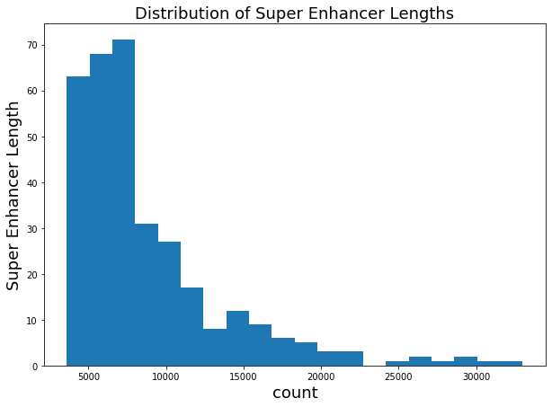

```python
%run ~/Documents/Important/modules.ipynb
import pandas as pd
import matplotlib
from matplotlib import pyplot as plt

superEnh = pd.read_csv('/Users/annpalladino/Downloads/temp_superEnh.csv')
d(superEnh)

fig, ax = plt.subplots(figsize =(10, 7))
ax.hist(superEnh['length'], bins = 20)
plt.xlabel("count", fontsize=18)
plt.ylabel("Super Enhancer Length", fontsize=18)
plt.title('Distribution of Super Enhancer Lengths', fontsize=18)
```

## 9.2 - add superEnh positions to TNBC_sample_drm.gene_hg19.bed

```python
## add superEnh positions to "Enhancer-Gene Pairs" in funseq2 (the TNBC_sample_drm.gene_hg19.bed)
superEnh = pd.read_excel('/athena/khuranalab/scratch/acp4001/P5_AOCproject/dataFromLit/raw_Huang_superEnhToGene_41467_2021_22445_MOESM4_ESM.xlsx', header = [1])
duxPeaks = pd.read_csv('/athena/khuranalab/scratch/acp4001/funseq_hg19_data_context/TNBC_sample_drm.gene_hg19.bed', sep = '\t', header = None) # these are just the peaks w/ links present in 1+ TNBC sample

temp_superEnh = superEnh[['SE chromosome', 'SE start', 'SE end','gene name']]
temp_superEnh.columns = [0,1,2,3]
temp_duxPeaks = duxPeaks[[0,1,2,3]]

TNBC_withSuperEnh_drm = pd.concat([temp_duxPeaks,temp_superEnh]) # 44471 -> 44802 rows

TNBC_withSuperEnh_drm.to_csv('/athena/khuranalab/scratch/acp4001/funseq_hg19_data_context/TNBC_withSuperEnh_drm.gene_hg19.bed', sep = '\t', header = False, index = False)

## rerun Funseq w/ new file, set as Trial 3



########################################################
########################################################
# REMEMBER TO CHANGE CNCDRIVER TO INCLUDE SUPERENHANCERS AS WELL!!!!
########################################################
########################################################
```

# FILES/FLOW

```python
##### COPY AND PASTE; THEN SAVE AS A .txt file called
temp_${cohort}_${cancer}_${CNCDriverContext}_${build}.txt

#######################################
########## FUNSEQ FLOW ###############

###### FORMATTING FILES ###########
### 0) Use tnbcTrial# as funseqContext (i.e. ${funseqContext} = tnbcTrial1)
### 1) !!! KEEP cohort, cancer, funseqContext CASE CONSISTENT (ie don't do Pcawg vs PCAWG vs pcawg, stick with one; usually: COHORT or cohort, CANCER, contextTrial#)
### 2) 'BRCA' is hardcoded in following scripts and must be changed if not running BRCA samples:
###### 2a) Line 11 of /athena/khuranalab/scratch/acp4001/readLoadRds_forBash.R
###### 2b) Line ~84 of /athena/khuranalab/scratch/acp4001/CNCDriver_data_hg38/CNCDriver_hg38.R (i.e. "cancer_info<-cancer_info[cancer_info$histologyName %in% 'BRCA',]")

## 1) variants should be titled:
/athena/khuranalab/scratch/acp4001/P5_AOCproject/1_FunseqInput/${cohort}/${cancer}/${cancer}_variantCalls_FunseqFormatted_${build}.bed
## can make by doing
df.to_csv('/athena/khuranalab/scratch/acp4001/P5_AOCproject/1_FunseqInput/${cohort}/${cancer}/${cancer}_variantCalls_FunseqFormatted_${build}.bed', header = None, index = None, sep = '\t')

variants.head()
## chr1	11583	11584	G	C	sampleName # No periods in the sampleName, ie .TCGA-19-2620-01A.filter
## chr1	11952	11953	G	T	sampleName

## 2) config file is titled:
/athena/khuranalab/scratch/acp4001/funseq2_recent_forBash/config_${funseqContext}_${build}.txt

## can make it by doing:
cp /athena/khuranalab/scratch/acp4001/funseq2_recent_forBash/config_files/config_${build}.txt /athena/khuranalab/scratch/acp4001/funseq2_recent_forBash/config_files/config_${funseqContext}_${build}.txt
## then edit w/:
vim /athena/khuranalab/scratch/acp4001/funseq2_recent_forBash/config_files/config_${funseqContext}_${build}.txt


## 3) Make sure you have all necessary funseqContext files AND MAKE SURE YOU DELETE NETWORKS
## 3a) Funseq2 Context files that you need:
funseq_${build}_data_context/${cancer}.regulatory.network
funseq_${build}_data_context/${cancer}_sample_drm.gene_hg38.bed
funseq_${build}_data_context/sensitive_${cancer}_hg38.bed
funseq_${build}_data_context/networks_${cancer}/${cancer}_REG.degree
## 3b) CNCDriver files that you need
CNCDriver_data_${build}/enhancerBedfile_${cancer}_sample_drm.gene_${build}.bed # just do cp /athena/khuranalab/scratch/acp4001/funseq_${build}_data_context/${cancer}_sample_drm.gene_${build}.bed CNCDriver_data_${build}/enhancerBedfile_${cancer}_sample_drm.gene_${build}.bed

####### USE ############
USE:
ssh curie.pbtech
acp
sbatch P5_codeB2_funseq_flow.sh ${cohort} ${cancer} ${funseqContext} ${build}

## EXAMPLES
sbatch P5_codeB2_funseq_flow_trial1.sh PCAWG TNBC tnbcTrial1 hg38

##### RECORD JOB NUMBER!!!!! #######
# sbatch P5_codeB2_funseq_flow.sh ${cohort} ${cancer} ${funseqContext} ${build}
mv /athena/khuranalab/scratch/acp4001/slurmOutput/slurm-funseq2_duxScript-${jobID}.out /athena/khuranalab/scratch/acp4001/P5_AOCproject/2_FunseqOutput/${cohort}/${cancer}_${funseqContext}Context_${build}/slurm-funseq2_duxScript-${jobID}.out

#######################################
########## CNCDRIVER FLOW ###############


### 0) IF YOU'VE RUN CNCDRIVER ON THESE SAMPLES BEFORE, DELETE ANY INTERMEDIATE FILES in the INPUT directory!! ie CNCDriver puts out intermediate files that it makes in the input folder, if you don't delete these it won't make new ones it'll just use the old files

### 1) Use tnbcTrial## as CNCDriverContext; ie tnbcTrial1a (where "1" refers to the funseq trial number, and "a" is changed w/ each new attempt)

## 2) Make sure funseq output/CNCDriver input is ok. should be in format:
# funseqDirOut=/athena/khuranalab/scratch/acp4001/P5_AOCproject/2_FunseqOutput/${cohort}/${cancer}_${funseqContext}Context_${build}
# filename = reducedFunseqOutputNCDS_BRCA.Rd
# check by doing
cd /athena/khuranalab/scratch/acp4001/P5_AOCproject/2_FunseqOutput/${cohort}/${cancer}_${funseqContext}Context_${build}
##### this will be done by P5_codeB2_funseq_flow.sh

## 2) make CNCDriver output directory and copy the .R file to be used
mkdir -p /athena/khuranalab/scratch/acp4001/P5_AOCproject/3_CNCDriverOutput/${cohort}/${cancer}_${CNCDriverContext}Context_${build}

cp /athena/khuranalab/scratch/acp4001/CNCDriver_data_${build}/CNCDriver_${build}.R /athena/khuranalab/scratch/acp4001/P5_AOCproject/3_CNCDriverOutput/${cohort}/${cancer}_${CNCDriverContext}Context_${build}/CNCDriver_${CNCDriverContext}_${build}.R

vim /athena/khuranalab/scratch/acp4001/P5_AOCproject/3_CNCDriverOutput/${cohort}/${cancer}_${CNCDriverContext}Context_${build}/CNCDriver_${CNCDriverContext}_${build}.R

ssh curie.pbtech
acp
sbatch P5_codeB3_CNCDriver_flow.sh ${cohort} ${cancer} ${funseqContext} ${CNCDriverContext} ${build}

#EXAMPLE: sbatch P5_codeB3_CNCDriver_flow.sh PCAWG TNBC tnbcTrial1a hg38

##### RECORD JOB NUMBER!!!!! #######
# sbatch P5_codeB3_CNCDriver_flow.sh ${cohort} ${cancer} ${funseqContext} ${CNCDriverContext} ${build}
mv /athena/khuranalab/scratch/acp4001/slurmOutput/slurm-P5_codeB3_CNCDriver_flow-${jobID}.out /athena/khuranalab/scratch/acp4001/P5_AOCproject/3_CNCDriverOutput/${cohort}/${cancer}_${CNCDriverContext}Context_${build}/slurm-P5_codeB3_CNCDriver_flow-${jobID}.out
# to move the intermediate files that CNCDriver makes in the input file directory
mkdir /athena/khuranalab/scratch/acp4001/P5_AOCproject/2_FunseqOutput/${cohort}/${cancer}_${funseqContext}Context_${build}/old_${CNCDriverContext}
mv /athena/khuranalab/scratch/acp4001/P5_AOCproject/2_FunseqOutput/${cohort}/${cancer}_${funseqContext}Context_${build}/*cluster /athena/khuranalab/scratch/acp4001/P5_AOCproject/2_FunseqOutput/${cohort}/${cancer}_${funseqContext}Context_${build}/old_${CNCDriverContext}

#######################################
########## ANALYSIS FLOW ###############

## 1) Calculate Lambda value;
##
ssh curie.pbtech
srun -n1 --pty --partition=panda --mem=50G bash -i
acp

R

BRCA_outputDf_promoter<-read.delim('/athena/khuranalab/scratch/acp4001/P5_AOCproject/3_CNCDriverOutput/${cohort}/${cancer}_${CNCDriverContext}Context_${build}/output_result_triMut_match/promoter_cluster/BRCA/RT_0.2/BRCA_outputDf_promoter_cluster_allSamples_minPoints_2_dRadius_50_with_RT_correction_similarity_0.2_triMut_match_distribution_task_0_iter_10000_.txt', header = TRUE, sep = '\t') # analysis of genes can be found in Summary stats

BRCA_outputDf_enhancer<-read.delim('/athena/khuranalab/scratch/acp4001/P5_AOCproject/3_CNCDriverOutput/${cohort}/${cancer}_${CNCDriverContext}Context_${build}/output_result_triMut_match/enhancerUnit_cluster/BRCA/RT_0.2/BRCA_outputDf_enhancerUnit_cluster_allSamples_minPoints_2_dRadius_50_with_RT_correction_similarity_0.2_triMut_match_distribution_task_0_iter_10000_.txt', header = TRUE, sep = '\t')

BRCA_outputDf_lincRNA<-read.delim('/athena/khuranalab/scratch/acp4001/P5_AOCproject/3_CNCDriverOutput/${cohort}/${cancer}_${CNCDriverContext}Context_${build}/output_result_triMut_match/lincRNA_cluster/BRCA/RT_0.2/BRCA_outputDf_lincRNA_cluster_allSamples_minPoints_2_dRadius_50_with_RT_correction_similarity_0.2_triMut_match_distribution_task_0_iter_10000_.txt', header = TRUE, sep = '\t')

## 1) Calculate Lambda Value, ie the estimate of the slope given by permPvector
pvector<-BRCA_outputDf_promoter$pValue
pvector<-BRCA_outputDf_enhancer$pValue
pvector<-BRCA_outputDf_lincRNA$pValue

observedPvector<-sort(pvector,decreasing=F)
permPvector<-1:length(observedPvector)/length(observedPvector)
myLambda <- summary(lm(observedPvector ~ 0 + permPvector))$coeff[1,1]


quit()
###########################
######### MY COMPUTER, PYTHON #########

## 2) Compare against ${cohort}/Liu results
LiuPromoterDrivers = pd.read_excel('/Users/annpalladino/Documents/khuranalab/P5_AOCproject/CTCF_CNCDriverPaperSupplement/TableS5_Promoters_1-s2.0-S2405471219301176-mmc6.xlsx', 'BRCA')
${cancer}PromoterDrivers = pd.read_csv('/Users/annpalladino/Documents/khuranalab/P5_AOCproject/3_CNCDriverOutput/${cohort}/${cancer}_${CNCDriverContext}Context_${build}/output_result_triMut_match/promoter_cluster/BRCA/RT_0.2/BRCA_outputDf_promoter_cluster_allSamples_minPoints_2_dRadius_50_with_RT_correction_similarity_0.2_triMut_match_distribution_task_0_iter_10000_.txt', sep = '\t')
LiuEnhancerDrivers = pd.read_excel('/Users/annpalladino/Documents/khuranalab/P5_AOCproject/CTCF_CNCDriverPaperSupplement/TableS6_Enhancers_1-s2.0-S2405471219301176-mmc7.xlsx', 'BRCA')
${cancer}EnhancerDrivers = pd.read_csv('/Users/annpalladino/Documents/khuranalab/P5_AOCproject/3_CNCDriverOutput/${cohort}/${cancer}_${CNCDriverContext}Context_${build}/output_result_triMut_match/enhancerUnit_cluster/BRCA/RT_0.2/BRCA_outputDf_enhancerUnit_cluster_allSamples_minPoints_2_dRadius_50_with_RT_correction_similarity_0.2_triMut_match_distribution_task_0_iter_10000_.txt', sep = '\t')

d(LiuPromoterDrivers)
d(${cancer}PromoterDrivers)
d(LiuEnhancerDrivers)
d(${cancer}EnhancerDrivers)


# ## Gene overlap for Promoters
list1 = LiuPromoterDrivers['geneSymbol']
list2 = TNBCPromoterDrivers['elementPos']
overlap(list1,list2, Make = True)

## Gene overlap for Enhnacers
temp_TNBCForIntersect = TNBCEnhancerDrivers[['enhancerUnitPos']]
temp_TNBCForIntersect['chr'], temp_TNBCForIntersect['coord'] = temp_TNBCForIntersect['enhancerUnitPos'].str.split(':').str
temp_TNBCForIntersect['start'], temp_TNBCForIntersect['stop'] = temp_TNBCForIntersect['coord'].str.split('-').str
temp_TNBCForIntersect = temp_TNBCForIntersect[['chr','start','stop','enhancerUnitPos']]

d(temp_TNBCForIntersect)

temp_TNBCForIntersect.to_csv('/Users/annpalladino/Documents/khuranalab/temp_TNBCForIntersect.bed', header = None, index = None, sep ='\t')

# ## on terminal
# bedtools intersect -wa -wb -a /Users/annpalladino/Documents/khuranalab/P5_AOCproject/CTCF_CNCDriverPaperSupplement/liuForIntersect_hg38.bed -b /Users/annpalladino/Documents/khuranalab/temp_TNBCForIntersect.bed
```

```python
## SCRAP CODE

# read in all variants, for promoters
cohortdic_ToPoAv = {}
for cohort in cohortNames:
    cohortdic_ToPoAv[cohort] = pd.read_csv(('/athena/khuranalab/scratch/acp4001/P5_AOCproject/3_CNCDriverOutput/' + cohort + '/TNBC_tnbcTrial1aContext_hg19/dataDetailed/promoter_cluster/completeData/BRCA_promoter_cluster_completeData_merge_variant_details.txt'), sep = '\t')
# cohortdic_ToPoAv['allSamples']['sampleID'] = 'allSamples_' + cohortdic_ToPoAv['allSamples']['sampleID'].astype(str)
# d(cohortdic_ToPoAv['allSamples'])



cohortNames = ['PCAWG','staaf','nikZainal','MSK','mergedCohorts']

cohortdic_ToEoAv = {}
for cohort in cohortNames:
    cohortdic_ToEoAv[cohort] = pd.read_csv(('/athena/khuranalab/scratch/acp4001/P5_AOCproject/3_CNCDriverOutput/' + cohort + '/TNBC_tnbcTrial1aContext_hg19/dataDetailed/enhancerUnit_cluster/completeData/BRCA_enhancerUnit_cluster_completeData_merge_variant_details.txt'), sep = '\t')
# cohortdic_ToEoAv['mergedCohorts']['sampleID'] = 'allSamples_' + cohortdic_ToEoAv['mergedCohorts']['sampleID'].astype(str)
# d(cohortdic_ToEoAv['mergedCohorts'])


##### PROMOTERS #######

allOurs_geneList_ToPoSo = ['GPI', 'SPC24', 'NFIB', 'GRAMD1B', 'HES1', 'SLC30A9', 'C19orf44', 'MASTL', 'NMT1', 'MAST4', 'DUSP22', 'POLDIP3', 'TBC1D10C', 'MDC1', 'PXT1', 'TNFSF18', 'AP3M2', 'SSUH2', 'TRIB1', 'WDR74']

columns = cohortdic_ToPoAv['PCAWG'].columns
cohortsMergedDf_ToPoSo = pd.DataFrame(columns = columns)

for cohort in cohortdic_ToPoAv:
    tempdf = cohortdic_ToPoAv[cohort]
    for gene in allOurs_geneList_ToPoSo:
        tempdf_ToPoSo = tempdf[tempdf['GENEparsed'].str.contains(gene)]
        cohortsMergedDf_ToPoSo = cohortsMergedDf_ToPoSo.append(tempdf_ToPoSo, ignore_index=True)

d(cohortsMergedDf_ToPoSo)

# #############################################
# ##### ENHANCERS #######
allOurs_geneList_ToEoSo = ['CEBPB']

columns = cohortdic_ToEoAv['PCAWG'].columns
cohortsMergedDf_ToEoSo = pd.DataFrame(columns = columns)

for cohort in cohortdic_ToEoAv:
    tempdf = cohortdic_ToEoAv[cohort]
    for gene in allOurs_geneList_ToEoSo:
        tempdf_ToEoSo = tempdf[tempdf['GENEparsed'].str.contains(gene)]
        cohortsMergedDf_ToEoSo = cohortsMergedDf_ToEoSo.append(tempdf_ToEoSo, ignore_index=True)

d(cohortsMergedDf_ToEoSo)
tempdf = cohortsMergedDf_ToPoSo[(cohortsMergedDf_ToPoSo['GENEparsed'].str.contains('TRIB1')) &(cohortsMergedDf_ToPoSo['sampleID'].str.startswith('allSamples_'))]
tempdf.sort_values(['posStart'], inplace = True)
# d(tempdf,20)
# print(len(tempdf['sampleID'].unique()))
# print(tempdf['sampleID'].unique())
# print(tempdf['HUB'].value_counts())
# # print(tempdf[tempdf['GERP'].astype(int) > 2].shape)
# print('number of HOT: ', tempdf[~tempdf['HOT'].isnull()].shape)
# print(tempdf['SEN'].value_counts())
# print(tempdf['MOTIFG'].value_counts())
# print(tempdf['elementName'].value_counts())

## For UCSC plotting
tempdf['posStart'] = tempdf['posStart']-1
tempdf = tempdf[['chr', 'posStart','posEnd','sampleID']]
tempdf['sampleID'] = tempdf['sampleID'].str[11:]
d(tempdf)
tempdf.to_csv('/Users/annpalladino/Documents/athena/khuranalab/scratch/acp4001/P5_AOCproject/3_CNCDriverOutput/forUCSC_TRIB1_hg38.bed', sep = '\t', index = None)



    for col in colForUnique:
        if col not in sigGenesAllSamples_df.columns:
            sigGenesAllSamples_df[col] = ''
        elif:
            sigGenesAllSamples_df.loc[gene,col] = len(tempdf[col].unique())



## ON TERMINAL
ssh curie.pbtech
srun -n1 --pty --partition=panda --mem=50G bash -i
python
import pandas as pd

list_ToPoSo = ['TRIB1', 'WDR74', 'NFIB', 'TBC1D10C', 'GRAMD1B', 'HES1', 'MASTL', 'BCAR3', 'BDNF', 'CCDC107', 'CMC1', 'CSMD3', 'GSTA4', 'HEY1', 'LBTB20', 'NFIA', 'SRRM4', 'TMEM215']

mergedCohorts_ToPoAv = pd.read_csv('/athena/khuranalab/scratch/acp4001/P5_AOCproject/3_CNCDriverOutput/mergedCohorts/TNBC_tnbcTrial1aContext_hg19/dataDetailed/promoter_cluster/completeData/BRCA_promoter_cluster_completeData_merge_variant_details.txt', sep = '\t')

dic_ToPoSo = {}
for gene in list_ToPoSo:
    tempdf = mergedCohorts_ToPoAv[mergedCohorts_ToPoAv['GENEparsed'] == gene]
    dic_ToPoSo[gene] = list(tempdf['posStart'])

## IN R

library(trackViewer)
SNP <- c(126440135, 126440806, 126441995, 126442210, 126442430, 126442435, 126442831, 126444315, 126444330, 126445145)
sample.gr <- GRanges("chr8", IRanges(SNP, width=1, names=paste0("snp", SNP)))
features <- GRanges("chr8", IRanges(c(1, 501, 1001),
                                    width=c(120, 400, 405),
                                    names=paste0("block", 1:3)))
lolliplot(sample.gr, features)

# 126440135, 126440806, 126441995, 126442210, 126442430, 126442435, 126442831, 126444315, 126444330, 126445145
```